# Travaglio et al., medRxiv 2020 (v04)

Yizhou Yu, MRC Toxicology Unit, University of Cambridge, (yzy21@mrc-tox.cam.ac.uk)

26/04/2020

# General information

This is a data analysis pipeline linked to a manuscript deposited in medRxiv titled **Links between air pollution and COVID-19 in England** (link: https://www.medrxiv.org/content/10.1101/2020.04.16.20067405v2). This pipeline relates to data included in **Figure 3** to **Figure 5** of the manuscript as well as Supplementary tables included in the supplementary materials.

The input files for this analysis pipeline are on the master branch of this GitHub page (link: https://github.com/M1gus/AirPollutionCOVID19)

The main aims of the workflow presented here were as follows:  
1. Determine a relationship between air pollutants and COVID-19-associated deaths/cases in England  
2. Investigate whether any relationship between air pollution and COVID-19 remains significant in the presence of counfounding factors at the regional and subregional level  
3. Determine the effect of air pollutants on infectivity at individual levels.  
4. Determine the main contributors of air pollution at the subregional level.

Only the UK Biobank data is not available in the repository as they require separate application. Please visit ukbiobank.ac.uk for more information. A detailed list of the variables used in the UK Biobank analysis is available here:

#### Supplementary Table 1. Variables from the UK Biobank.

```r
library(knitr)
kable(read.csv("data_v4/suppl_table_1.csv"))
```

[output not shown]

*These variables contained too few data and were excluded from analysis.  
The detailed information for every variable can be retrieved by searching for the UK Biobank ID at ukbiobank.ac.uk.

## Aim 1: Preliminary analysis

Deaths/cases ~ air pollutants + population  
Then, Model comparisons

### Load packages

```r
library(MASS)
library(stargazer)
library(ggplot2)
library(dplyr)
library(tidyverse)
library(purrr)
library(AER)
library(reshape)
library(rgdal) # for spTransform, requires sudo apt install libgdal-dev
require(stringr)
library(sp)
library(sf)
library(rnaturalearth)
library(rnaturalearthdata)
library(rgeos)
```

Please note:  
the following packages may need to be installed: liblapack-dev  
liblapack3  
libopenblas-base  
libopenblas-dev  
texlive-fonts-recommended  
lmodern  
can be done with apt-get on ubuntu

### View the data

Read and verify the data:

```r
preL_dt = read.csv("data_v4/26-4-2020_yyAIR_COVID_PRE_LD_dt.csv")[,-1]
head(preL_dt)
```

```
##                     Region cases_preL deaths_preL Date_cases
## 1          East Of England       5356         746         NA
## 2                   London      16913        2120         NA
## 3                 Midlands      10501        1491         NA
## 4 North East And Yorkshire       8004         893         NA
## 5               North West       9394         847         NA
## 6               South East       8547         783         NA
##   Population_size_2018 Average_Pop_density_personkm2 Cases Deaths NO.levels
## 1              6201214                         324.0  6499   1448  9.502135
## 2              8908081                        5666.0 19511   3522 25.193133
## 3             10704906                         380.5 14844   2684 14.529437
## 4              8137524                         333.0 10633   1641 16.501209
## 5              7292093                         517.0 12093   1801  8.581661
## 6              9133625                         479.0 10919   1430 10.646127
##   NO2.levels O3.levels
## 1   19.55372  54.36748
## 2   38.51252  36.91391
## 3   24.11985  47.69889
## 4   25.15139  45.29534
## 5   20.06274  48.95081
## 6   20.47013  52.30382
```

Quickly visualise the distribution of each variable:

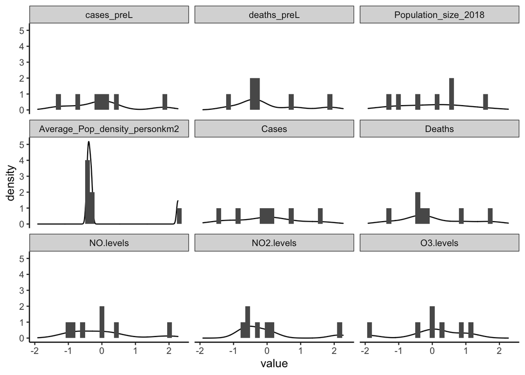

```r
require (reshape)
#normalise per column & reshape the data for plotting
preL_dt_scale = as.data.frame(sapply(preL_dt[,-c(1,4)], scale))
preL_dt_scale$Region = preL_dt$Region
preL_dt_long = melt(preL_dt_scale, in.vars = "Region")

ggplot(preL_dt_long, aes (value)) +
    geom_density() +
  geom_histogram() +
    facet_wrap(~variable) +
  theme_bw() +
  theme(panel.border = element_blank(), panel.grid.major = element_blank(),
panel.grid.minor = element_blank(), axis.line = element_line(colour = "black"))
```

### Models

#### Analyse the death data:

```r
summary(full_lm <- lm(data = preL_dt, deaths_preL ~ Average_Pop_density_personkm2 + NO.levels + NO2.levels + O3.levels))
```

```
##
## Call:
## lm(formula = deaths_preL ~ Average_Pop_density_personkm2 + NO.levels +
##     NO2.levels + O3.levels, data = preL_dt)
##
## Residuals:
##        1        2        3        4        5        6        7
## -101.701   -1.428  192.949 -187.616  -13.232   44.475   66.554
##
## Coefficients:
##                                 Estimate Std. Error t value Pr(>|t|)
## (Intercept)                   -1.235e+04  4.844e+03  -2.549   0.1256
## Average_Pop_density_personkm2 -6.310e-01  2.544e-01  -2.480   0.1313
## NO.levels                     -3.326e+02  1.124e+02  -2.958   0.0978 .
## NO2.levels                     6.015e+02  1.782e+02   3.375   0.0777 .
## O3.levels                      8.824e+01  5.409e+01   1.631   0.2444
## ---
## Signif. codes:  0 '***' 0.001 '**' 0.01 '*' 0.05 '.' 0.1 ' ' 1
##
## Residual standard error: 211.4 on 2 degrees of freedom
## Multiple R-squared:  0.956,  Adjusted R-squared:  0.8681
## F-statistic: 10.87 on 4 and 2 DF,  p-value: 0.08599
```

The model is overdispersed - use negative binomial or poisson regressions.  
The poisson and Negative Binomial models work better with count data. Changing these will not affect the OLS results.

```r
preL_dt$NO.levels = round(preL_dt$NO.levels * 1000)
preL_dt$NO2.levels = round(preL_dt$NO2.levels * 1000)
preL_dt$O3.levels = round(preL_dt$O3.levels * 1000)
preL_dt$Average_Pop_density_personkm2 = round(preL_dt$Average_Pop_density_personkm2)
```

It is important to ensure that they are integers:

```r
preL_dt_int = as.data.frame(sapply(preL_dt[,2:ncol(preL_dt)], as.integer))
preL_dt_int$Region = preL_dt$Region
preL_dt_int
```

```
##   cases_preL deaths_preL Date_cases Population_size_2018
## 1       5356         746         NA              6201214
## 2      16913        2120         NA              8908081
## 3      10501        1491         NA             10704906
## 4       8004         893         NA              8137524
## 5       9394         847         NA              7292093
## 6       8547         783         NA              9133625
## 7       2898         368         NA              5599735
##   Average_Pop_density_personkm2 Cases Deaths NO.levels NO2.levels O3.levels
## 1                           324  6499   1448      9502      19554     54367
## 2                          5666 19511   3522     25193      38513     36914
## 3                           380 14844   2684     14529      24120     47699
## 4                           333 10633   1641     16501      25151     45295
## 5                           517 12093   1801      8582      20063     48951
## 6                           479 10919   1430     10646      20470     52304
## 7                           235  3913    608     14047      21991     48054
##                     Region
## 1          East Of England
## 2                   London
## 3                 Midlands
## 4 North East And Yorkshire
## 5               North West
## 6               South East
## 7               South West
```

```r
### Number of death
summary(full_lm.nb <- glm.nb(data = preL_dt_int, deaths_preL ~ Average_Pop_density_personkm2 + NO.levels + NO2.levels + O3.levels))
```

```
##
## Call:
## glm.nb(formula = deaths_preL ~ Average_Pop_density_personkm2 +
##     NO.levels + NO2.levels + O3.levels, data = preL_dt_int, init.theta = 196.4212515,
##     link = log)
##
## Deviance Residuals:
##        1         2         3         4         5         6         7
## -1.50927  -0.04204   1.13015  -1.12365  -0.18404   1.44286   0.13514
##
## Coefficients:
##                                 Estimate Std. Error z value Pr(>|z|)
## (Intercept)                   -1.090e+01  1.890e+00  -5.767 8.07e-09 ***
## Average_Pop_density_personkm2 -9.331e-04  9.829e-05  -9.494  < 2e-16 ***
## NO.levels                     -4.728e-04  4.487e-05 -10.539  < 2e-16 ***
## NO2.levels                     8.135e-04  7.086e-05  11.482  < 2e-16 ***
## O3.levels                      1.200e-04  2.068e-05   5.802 6.56e-09 ***
## ---
## Signif. codes:  0 '***' 0.001 '**' 0.01 '*' 0.05 '.' 0.1 ' ' 1
##
## (Dispersion parameter for Negative Binomial(196.4213) family taken to be 1)
##
##     Null deviance: 294.5029  on 6  degrees of freedom
## Residual deviance:   6.9535  on 2  degrees of freedom
## AIC: 91.745
##
## Number of Fisher Scoring iterations: 1
##
##
##               Theta:  196
##           Std. Err.:  129
##
##  2 x log-likelihood:  -79.745
```

```r
summary(full_lm.p <- glm(data = preL_dt_int, deaths_preL ~ Average_Pop_density_personkm2 + NO.levels + NO2.levels + O3.levels, family = "poisson"))
```

```
##
## Call:
## glm(formula = deaths_preL ~ Average_Pop_density_personkm2 + NO.levels +
##     NO2.levels + O3.levels, family = "poisson", data = preL_dt_int)
##
## Deviance Residuals:
##       1        2        3        4        5        6        7
## -3.4193  -0.0597   2.5243  -2.8870  -0.4216   3.3526   0.8474
##
## Coefficients:
##                                 Estimate Std. Error z value Pr(>|z|)
## (Intercept)                   -1.159e+01  9.091e-01  -12.75   <2e-16 ***
## Average_Pop_density_personkm2 -9.771e-04  4.570e-05  -21.38   <2e-16 ***
## NO.levels                     -4.916e-04  2.301e-05  -21.36   <2e-16 ***
## NO2.levels                     8.457e-04  3.571e-05   23.68   <2e-16 ***
## O3.levels                      1.247e-04  9.462e-06   13.18   <2e-16 ***
## ---
## Signif. codes:  0 '***' 0.001 '**' 0.01 '*' 0.05 '.' 0.1 ' ' 1
##
## (Dispersion parameter for poisson family taken to be 1)
##
##     Null deviance: 1833.017  on 6  degrees of freedom
## Residual deviance:   38.539  on 2  degrees of freedom
## AIC: 109.09
##
## Number of Fisher Scoring iterations: 4
```

```r
#pchisq(2 * (logLik(full_lm.nb) - logLik(full_lm.p)), df = 1, lower.tail = FALSE)
#(est <- cbind(Estimate = coef(full_lm.nb), confint(full_lm.nb)))
```

#### Analyse the Cases data:

```r
summary(cases_lm <- lm(data = preL_dt, cases_preL ~ Average_Pop_density_personkm2 + NO.levels + NO2.levels + O3.levels))
```

```
##
## Call:
## lm(formula = cases_preL ~ Average_Pop_density_personkm2 + NO.levels +
##     NO2.levels + O3.levels, data = preL_dt)
##
## Residuals:
##        1        2        3        4        5        6        7
## -1610.04   -62.57   495.92  -375.69  -200.13  2067.35  -314.85
##
## Coefficients:
##                                 Estimate Std. Error t value Pr(>|t|)
## (Intercept)                   -5.887e+04  4.405e+04  -1.337    0.313
## Average_Pop_density_personkm2 -3.805e+00  2.313e+00  -1.645    0.242
## NO.levels                     -2.778e+00  1.022e+00  -2.717    0.113
## NO2.levels                     4.118e+00  1.620e+00   2.541    0.126
## O3.levels                      2.380e-01  4.921e-01   0.484    0.676
##
## Residual standard error: 1923 on 2 degrees of freedom
## Multiple R-squared:  0.9365, Adjusted R-squared:  0.8095
## F-statistic: 7.373 on 4 and 2 DF,  p-value: 0.123
```

```r
summary(cases_lm.nb <- glm.nb(data = preL_dt_int, cases_preL ~ Average_Pop_density_personkm2 + NO.levels + NO2.levels + O3.levels))
```

```
##
## Call:
## glm.nb(formula = cases_preL ~ Average_Pop_density_personkm2 +
##     NO.levels + NO2.levels + O3.levels, data = preL_dt_int, init.theta = 33.53196858,
##     link = log)
##
## Deviance Residuals:
##        1         2         3         4         5         6         7
## -1.62262  -0.06666  -0.12959   0.24412  -0.18307   1.97477  -0.62489
##
## Coefficients:
##                                 Estimate Std. Error z value Pr(>|z|)
## (Intercept)                   -4.451e+00  3.968e+00  -1.122 0.261994
## Average_Pop_density_personkm2 -7.942e-04  2.084e-04  -3.811 0.000138 ***
## NO.levels                     -4.916e-04  9.215e-05  -5.334 9.60e-08 ***
## NO2.levels                     7.404e-04  1.461e-04   5.069 4.01e-07 ***
## O3.levels                      6.958e-05  4.430e-05   1.570 0.116300
## ---
## Signif. codes:  0 '***' 0.001 '**' 0.01 '*' 0.05 '.' 0.1 ' ' 1
##
## (Dispersion parameter for Negative Binomial(33.532) family taken to be 1)
##
##     Null deviance: 55.8888  on 6  degrees of freedom
## Residual deviance:  7.0375  on 2  degrees of freedom
## AIC: 132.87
##
## Number of Fisher Scoring iterations: 1
##
##
##               Theta:  33.5
##           Std. Err.:  17.9
##
##  2 x log-likelihood:  -120.868
```

```r
summary(cases_lm.p <- glm(data = preL_dt_int, cases_preL ~ Average_Pop_density_personkm2 + NO.levels + NO2.levels + O3.levels, family = "poisson"))
```

```
##
## Call:
## glm(formula = cases_preL ~ Average_Pop_density_personkm2 + NO.levels +
##     NO2.levels + O3.levels, family = "poisson", data = preL_dt_int)
##
## Deviance Residuals:
##        1         2         3         4         5         6         7
## -20.3835   -0.5511   -0.2285    1.7246   -2.0609   28.5914  -10.4853
##
## Coefficients:
##                                 Estimate Std. Error z value Pr(>|z|)
## (Intercept)                   -2.934e+00  3.006e-01  -9.761   <2e-16 ***
## Average_Pop_density_personkm2 -7.301e-04  1.543e-05 -47.324   <2e-16 ***
## NO.levels                     -4.524e-04  7.507e-06 -60.273   <2e-16 ***
## NO2.levels                     6.787e-04  1.186e-05  57.231   <2e-16 ***
## O3.levels                      5.611e-05  3.104e-06  18.080   <2e-16 ***
## ---
## Signif. codes:  0 '***' 0.001 '**' 0.01 '*' 0.05 '.' 0.1 ' ' 1
##
## (Dispersion parameter for poisson family taken to be 1)
##
##     Null deviance: 13239.2  on 6  degrees of freedom
## Residual deviance:  1350.5  on 2  degrees of freedom
## AIC: 1436.1
##
## Number of Fisher Scoring iterations: 4
```

##### Supplementary Table 2. Effect of air pollutants on COVID-19 cases in England at the regional level.

Cases data: table

```r
stargazer(cases_lm.p, cases_lm.nb,type="html",
          dep.var.labels="Number of cases until 8 April 2020",
          ci=TRUE, ci.level=0.95, single.row=TRUE)
```

|  | *Dependent variable:* |  |
| --- | --- | --- |
|  | Number of cases until 8 April 2020 |  |
|  | *Poisson* | *negative* |
|  |  | *binomial* |
|  | (1) | (2) |
| Average_Pop_density_personkm2 | -0.001*** (-0.001, -0.001) | -0.001*** (-0.001, -0.0004) |
| NO.levels | -0.0005*** (-0.0005, -0.0004) | -0.0005*** (-0.001, -0.0003) |
| NO2.levels | 0.001*** (0.001, 0.001) | 0.001*** (0.0005, 0.001) |
| O3.levels | 0.0001*** (0.0001, 0.0001) | 0.0001 (-0.00002, 0.0002) |
| Constant | -2.934*** (-3.523, -2.345) | -4.451 (-12.229, 3.327) |
| Observations | 7 | 7 |
| Log Likelihood | -713.041 | -61.434 |
| theta |  | 33.532* (17.929) |
| Akaike Inf. Crit. | 1,436.081 | 132.868 |
| *Note:* | p<0.1; p<0.05; p<0.01 |  |

*: p<0.1; **: p<0.05; ***: p<0.01  
Each column of the table corresponds to a different type of regression model as indicated at the top. The raw estimate values of each model are listed with their 95% confidence intervals in parentheses. The p-values are indicated using the number of asterisks beside the estimates. OLS, ordinary least square; Average_Pop_densitykm2, average population density per square kilometer; NO.levels, nitrogen oxide levels; NO2.levels, nitrogen dioxide levels; O3.levels, ozone levels; Akaike Inf. Crit., Akaike’s Information Criteria; Residual Std. Error, Residual standard error.

##### Supplementary Table 3. Effect of air pollutants on COVID-19 deaths in England at the regional level.

```r
stargazer(full_lm.p, full_lm.nb,type="html",
          dep.var.labels="Number of deaths until 8 April 2020",
          ci=TRUE, ci.level=0.95, single.row=TRUE)
```

|  | *Dependent variable:* |  |
| --- | --- | --- |
|  | Number of deaths until 8 April 2020 |  |
|  | *Poisson* | *negative* |
|  |  | *binomial* |
|  | (1) | (2) |
| Average_Pop_density_personkm2 | -0.001*** (-0.001, -0.001) | -0.001*** (-0.001, -0.001) |
| NO.levels | -0.0005*** (-0.001, -0.0004) | -0.0005*** (-0.001, -0.0004) |
| NO2.levels | 0.001*** (0.001, 0.001) | 0.001*** (0.001, 0.001) |
| O3.levels | 0.0001*** (0.0001, 0.0001) | 0.0001*** (0.0001, 0.0002) |
| Constant | -11.590*** (-13.372, -9.809) | -10.900*** (-14.604, -7.195) |
| Observations | 7 | 7 |
| Log Likelihood | -49.547 | -40.873 |
| theta |  | 196.421 (128.791) |
| Akaike Inf. Crit. | 109.094 | 91.745 |
| *Note:* | p<0.1; p<0.05; p<0.01 |  |

*: p<0.1; **: p<0.05; ***: p<0.01  
Each column of the table corresponds to a different type of regression model as indicated at the top. The raw estimate values of each model are listed with their 95% confidence intervals in parentheses. The p-values are indicated using the number of asterisks beside the estimates. OLS, ordinary least square; Average_Pop_densitykm2, average population density per square kilometer; NO.levels, nitrogen oxide levels; NO2.levels, nitrogen dioxide levels; O3.levels, ozone levels; Akaike Inf. Crit., Akaike’s Information Criteria; Residual Std. Error, Residual standard error.

## Aim 2: subregional level analysis

### Deaths data

#### Data curation

```r
pop_dens = read.csv("data_v4/2018_official_popDensity.csv")[c("Code","X2018.people.per.sq..km")]
earnings =read.csv("data_v4/ann_earning_2018_perLA.csv")[c("Code","Mean_ann_earnings")]
age = read.csv("data_v4/processed_median_age_of_population_perLA.csv")[c("Code","median_age_2018","Name")]
covid_deaths = read.csv("data_v4/covid_deaths_until10April_byAreaCode.csv")

covid_deaths$total_deaths = covid_deaths$Home + covid_deaths$Hospital + covid_deaths$Care.home + covid_deaths$Hospice + covid_deaths$Other.communal.establishment + covid_deaths$Elsewhere

covid_deaths = covid_deaths[c("Area.code","total_deaths")]
colnames(covid_deaths) <- c("Code","deaths")

nrow(pop_dens)
```

```
## [1] 435
```

```r
nrow(earnings)
```

```
## [1] 422
```

```r
nrow(age)
```

```
## [1] 433
```

```r
nrow(covid_deaths)
```

```
## [1] 346
```

```r
#merge data
merged_covid_dt_LA = merge(covid_deaths, pop_dens, by = "Code")
merged_covid_dt_LA = merge(merged_covid_dt_LA, earnings, by = "Code")
merged_covid_dt_LA = merge(merged_covid_dt_LA, age, by = "Code")
nrow(merged_covid_dt_LA)
```

```
## [1] 334
```

**Now, we will use a python script (in the form of a Jupyter Notebook) to match air pollution data to local authorities.**  
#### Analysis  
##### Data visualisation for model selection  
Load data and set correct formats

```r
# load data
colnames(merged_covid_dt_LA)
```

```
## [1] "Code"                    "deaths"
## [3] "X2018.people.per.sq..km" "Mean_ann_earnings"
## [5] "median_age_2018"         "Name"
```

```r
merged_covid_dt_LA$X2018.people.per.sq..km = as.numeric(gsub(",","",merged_covid_dt_LA$X2018.people.per.sq..km))
merged_covid_dt_LA$Mean_ann_earnings = as.numeric(gsub(",","",merged_covid_dt_LA$Mean_ann_earnings))

write.csv(merged_covid_dt_LA, "data_output_v4/merged_covid_cov_dt_LA.csv")
```

re-read here

```r
covid_air_dt = read.csv("data_output_v4/merged_covidAir_cov_dt_LA.csv", na.strings = "x")
covid_air_dt$X2018.people.per.sq..km = as.numeric(gsub(",","",covid_air_dt$X2018.people.per.sq..km))
covid_air_dt$Mean_ann_earnings = as.numeric(gsub(",","",covid_air_dt$Mean_ann_earnings))
covid_air_dt$X2018.people.per.sq..km = as.numeric(covid_air_dt$X2018.people.per.sq..km)
covid_air_dt$Mean_ann_earnings = as.numeric(covid_air_dt$Mean_ann_earnings)
```

Make sure that only England data is included

```r
covid_air_dt = covid_air_dt[startsWith(as.character(covid_air_dt$Code), 'E'),]
nrow(covid_air_dt)
```

```
## [1] 312
```

Visualise all numeric data

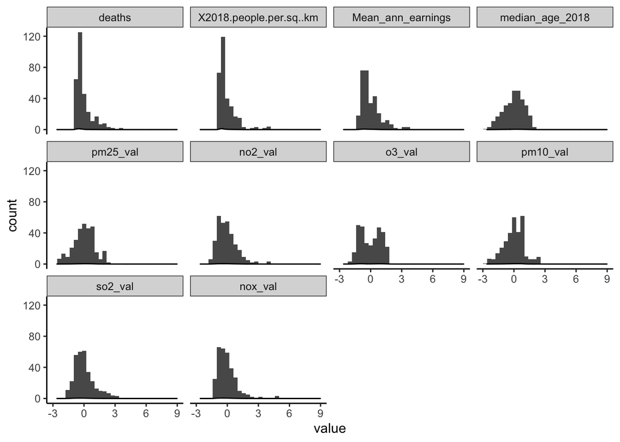

```r
covid_air_dt_vis = subset(covid_air_dt, select=c(deaths, X2018.people.per.sq..km, Mean_ann_earnings,median_age_2018,pm25_val,no2_val,o3_val,
                                                 pm10_val,so2_val, nox_val))
covid_air_dt_vis = as.data.frame(sapply(covid_air_dt_vis, function(x) as.numeric(x) ) )
#normalise per column & reshape the data for plotting
covid_air_dt_vis = as.data.frame(sapply(covid_air_dt_vis, scale))

covid_air_dt_vis$Code = covid_air_dt$Code
covid_air_dt_vis_long = melt(covid_air_dt_vis, in.vars = "Code")
ggplot(covid_air_dt_vis_long, aes (value)) +
  geom_histogram() +
  geom_density() +
  facet_wrap(~variable) +
  theme_bw() +
  theme(panel.border = element_blank(), panel.grid.major = element_blank(),
panel.grid.minor = element_blank(), axis.line = element_line(colour = "black"))
```

##### Models

Negative binomial regression model

```r
summary(pm25_deaths.nb <- glm.nb(data = covid_air_dt, deaths ~ X2018.people.per.sq..km +
                                   Mean_ann_earnings + median_age_2018 + pm25_val))
```

```
##
## Call:
## glm.nb(formula = deaths ~ X2018.people.per.sq..km + Mean_ann_earnings +
##     median_age_2018 + pm25_val, data = covid_air_dt, init.theta = 2.099197434,
##     link = log)
##
## Deviance Residuals:
##     Min       1Q   Median       3Q      Max
## -3.4419  -0.8381  -0.3209   0.2889   3.2137
##
## Coefficients:
##                           Estimate Std. Error z value Pr(>|z|)
## (Intercept)              6.988e+00  6.351e-01  11.002  < 2e-16 ***
## X2018.people.per.sq..km  1.040e-04  2.232e-05   4.661 3.15e-06 ***
## Mean_ann_earnings        4.670e-06  6.535e-06   0.715    0.475
## median_age_2018         -7.862e-02  1.188e-02  -6.618 3.64e-11 ***
## pm25_val                -3.892e-02  3.146e-02  -1.237    0.216
## ---
## Signif. codes:  0 '***' 0.001 '**' 0.01 '*' 0.05 '.' 0.1 ' ' 1
##
## (Dispersion parameter for Negative Binomial(2.0992) family taken to be 1)
##
##     Null deviance: 528.24  on 305  degrees of freedom
## Residual deviance: 328.09  on 301  degrees of freedom
##   (6 observations deleted due to missingness)
## AIC: 2801.1
##
## Number of Fisher Scoring iterations: 1
##
##
##               Theta:  2.099
##           Std. Err.:  0.171
##
##  2 x log-likelihood:  -2789.130
```

```r
car::vif(pm25_deaths.nb)
```

```
## X2018.people.per.sq..km       Mean_ann_earnings         median_age_2018
##                2.080989                1.441089                2.135625
##                pm25_val
##                1.950479
```

```r
summary(pm10_deaths.nb <- glm.nb(data = covid_air_dt, deaths ~ X2018.people.per.sq..km +
                                   Mean_ann_earnings + median_age_2018 + pm10_val))
```

```
##
## Call:
## glm.nb(formula = deaths ~ X2018.people.per.sq..km + Mean_ann_earnings +
##     median_age_2018 + pm10_val, data = covid_air_dt, init.theta = 2.108915137,
##     link = log)
##
## Deviance Residuals:
##     Min       1Q   Median       3Q      Max
## -3.4457  -0.8477  -0.3321   0.2782   3.2580
##
## Coefficients:
##                           Estimate Std. Error z value Pr(>|z|)
## (Intercept)              7.103e+00  5.970e-01  11.898  < 2e-16 ***
## X2018.people.per.sq..km  1.073e-04  2.237e-05   4.798 1.61e-06 ***
## Mean_ann_earnings        5.482e-06  6.392e-06   0.858   0.3911
## median_age_2018         -7.866e-02  1.133e-02  -6.943 3.85e-12 ***
## pm10_val                -3.566e-02  2.001e-02  -1.782   0.0748 .
## ---
## Signif. codes:  0 '***' 0.001 '**' 0.01 '*' 0.05 '.' 0.1 ' ' 1
##
## (Dispersion parameter for Negative Binomial(2.1089) family taken to be 1)
##
##     Null deviance: 530.51  on 305  degrees of freedom
## Residual deviance: 327.92  on 301  degrees of freedom
##   (6 observations deleted due to missingness)
## AIC: 2799.6
##
## Number of Fisher Scoring iterations: 1
##
##
##               Theta:  2.109
##           Std. Err.:  0.171
##
##  2 x log-likelihood:  -2787.577
```

```r
car::vif(pm10_deaths.nb)
```

```
## X2018.people.per.sq..km       Mean_ann_earnings         median_age_2018
##                2.099725                1.385040                1.950317
##                pm10_val
##                1.667899
```

```r
summary(nox_deaths.nb <- glm.nb(data = covid_air_dt, deaths ~ X2018.people.per.sq..km +
                                  Mean_ann_earnings + median_age_2018 + nox_val))
```

```
##
## Call:
## glm.nb(formula = deaths ~ X2018.people.per.sq..km + Mean_ann_earnings +
##     median_age_2018 + nox_val, data = covid_air_dt, init.theta = 2.142638423,
##     link = log)
##
## Deviance Residuals:
##     Min       1Q   Median       3Q      Max
## -3.3827  -0.8640  -0.3110   0.3171   3.6497
##
## Coefficients:
##                           Estimate Std. Error z value Pr(>|z|)
## (Intercept)              5.541e+00  5.422e-01  10.220  < 2e-16 ***
## X2018.people.per.sq..km  7.321e-05  2.437e-05   3.004  0.00266 **
## Mean_ann_earnings       -1.162e-06  6.088e-06  -0.191  0.84861
## median_age_2018         -5.455e-02  1.174e-02  -4.645  3.4e-06 ***
## nox_val                  1.602e-02  5.517e-03   2.904  0.00369 **
## ---
## Signif. codes:  0 '***' 0.001 '**' 0.01 '*' 0.05 '.' 0.1 ' ' 1
##
## (Dispersion parameter for Negative Binomial(2.1426) family taken to be 1)
##
##     Null deviance: 538.40  on 305  degrees of freedom
## Residual deviance: 327.98  on 301  degrees of freedom
##   (6 observations deleted due to missingness)
## AIC: 2794.9
##
## Number of Fisher Scoring iterations: 1
##
##
##               Theta:  2.143
##           Std. Err.:  0.175
##
##  2 x log-likelihood:  -2782.865
```

```r
car::vif(nox_deaths.nb)
```

```
## X2018.people.per.sq..km       Mean_ann_earnings         median_age_2018
##                2.529754                1.277034                2.128073
##                 nox_val
##                2.650417
```

```r
summary(no2_deaths.nb <- glm.nb(data = covid_air_dt, deaths ~ X2018.people.per.sq..km +
                                  Mean_ann_earnings + median_age_2018 + no2_val))
```

```
##
## Call:
## glm.nb(formula = deaths ~ X2018.people.per.sq..km + Mean_ann_earnings +
##     median_age_2018 + no2_val, data = covid_air_dt, init.theta = 2.156887438,
##     link = log)
##
## Deviance Residuals:
##     Min       1Q   Median       3Q      Max
## -3.3845  -0.8756  -0.3018   0.3214   3.7677
##
## Coefficients:
##                           Estimate Std. Error z value Pr(>|z|)
## (Intercept)              5.268e+00  5.802e-01   9.080  < 2e-16 ***
## X2018.people.per.sq..km  7.548e-05  2.375e-05   3.178  0.00148 **
## Mean_ann_earnings       -1.397e-06  6.037e-06  -0.231  0.81702
## median_age_2018         -5.025e-02  1.221e-02  -4.116 3.86e-05 ***
## no2_val                  2.961e-02  9.706e-03   3.051  0.00228 **
## ---
## Signif. codes:  0 '***' 0.001 '**' 0.01 '*' 0.05 '.' 0.1 ' ' 1
##
## (Dispersion parameter for Negative Binomial(2.1569) family taken to be 1)
##
##     Null deviance: 541.72  on 305  degrees of freedom
## Residual deviance: 327.96  on 301  degrees of freedom
##   (6 observations deleted due to missingness)
## AIC: 2792.9
##
## Number of Fisher Scoring iterations: 1
##
##
##               Theta:  2.157
##           Std. Err.:  0.176
##
##  2 x log-likelihood:  -2780.853
```

```r
car::vif(no2_deaths.nb)
```

```
## X2018.people.per.sq..km       Mean_ann_earnings         median_age_2018
##                2.417227                1.263175                2.314129
##                 no2_val
##                2.736928
```

```r
summary(o3_deaths.nb <- glm.nb(data = covid_air_dt, deaths ~ X2018.people.per.sq..km +
                                 Mean_ann_earnings + median_age_2018 + o3_val))
```

```
##
## Call:
## glm.nb(formula = deaths ~ X2018.people.per.sq..km + Mean_ann_earnings +
##     median_age_2018 + o3_val, data = covid_air_dt, init.theta = 2.14216491,
##     link = log)
##
## Deviance Residuals:
##     Min       1Q   Median       3Q      Max
## -3.3916  -0.8383  -0.2967   0.3281   3.1013
##
## Coefficients:
##                           Estimate Std. Error z value Pr(>|z|)
## (Intercept)              6.323e+00  4.890e-01  12.931  < 2e-16 ***
## X2018.people.per.sq..km  9.218e-05  2.217e-05   4.158 3.21e-05 ***
## Mean_ann_earnings        8.137e-06  6.092e-06   1.336   0.1816
## median_age_2018         -6.655e-02  1.089e-02  -6.110 9.99e-10 ***
## o3_val                  -3.690e-02  1.252e-02  -2.948   0.0032 **
## ---
## Signif. codes:  0 '***' 0.001 '**' 0.01 '*' 0.05 '.' 0.1 ' ' 1
##
## (Dispersion parameter for Negative Binomial(2.1422) family taken to be 1)
##
##     Null deviance: 538.29  on 305  degrees of freedom
## Residual deviance: 327.69  on 301  degrees of freedom
##   (6 observations deleted due to missingness)
## AIC: 2794.6
##
## Number of Fisher Scoring iterations: 1
##
##
##               Theta:  2.142
##           Std. Err.:  0.175
##
##  2 x log-likelihood:  -2782.640
```

```r
car::vif(o3_deaths.nb)
```

```
## X2018.people.per.sq..km       Mean_ann_earnings         median_age_2018
##                2.094533                1.278499                1.827214
##                  o3_val
##                1.148228
```

```r
summary(so2_deaths.nb <- glm.nb(data = covid_air_dt, deaths ~ X2018.people.per.sq..km +
                                  Mean_ann_earnings + median_age_2018 + so2_val))
```

```
##
## Call:
## glm.nb(formula = deaths ~ X2018.people.per.sq..km + Mean_ann_earnings +
##     median_age_2018 + so2_val, data = covid_air_dt, init.theta = 2.12911154,
##     link = log)
##
## Deviance Residuals:
##     Min       1Q   Median       3Q      Max
## -3.3778  -0.8502  -0.3190   0.2988   3.5655
##
## Coefficients:
##                           Estimate Std. Error z value Pr(>|z|)
## (Intercept)              5.498e+00  5.956e-01   9.230  < 2e-16 ***
## X2018.people.per.sq..km  9.388e-05  2.222e-05   4.225 2.39e-05 ***
## Mean_ann_earnings        5.355e-06  6.001e-06   0.892   0.3722
## median_age_2018         -5.850e-02  1.176e-02  -4.973 6.60e-07 ***
## so2_val                  2.016e-01  8.341e-02   2.417   0.0157 *
## ---
## Signif. codes:  0 '***' 0.001 '**' 0.01 '*' 0.05 '.' 0.1 ' ' 1
##
## (Dispersion parameter for Negative Binomial(2.1291) family taken to be 1)
##
##     Null deviance: 535.24  on 305  degrees of freedom
## Residual deviance: 328.07  on 301  degrees of freedom
##   (6 observations deleted due to missingness)
## AIC: 2796.9
##
## Number of Fisher Scoring iterations: 1
##
##
##               Theta:  2.129
##           Std. Err.:  0.174
##
##  2 x log-likelihood:  -2784.854
```

```r
car::vif(so2_deaths.nb)
```

```
## X2018.people.per.sq..km       Mean_ann_earnings         median_age_2018
##                2.090598                1.233099                2.120397
##                 so2_val
##                1.497102
```

We note that annual earnings in our models is not significant. We therefore proceed to remove this variable.

```r
# glm -earnings, since not significant
summary(pm25_deaths.nb_red <- glm.nb(data = covid_air_dt, deaths ~ X2018.people.per.sq..km +
                                    median_age_2018 + pm25_val))
```

```
##
## Call:
## glm.nb(formula = deaths ~ X2018.people.per.sq..km + median_age_2018 +
##     pm25_val, data = covid_air_dt, init.theta = 2.126869187,
##     link = log)
##
## Deviance Residuals:
##     Min       1Q   Median       3Q      Max
## -3.4717  -0.8441  -0.3194   0.2899   3.1964
##
## Coefficients:
##                           Estimate Std. Error z value Pr(>|z|)
## (Intercept)              6.9995914  0.6180285  11.326  < 2e-16 ***
## X2018.people.per.sq..km  0.0001027  0.0000205   5.009 5.46e-07 ***
## median_age_2018         -0.0772557  0.0111724  -6.915 4.68e-12 ***
## pm25_val                -0.0306711  0.0282245  -1.087    0.277
## ---
## Signif. codes:  0 '***' 0.001 '**' 0.01 '*' 0.05 '.' 0.1 ' ' 1
##
## (Dispersion parameter for Negative Binomial(2.1269) family taken to be 1)
##
##     Null deviance: 538.14  on 311  degrees of freedom
## Residual deviance: 334.35  on 308  degrees of freedom
## AIC: 2850.5
##
## Number of Fisher Scoring iterations: 1
##
##
##               Theta:  2.127
##           Std. Err.:  0.171
##
##  2 x log-likelihood:  -2840.463
```

```r
car::vif(pm25_deaths.nb_red)
```

```
## X2018.people.per.sq..km         median_age_2018                pm25_val
##                1.894731                1.945670                1.639378
```

```r
summary(pm10_deaths.nb_red <- glm.nb(data = covid_air_dt, deaths ~ X2018.people.per.sq..km +
                                    median_age_2018 + pm10_val))
```

```
##
## Call:
## glm.nb(formula = deaths ~ X2018.people.per.sq..km + median_age_2018 +
##     pm10_val, data = covid_air_dt, init.theta = 2.134252985,
##     link = log)
##
## Deviance Residuals:
##     Min       1Q   Median       3Q      Max
## -3.4763  -0.8503  -0.2993   0.3085   3.2222
##
## Coefficients:
##                           Estimate Std. Error z value Pr(>|z|)
## (Intercept)              7.109e+00  5.820e-01  12.214  < 2e-16 ***
## X2018.people.per.sq..km  1.063e-04  2.058e-05   5.165 2.40e-07 ***
## median_age_2018         -7.717e-02  1.079e-02  -7.153 8.47e-13 ***
## pm10_val                -2.849e-02  1.829e-02  -1.558    0.119
## ---
## Signif. codes:  0 '***' 0.001 '**' 0.01 '*' 0.05 '.' 0.1 ' ' 1
##
## (Dispersion parameter for Negative Binomial(2.1343) family taken to be 1)
##
##     Null deviance: 539.87  on 311  degrees of freedom
## Residual deviance: 334.24  on 308  degrees of freedom
## AIC: 2849.3
##
## Number of Fisher Scoring iterations: 1
##
##
##               Theta:  2.134
##           Std. Err.:  0.172
##
##  2 x log-likelihood:  -2839.284
```

```r
car::vif(pm10_deaths.nb_red)
```

```
## X2018.people.per.sq..km         median_age_2018                pm10_val
##                1.915727                1.819813                1.458236
```

```r
summary(nox_deaths.nb_red <- glm.nb(data = covid_air_dt, deaths ~ X2018.people.per.sq..km +
                                   median_age_2018 + nox_val))
```

```
##
## Call:
## glm.nb(formula = deaths ~ X2018.people.per.sq..km + median_age_2018 +
##     nox_val, data = covid_air_dt, init.theta = 2.168572732, link = log)
##
## Deviance Residuals:
##     Min       1Q   Median       3Q      Max
## -3.3994  -0.8610  -0.3049   0.3305   3.6400
##
## Coefficients:
##                           Estimate Std. Error z value Pr(>|z|)
## (Intercept)              5.614e+00  5.258e-01  10.676  < 2e-16 ***
## X2018.people.per.sq..km  6.762e-05  2.311e-05   2.927  0.00343 **
## median_age_2018         -5.650e-02  1.120e-02  -5.047 4.49e-07 ***
## nox_val                  1.519e-02  5.285e-03   2.874  0.00405 **
## ---
## Signif. codes:  0 '***' 0.001 '**' 0.01 '*' 0.05 '.' 0.1 ' ' 1
##
## (Dispersion parameter for Negative Binomial(2.1686) family taken to be 1)
##
##     Null deviance: 547.93  on 311  degrees of freedom
## Residual deviance: 334.17  on 308  degrees of freedom
## AIC: 2844.3
##
## Number of Fisher Scoring iterations: 1
##
##
##               Theta:  2.169
##           Std. Err.:  0.175
##
##  2 x log-likelihood:  -2834.334
```

```r
car::vif(nox_deaths.nb_red)
```

```
## X2018.people.per.sq..km         median_age_2018                 nox_val
##                2.452140                1.988632                2.557030
```

```r
summary(no2_deaths.nb_red <- glm.nb(data = covid_air_dt, deaths ~ X2018.people.per.sq..km +
                                   median_age_2018 + no2_val))
```

```
##
## Call:
## glm.nb(formula = deaths ~ X2018.people.per.sq..km + median_age_2018 +
##     no2_val, data = covid_air_dt, init.theta = 2.182039301, link = log)
##
## Deviance Residuals:
##     Min       1Q   Median       3Q      Max
## -3.3997  -0.8565  -0.2959   0.3142   3.7547
##
## Coefficients:
##                           Estimate Std. Error z value Pr(>|z|)
## (Intercept)              5.344e+00  5.644e-01   9.468  < 2e-16 ***
## X2018.people.per.sq..km  6.950e-05  2.234e-05   3.112  0.00186 **
## median_age_2018         -5.235e-02  1.163e-02  -4.502 6.72e-06 ***
## no2_val                  2.817e-02  9.339e-03   3.017  0.00256 **
## ---
## Signif. codes:  0 '***' 0.001 '**' 0.01 '*' 0.05 '.' 0.1 ' ' 1
##
## (Dispersion parameter for Negative Binomial(2.182) family taken to be 1)
##
##     Null deviance: 551.09  on 311  degrees of freedom
## Residual deviance: 334.14  on 308  degrees of freedom
## AIC: 2842.4
##
## Number of Fisher Scoring iterations: 1
##
##
##               Theta:  2.182
##           Std. Err.:  0.177
##
##  2 x log-likelihood:  -2832.416
```

```r
car::vif(no2_deaths.nb_red)
```

```
## X2018.people.per.sq..km         median_age_2018                 no2_val
##                2.304673                2.157462                2.660320
```

```r
summary(o3_deaths.nb_red <- glm.nb(data = covid_air_dt, deaths ~ X2018.people.per.sq..km +
                                  median_age_2018 + o3_val))
```

```
##
## Call:
## glm.nb(formula = deaths ~ X2018.people.per.sq..km + median_age_2018 +
##     o3_val, data = covid_air_dt, init.theta = 2.163965779, link = log)
##
## Deviance Residuals:
##     Min       1Q   Median       3Q      Max
## -3.4405  -0.8565  -0.3085   0.3545   3.0899
##
## Coefficients:
##                           Estimate Std. Error z value Pr(>|z|)
## (Intercept)              6.571e+00  4.641e-01  14.158  < 2e-16 ***
## X2018.people.per.sq..km  9.432e-05  1.946e-05   4.847 1.26e-06 ***
## median_age_2018         -6.772e-02  1.055e-02  -6.417 1.39e-10 ***
## o3_val                  -3.107e-02  1.195e-02  -2.600  0.00933 **
## ---
## Signif. codes:  0 '***' 0.001 '**' 0.01 '*' 0.05 '.' 0.1 ' ' 1
##
## (Dispersion parameter for Negative Binomial(2.164) family taken to be 1)
##
##     Null deviance: 546.85  on 311  degrees of freedom
## Residual deviance: 334.05  on 308  degrees of freedom
## AIC: 2844.9
##
## Number of Fisher Scoring iterations: 1
##
##
##               Theta:  2.164
##           Std. Err.:  0.175
##
##  2 x log-likelihood:  -2834.868
```

```r
car::vif(o3_deaths.nb_red)
```

```
## X2018.people.per.sq..km         median_age_2018                  o3_val
##                1.736122                1.762935                1.072928
```

```r
summary(so2_deaths.nb_red <- glm.nb(data = covid_air_dt, deaths ~ X2018.people.per.sq..km +
                                   median_age_2018 + so2_val))
```

```
##
## Call:
## glm.nb(formula = deaths ~ X2018.people.per.sq..km + median_age_2018 +
##     so2_val, data = covid_air_dt, init.theta = 2.15583651, link = log)
##
## Deviance Residuals:
##     Min       1Q   Median       3Q      Max
## -3.4164  -0.8464  -0.3192   0.3201   3.5167
##
## Coefficients:
##                           Estimate Std. Error z value Pr(>|z|)
## (Intercept)              5.728e+00  5.583e-01  10.260  < 2e-16 ***
## X2018.people.per.sq..km  9.475e-05  1.952e-05   4.855 1.21e-06 ***
## median_age_2018         -5.959e-02  1.148e-02  -5.189 2.11e-07 ***
## so2_val                  1.850e-01  8.147e-02   2.271   0.0231 *
## ---
## Signif. codes:  0 '***' 0.001 '**' 0.01 '*' 0.05 '.' 0.1 ' ' 1
##
## (Dispersion parameter for Negative Binomial(2.1558) family taken to be 1)
##
##     Null deviance: 544.94  on 311  degrees of freedom
## Residual deviance: 334.32  on 308  degrees of freedom
## AIC: 2846.3
##
## Number of Fisher Scoring iterations: 1
##
##
##               Theta:  2.156
##           Std. Err.:  0.174
##
##  2 x log-likelihood:  -2836.287
```

```r
car::vif(so2_deaths.nb_red)
```

```
## X2018.people.per.sq..km         median_age_2018                 so2_val
##                1.739256                2.080587                1.458499
```

##### Calculate odds ratios

```r
pm25_deaths.nb_mrr = data.frame(cbind(exp(cbind(OR = coef(pm25_deaths.nb), confint(pm25_deaths.nb))), p_value = summary(pm25_deaths.nb)$coefficients[,4]))
pm10_deaths.nb_mrr = data.frame(cbind(exp(cbind(OR = coef(pm10_deaths.nb), confint(pm10_deaths.nb))), p_value = summary(pm10_deaths.nb)$coefficients[,4]))
nox_deaths.nb_mrr = data.frame(cbind(exp(cbind(OR = coef(nox_deaths.nb), confint(nox_deaths.nb))), p_value = summary(nox_deaths.nb)$coefficients[,4]))
no2_deaths.nb_mrr = data.frame(cbind(exp(cbind(OR = coef(no2_deaths.nb), confint(no2_deaths.nb))), p_value = summary(no2_deaths.nb)$coefficients[,4]))
o3_deaths.nb_mrr = data.frame(cbind(exp(cbind(OR = coef(o3_deaths.nb), confint(o3_deaths.nb))), p_value = summary(o3_deaths.nb)$coefficients[,4]))
so2_deaths.nb_mrr = data.frame(cbind(exp(cbind(OR = coef(so2_deaths.nb), confint(so2_deaths.nb))), p_value = summary(so2_deaths.nb)$coefficients[,4]))
#make a df just with the pollutants

LA_covid_onlyPoll = data.frame(rbind(pm25_deaths.nb_mrr[nrow(pm25_deaths.nb_mrr),],
                                      pm10_deaths.nb_mrr[nrow(pm10_deaths.nb_mrr),],
                                      nox_deaths.nb_mrr[nrow(nox_deaths.nb_mrr),],
                                      no2_deaths.nb_mrr[nrow(no2_deaths.nb_mrr),],
                                      o3_deaths.nb_mrr[nrow(o3_deaths.nb_mrr),],
                                      so2_deaths.nb_mrr[nrow(so2_deaths.nb_mrr),]))
```

##### Plot odds ratios

sort data

```r
LA_covid_onlyPoll$names = row.names(LA_covid_onlyPoll)
LA_covid_onlyPoll$significance = "p-value > 0.05"
LA_covid_onlyPoll$significance[LA_covid_onlyPoll$p_value < 0.05] <- "p-value < 0.05"
```

plot

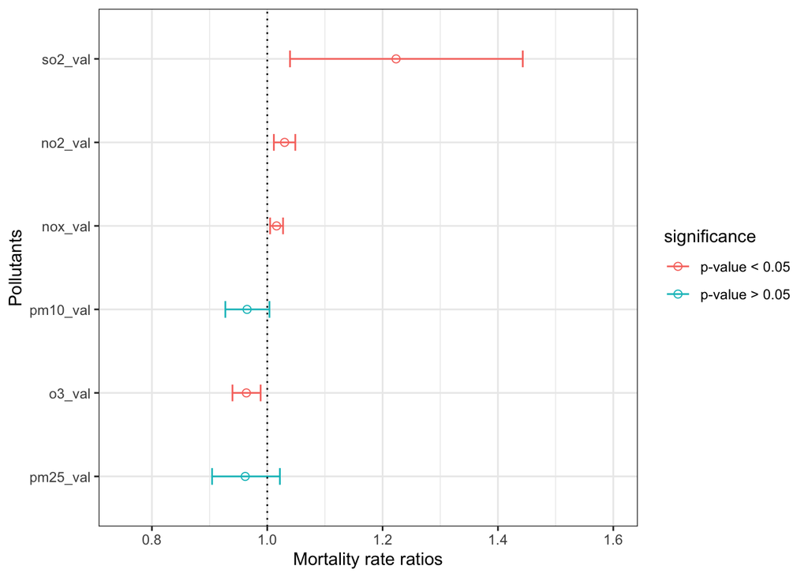

```r
ggplot(LA_covid_onlyPoll, aes(x=reorder(names, OR), y=OR, color=significance)) +
    geom_point(fill="white", shape=21, size = 2) +
    geom_errorbar(aes(ymin=X2.5.., ymax=X97.5..),
                  width=.2,                    # Width of the error bars
                  position=position_dodge(.9)) +
  theme_bw() +
  geom_hline(yintercept = 1, linetype="dotted") +
  coord_flip()+ylab("Mortality rate ratios") +
  xlab("Pollutants")+
  ylim(0.75, 1.6)
```

```r
ggsave('fig_out_v4/LA_deaths_MRR.pdf')
```

### Cases in local authorities

#### Data curation

```r
cases_LA_raw = read.csv("data_v4/coronavirus-cases_latest-18_5_2020.csv")
cases_LA_dt = subset(cases_LA_raw, Specimen.date == "2020-04-10", select = c(Area.code, Cumulative.lab.confirmed.cases))
cases_LA_dt.agg <-aggregate(cases_LA_dt, by=list(cases_LA_dt$Area.code),
  FUN=mean, na.rm=TRUE)
nrow(cases_LA_dt.agg)
```

```
## [1] 342
```

Merge cases data to main data

```r
deaths_LA_dt = read.csv("data_output_v4/merged_covidAir_cov_dt_LA.csv", na.strings = "x")
deaths_LA_dt$X2018.people.per.sq..km = gsub(",", "", deaths_LA_dt$X2018.people.per.sq..km)
deaths_LA_dt$X2018.people.per.sq..km = as.numeric(deaths_LA_dt$X2018.people.per.sq..km)
deaths_LA_dt$Mean_ann_earnings = gsub(",", "", deaths_LA_dt$Mean_ann_earnings)
deaths_LA_dt$Mean_ann_earnings = as.numeric(deaths_LA_dt$Mean_ann_earnings)

cases_deaths_LA_dt = merge(deaths_LA_dt, cases_LA_dt.agg, by.x = "Code",by.y = "Group.1")
nrow(cases_deaths_LA_dt)
```

```
## [1] 301
```

There are only 301 observations matched.

#### Analysis of the cases data

Visualisation

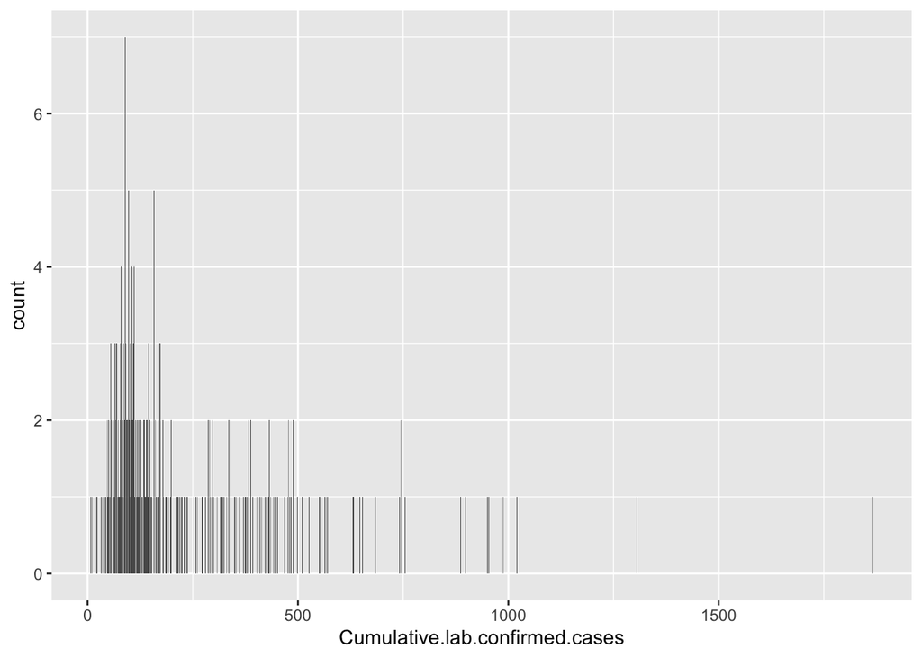

```r
ggplot(data = cases_deaths_LA_dt, aes(x = Cumulative.lab.confirmed.cases))+
  geom_histogram(stat="count")
```

```r
cases_deaths_LA_dt$X2018.people.per.sq..km = as.numeric(cases_deaths_LA_dt$X2018.people.per.sq..km)
cases_deaths_LA_dt$Mean_ann_earnings = as.numeric(cases_deaths_LA_dt$Mean_ann_earnings)
```

Model

```r
summary(pm25_cases.nb <- glm.nb(data = cases_deaths_LA_dt, Cumulative.lab.confirmed.cases ~ X2018.people.per.sq..km +
                                   Mean_ann_earnings + median_age_2018 + pm25_val))
```

```
##
## Call:
## glm.nb(formula = Cumulative.lab.confirmed.cases ~ X2018.people.per.sq..km +
##     Mean_ann_earnings + median_age_2018 + pm25_val, data = cases_deaths_LA_dt,
##     init.theta = 2.724975873, link = log)
##
## Deviance Residuals:
##     Min       1Q   Median       3Q      Max
## -2.8555  -0.8682  -0.3414   0.2772   2.8464
##
## Coefficients:
##                           Estimate Std. Error z value Pr(>|z|)
## (Intercept)              9.593e+00  5.567e-01  17.232  < 2e-16 ***
## X2018.people.per.sq..km  9.626e-05  1.953e-05   4.930 8.21e-07 ***
## Mean_ann_earnings        6.492e-06  5.788e-06   1.122 0.261996
## median_age_2018         -9.122e-02  1.037e-02  -8.800  < 2e-16 ***
## pm25_val                -9.629e-02  2.770e-02  -3.476 0.000509 ***
## ---
## Signif. codes:  0 '***' 0.001 '**' 0.01 '*' 0.05 '.' 0.1 ' ' 1
##
## (Dispersion parameter for Negative Binomial(2.725) family taken to be 1)
##
##     Null deviance: 562.55  on 294  degrees of freedom
## Residual deviance: 311.82  on 290  degrees of freedom
##   (6 observations deleted due to missingness)
## AIC: 3583.7
##
## Number of Fisher Scoring iterations: 1
##
##
##               Theta:  2.725
##           Std. Err.:  0.216
##
##  2 x log-likelihood:  -3571.745
```

```r
car::vif(pm25_cases.nb)
```

```
## X2018.people.per.sq..km       Mean_ann_earnings         median_age_2018
##                2.085624                1.427671                2.125130
##                pm25_val
##                1.933232
```

```r
summary(pm10_cases.nb <- glm.nb(data = cases_deaths_LA_dt, Cumulative.lab.confirmed.cases ~ X2018.people.per.sq..km +
                                   Mean_ann_earnings + median_age_2018 + pm10_val))
```

```
##
## Call:
## glm.nb(formula = Cumulative.lab.confirmed.cases ~ X2018.people.per.sq..km +
##     Mean_ann_earnings + median_age_2018 + pm10_val, data = cases_deaths_LA_dt,
##     init.theta = 2.745559885, link = log)
##
## Deviance Residuals:
##     Min       1Q   Median       3Q      Max
## -2.8501  -0.8823  -0.3287   0.2934   2.9348
##
## Coefficients:
##                           Estimate Std. Error z value Pr(>|z|)
## (Intercept)              9.513e+00  5.216e-01  18.238  < 2e-16 ***
## X2018.people.per.sq..km  1.002e-04  1.956e-05   5.122 3.03e-07 ***
## Mean_ann_earnings        5.806e-06  5.650e-06   1.028 0.304083
## median_age_2018         -8.743e-02  9.861e-03  -8.866  < 2e-16 ***
## pm10_val                -6.748e-02  1.762e-02  -3.831 0.000128 ***
## ---
## Signif. codes:  0 '***' 0.001 '**' 0.01 '*' 0.05 '.' 0.1 ' ' 1
##
## (Dispersion parameter for Negative Binomial(2.7456) family taken to be 1)
##
##     Null deviance: 566.73  on 294  degrees of freedom
## Residual deviance: 311.67  on 290  degrees of freedom
##   (6 observations deleted due to missingness)
## AIC: 3581.3
##
## Number of Fisher Scoring iterations: 1
##
##
##               Theta:  2.746
##           Std. Err.:  0.218
##
##  2 x log-likelihood:  -3569.297
```

```r
car::vif(pm10_cases.nb)
```

```
## X2018.people.per.sq..km       Mean_ann_earnings         median_age_2018
##                2.109349                1.370273                1.937009
##                pm10_val
##                1.650101
```

```r
summary(nox_cases.nb <- glm.nb(data = cases_deaths_LA_dt, Cumulative.lab.confirmed.cases ~ X2018.people.per.sq..km +
                                  Mean_ann_earnings + median_age_2018 + nox_val))
```

```
##
## Call:
## glm.nb(formula = Cumulative.lab.confirmed.cases ~ X2018.people.per.sq..km +
##     Mean_ann_earnings + median_age_2018 + nox_val, data = cases_deaths_LA_dt,
##     init.theta = 2.721556683, link = log)
##
## Deviance Residuals:
##     Min       1Q   Median       3Q      Max
## -2.7665  -0.8356  -0.3858   0.3034   3.4862
##
## Coefficients:
##                           Estimate Std. Error z value Pr(>|z|)
## (Intercept)              7.409e+00  4.954e-01  14.956  < 2e-16 ***
## X2018.people.per.sq..km  5.246e-05  2.220e-05   2.363  0.01813 *
## Mean_ann_earnings       -4.812e-06  5.385e-06  -0.894  0.37145
## median_age_2018         -5.803e-02  1.051e-02  -5.522 3.35e-08 ***
## nox_val                  1.740e-02  5.344e-03   3.255  0.00113 **
## ---
## Signif. codes:  0 '***' 0.001 '**' 0.01 '*' 0.05 '.' 0.1 ' ' 1
##
## (Dispersion parameter for Negative Binomial(2.7216) family taken to be 1)
##
##     Null deviance: 561.85  on 294  degrees of freedom
## Residual deviance: 312.05  on 290  degrees of freedom
##   (6 observations deleted due to missingness)
## AIC: 3584.4
##
## Number of Fisher Scoring iterations: 1
##
##
##               Theta:  2.722
##           Std. Err.:  0.216
##
##  2 x log-likelihood:  -3572.364
```

```r
car::vif(nox_cases.nb)
```

```
## X2018.people.per.sq..km       Mean_ann_earnings         median_age_2018
##                2.692080                1.233985                2.182823
##                 nox_val
##                2.905970
```

```r
summary(no2_cases.nb <- glm.nb(data = cases_deaths_LA_dt, Cumulative.lab.confirmed.cases ~ X2018.people.per.sq..km +
                                  Mean_ann_earnings + median_age_2018 + no2_val))
```

```
##
## Call:
## glm.nb(formula = Cumulative.lab.confirmed.cases ~ X2018.people.per.sq..km +
##     Mean_ann_earnings + median_age_2018 + no2_val, data = cases_deaths_LA_dt,
##     init.theta = 2.729294735, link = log)
##
## Deviance Residuals:
##     Min       1Q   Median       3Q      Max
## -2.7594  -0.8476  -0.3940   0.3071   3.5818
##
## Coefficients:
##                           Estimate Std. Error z value Pr(>|z|)
## (Intercept)              7.190e+00  5.306e-01  13.550  < 2e-16 ***
## X2018.people.per.sq..km  5.698e-05  2.142e-05   2.661  0.00780 **
## Mean_ann_earnings       -4.853e-06  5.365e-06  -0.904  0.36574
## median_age_2018         -5.476e-02  1.094e-02  -5.007 5.52e-07 ***
## no2_val                  3.005e-02  9.141e-03   3.287  0.00101 **
## ---
## Signif. codes:  0 '***' 0.001 '**' 0.01 '*' 0.05 '.' 0.1 ' ' 1
##
## (Dispersion parameter for Negative Binomial(2.7293) family taken to be 1)
##
##     Null deviance: 563.42  on 294  degrees of freedom
## Residual deviance: 312.03  on 290  degrees of freedom
##   (6 observations deleted due to missingness)
## AIC: 3583.5
##
## Number of Fisher Scoring iterations: 1
##
##
##               Theta:  2.729
##           Std. Err.:  0.216
##
##  2 x log-likelihood:  -3571.468
```

```r
car::vif(no2_cases.nb)
```

```
## X2018.people.per.sq..km       Mean_ann_earnings         median_age_2018
##                2.512648                1.228516                2.370271
##                 no2_val
##                2.910421
```

```r
summary(o3_cases.nb <- glm.nb(data = cases_deaths_LA_dt, Cumulative.lab.confirmed.cases ~ X2018.people.per.sq..km +
                                 Mean_ann_earnings + median_age_2018 + o3_val))
```

```
##
## Call:
## glm.nb(formula = Cumulative.lab.confirmed.cases ~ X2018.people.per.sq..km +
##     Mean_ann_earnings + median_age_2018 + o3_val, data = cases_deaths_LA_dt,
##     init.theta = 2.808347379, link = log)
##
## Deviance Residuals:
##     Min       1Q   Median       3Q      Max
## -2.9822  -0.8344  -0.3153   0.3226   2.8354
##
## Coefficients:
##                           Estimate Std. Error z value Pr(>|z|)
## (Intercept)              8.206e+00  4.265e-01  19.241  < 2e-16 ***
## X2018.people.per.sq..km  6.994e-05  1.934e-05   3.616 0.000299 ***
## Mean_ann_earnings        7.689e-06  5.480e-06   1.403 0.160572
## median_age_2018         -6.928e-02  9.456e-03  -7.327 2.36e-13 ***
## o3_val                  -5.259e-02  1.111e-02  -4.733 2.21e-06 ***
## ---
## Signif. codes:  0 '***' 0.001 '**' 0.01 '*' 0.05 '.' 0.1 ' ' 1
##
## (Dispersion parameter for Negative Binomial(2.8083) family taken to be 1)
##
##     Null deviance: 579.47  on 294  degrees of freedom
## Residual deviance: 311.40  on 290  degrees of freedom
##   (6 observations deleted due to missingness)
## AIC: 3574.1
##
## Number of Fisher Scoring iterations: 1
##
##
##               Theta:  2.808
##           Std. Err.:  0.223
##
##  2 x log-likelihood:  -3562.114
```

```r
car::vif(o3_cases.nb)
```

```
## X2018.people.per.sq..km       Mean_ann_earnings         median_age_2018
##                2.108263                1.318626                1.820923
##                  o3_val
##                1.177405
```

```r
summary(so2_cases.nb <- glm.nb(data = cases_deaths_LA_dt, Cumulative.lab.confirmed.cases ~ X2018.people.per.sq..km +
                                  Mean_ann_earnings + median_age_2018 + so2_val))
```

```
##
## Call:
## glm.nb(formula = Cumulative.lab.confirmed.cases ~ X2018.people.per.sq..km +
##     Mean_ann_earnings + median_age_2018 + so2_val, data = cases_deaths_LA_dt,
##     init.theta = 2.717269061, link = log)
##
## Deviance Residuals:
##     Min       1Q   Median       3Q      Max
## -2.7230  -0.8505  -0.3570   0.3183   3.4351
##
## Coefficients:
##                           Estimate Std. Error z value Pr(>|z|)
## (Intercept)              7.239e+00  5.311e-01  13.629  < 2e-16 ***
## X2018.people.per.sq..km  7.709e-05  1.964e-05   3.925 8.66e-05 ***
## Mean_ann_earnings        2.288e-06  5.451e-06   0.420  0.67462
## median_age_2018         -6.018e-02  1.036e-02  -5.811 6.20e-09 ***
## so2_val                  2.370e-01  7.467e-02   3.174  0.00151 **
## ---
## Signif. codes:  0 '***' 0.001 '**' 0.01 '*' 0.05 '.' 0.1 ' ' 1
##
## (Dispersion parameter for Negative Binomial(2.7173) family taken to be 1)
##
##     Null deviance: 560.98  on 294  degrees of freedom
## Residual deviance: 312.07  on 290  degrees of freedom
##   (6 observations deleted due to missingness)
## AIC: 3584.9
##
## Number of Fisher Scoring iterations: 1
##
##
##               Theta:  2.717
##           Std. Err.:  0.215
##
##  2 x log-likelihood:  -3572.864
```

```r
car::vif(so2_cases.nb)
```

```
## X2018.people.per.sq..km       Mean_ann_earnings         median_age_2018
##                2.104075                1.262575                2.115436
##                 so2_val
##                1.525447
```

#### Generate the table

```r
stargazer(pm25_cases.nb, pm10_cases.nb, nox_cases.nb, no2_cases.nb,
          o3_cases.nb, so2_cases.nb,type="html",out = "fig_out_v4/LA_covid_allPoll_CASES_nb.html",
          dep.var.labels="Number of COVID-19-related cases",
          single.row=TRUE)
```

|  | *Dependent variable:* |  |  |  |  |  |
| --- | --- | --- | --- | --- | --- | --- |
|  | Number of COVID-19-related cases |  |  |  |  |  |
|  | (1) | (2) | (3) | (4) | (5) | (6) |
| X2018.people.per.sq..km | 0.0001*** (0.00002) | 0.0001*** (0.00002) | 0.0001** (0.00002) | 0.0001*** (0.00002) | 0.0001*** (0.00002) | 0.0001*** (0.00002) |
| Mean_ann_earnings | 0.00001 (0.00001) | 0.00001 (0.00001) | -0.00000 (0.00001) | -0.00000 (0.00001) | 0.00001 (0.00001) | 0.00000 (0.00001) |
| median_age_2018 | -0.091*** (0.010) | -0.087*** (0.010) | -0.058*** (0.011) | -0.055*** (0.011) | -0.069*** (0.009) | -0.060*** (0.010) |
| pm25_val | -0.096*** (0.028) |  |  |  |  |  |
| pm10_val |  | -0.067*** (0.018) |  |  |  |  |
| nox_val |  |  | 0.017*** (0.005) |  |  |  |
| no2_val |  |  |  | 0.030*** (0.009) |  |  |
| o3_val |  |  |  |  | -0.053*** (0.011) |  |
| so2_val |  |  |  |  |  | 0.237*** (0.075) |
| Constant | 9.593*** (0.557) | 9.513*** (0.522) | 7.409*** (0.495) | 7.190*** (0.531) | 8.206*** (0.426) | 7.239*** (0.531) |
| Observations | 295 | 295 | 295 | 295 | 295 | 295 |
| Log Likelihood | -1,786.872 | -1,785.649 | -1,787.182 | -1,786.734 | -1,782.057 | -1,787.432 |
| theta | 2.725*** (0.216) | 2.746*** (0.218) | 2.722*** (0.216) | 2.729*** (0.216) | 2.808*** (0.223) | 2.717*** (0.215) |
| Akaike Inf. Crit. | 3,583.745 | 3,581.297 | 3,584.364 | 3,583.468 | 3,574.114 | 3,584.864 |
| *Note:* | p<0.1; p<0.05; p<0.01 |  |  |  |  |  |

##### Calculate odds ratios

```r
pm25_cases.nb_mrr = data.frame(cbind(exp(cbind(OR = coef(pm25_cases.nb), confint(pm25_cases.nb))), p_value = summary(pm25_cases.nb)$coefficients[,4]))
pm10_cases.nb_mrr = data.frame(cbind(exp(cbind(OR = coef(pm10_cases.nb), confint(pm10_cases.nb))), p_value = summary(pm10_cases.nb)$coefficients[,4]))
nox_cases.nb_mrr = data.frame(cbind(exp(cbind(OR = coef(nox_cases.nb), confint(nox_cases.nb))), p_value = summary(nox_cases.nb)$coefficients[,4]))
no2_cases.nb_mrr = data.frame(cbind(exp(cbind(OR = coef(no2_cases.nb), confint(no2_cases.nb))), p_value = summary(no2_cases.nb)$coefficients[,4]))
o3_cases.nb_mrr = data.frame(cbind(exp(cbind(OR = coef(o3_cases.nb), confint(o3_cases.nb))), p_value = summary(o3_cases.nb)$coefficients[,4]))
so2_cases.nb_mrr = data.frame(cbind(exp(cbind(OR = coef(so2_cases.nb), confint(so2_cases.nb))), p_value = summary(so2_cases.nb)$coefficients[,4]))
#make a df just with the pollutants

LA_covid_CASES_onlyPoll = data.frame(rbind(pm25_cases.nb_mrr[nrow(pm25_cases.nb_mrr),],
                                      pm10_cases.nb_mrr[nrow(pm10_cases.nb_mrr),],
                                      nox_cases.nb_mrr[nrow(nox_cases.nb_mrr),],
                                      no2_cases.nb_mrr[nrow(no2_cases.nb_mrr),],
                                      o3_cases.nb_mrr[nrow(o3_cases.nb_mrr),],
                                      so2_cases.nb_mrr[nrow(so2_cases.nb_mrr),]))
```

##### Plot odds ratios

sort data

```r
LA_covid_CASES_onlyPoll$names = row.names(LA_covid_CASES_onlyPoll)
LA_covid_CASES_onlyPoll$significance = "p-value > 0.05"
LA_covid_CASES_onlyPoll$significance[LA_covid_CASES_onlyPoll$p_value < 0.05] <- "p-value < 0.05"
```

plot

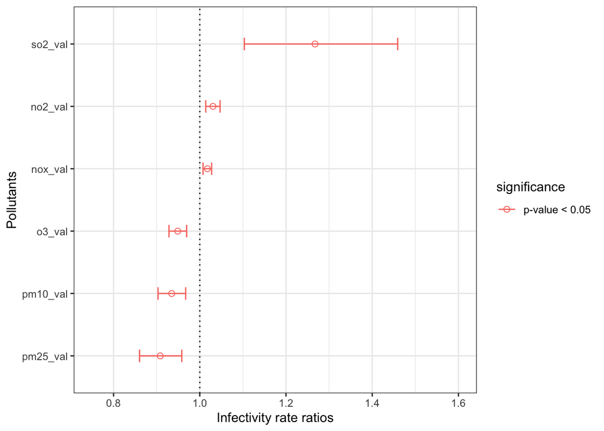

```r
ggplot(LA_covid_CASES_onlyPoll, aes(x=reorder(names, OR), y=OR, color=significance)) +
    geom_point(fill="white", shape=21, size = 2) +
    geom_errorbar(aes(ymin=X2.5.., ymax=X97.5..),
                  width=.2,                    # Width of the error bars
                  position=position_dodge(.9)) +
  theme_bw() +
  geom_hline(yintercept = 1, linetype="dotted") +
  coord_flip()+ylab("Infectivity rate ratios") +
  xlab("Pollutants")+
  ylim(0.75, 1.6)
```

```r
ggsave('fig_out_v4/LA_CASES_odds_IRR.pdf')
```

### Summary tables of models in Aim 2

```r
stargazer(pm25_cases.nb, pm10_cases.nb, nox_cases.nb, no2_cases.nb,
          o3_cases.nb, so2_cases.nb,type="html",out = "fig_out_v4/LA_covid_allPoll_CASES_nb.html",
          dep.var.labels="Number of COVID-19-related cases",
          single.row=TRUE)
```

|  | *Dependent variable:* |  |  |  |  |  |
| --- | --- | --- | --- | --- | --- | --- |
|  | Number of COVID-19-related cases |  |  |  |  |  |
|  | (1) | (2) | (3) | (4) | (5) | (6) |
| X2018.people.per.sq..km | 0.0001*** (0.00002) | 0.0001*** (0.00002) | 0.0001** (0.00002) | 0.0001*** (0.00002) | 0.0001*** (0.00002) | 0.0001*** (0.00002) |
| Mean_ann_earnings | 0.00001 (0.00001) | 0.00001 (0.00001) | -0.00000 (0.00001) | -0.00000 (0.00001) | 0.00001 (0.00001) | 0.00000 (0.00001) |
| median_age_2018 | -0.091*** (0.010) | -0.087*** (0.010) | -0.058*** (0.011) | -0.055*** (0.011) | -0.069*** (0.009) | -0.060*** (0.010) |
| pm25_val | -0.096*** (0.028) |  |  |  |  |  |
| pm10_val |  | -0.067*** (0.018) |  |  |  |  |
| nox_val |  |  | 0.017*** (0.005) |  |  |  |
| no2_val |  |  |  | 0.030*** (0.009) |  |  |
| o3_val |  |  |  |  | -0.053*** (0.011) |  |
| so2_val |  |  |  |  |  | 0.237*** (0.075) |
| Constant | 9.593*** (0.557) | 9.513*** (0.522) | 7.409*** (0.495) | 7.190*** (0.531) | 8.206*** (0.426) | 7.239*** (0.531) |
| Observations | 295 | 295 | 295 | 295 | 295 | 295 |
| Log Likelihood | -1,786.872 | -1,785.649 | -1,787.182 | -1,786.734 | -1,782.057 | -1,787.432 |
| theta | 2.725*** (0.216) | 2.746*** (0.218) | 2.722*** (0.216) | 2.729*** (0.216) | 2.808*** (0.223) | 2.717*** (0.215) |
| Akaike Inf. Crit. | 3,583.745 | 3,581.297 | 3,584.364 | 3,583.468 | 3,574.114 | 3,584.864 |
| *Note:* | p<0.1; p<0.05; p<0.01 |  |  |  |  |  |

*: p<0.1; **: p<0.05; ***: p<0.01  
The value in parentheses represent the standard error.  
Summary of the effects of individual air pollutant species on lab-confirmed COVID-related cases up to April 10th 2020. The three asterisks near the theta indicate that the models are significantly better than null.

#### Supplementary Table 5. Effect of air pollutants on the number of COVID-related deaths at the subregional level

```r
stargazer(pm25_deaths.nb, pm10_deaths.nb, nox_deaths.nb, no2_deaths.nb,
          o3_deaths.nb, so2_deaths.nb,type="html",out = "fig_out_v4/LA_covid_allPoll_nb.html",
          dep.var.labels="Number of COVID-19-related deaths",
          single.row=TRUE)
```

|  | *Dependent variable:* |  |  |  |  |  |
| --- | --- | --- | --- | --- | --- | --- |
|  | Number of COVID-19-related deaths |  |  |  |  |  |
|  | (1) | (2) | (3) | (4) | (5) | (6) |
| X2018.people.per.sq..km | 0.0001*** (0.00002) | 0.0001*** (0.00002) | 0.0001*** (0.00002) | 0.0001*** (0.00002) | 0.0001*** (0.00002) | 0.0001*** (0.00002) |
| Mean_ann_earnings | 0.00000 (0.00001) | 0.00001 (0.00001) | -0.00000 (0.00001) | -0.00000 (0.00001) | 0.00001 (0.00001) | 0.00001 (0.00001) |
| median_age_2018 | -0.079*** (0.012) | -0.079*** (0.011) | -0.055*** (0.012) | -0.050*** (0.012) | -0.067*** (0.011) | -0.058*** (0.012) |
| pm25_val | -0.039 (0.031) |  |  |  |  |  |
| pm10_val |  | -0.036* (0.020) |  |  |  |  |
| nox_val |  |  | 0.016*** (0.006) |  |  |  |
| no2_val |  |  |  | 0.030*** (0.010) |  |  |
| o3_val |  |  |  |  | -0.037*** (0.013) |  |
| so2_val |  |  |  |  |  | 0.202** (0.083) |
| Constant | 6.988*** (0.635) | 7.103*** (0.597) | 5.541*** (0.542) | 5.268*** (0.580) | 6.323*** (0.489) | 5.498*** (0.596) |
| Observations | 306 | 306 | 306 | 306 | 306 | 306 |
| Log Likelihood | -1,395.565 | -1,394.788 | -1,392.433 | -1,391.427 | -1,392.320 | -1,393.427 |
| theta | 2.099*** (0.171) | 2.109*** (0.171) | 2.143*** (0.175) | 2.157*** (0.176) | 2.142*** (0.175) | 2.129*** (0.174) |
| Akaike Inf. Crit. | 2,801.130 | 2,799.577 | 2,794.865 | 2,792.853 | 2,794.640 | 2,796.854 |
| *Note:* | p<0.1; p<0.05; p<0.01 |  |  |  |  |  |

## Aim 3: Individual level analysis

### Data curation

#### covid data curation

```r
covid_df = read.csv("data_v4/covid19_result.txt", sep = '\t')
covid_id = covid_df[,c(1,5,6)]
# I didnt realise that there were repeated values!!!!!
colnames(covid_id)
```

```
## [1] "eid"    "origin" "result"
```

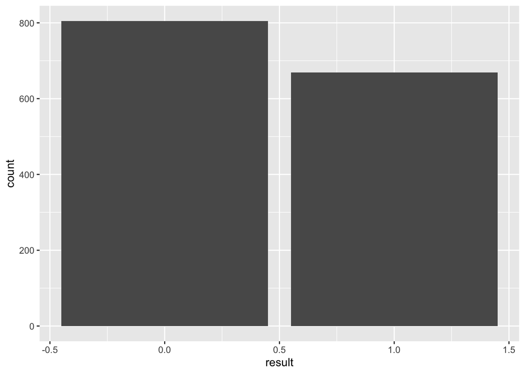

```r
covid_id_unique = aggregate(covid_id, by=list(covid_id$eid),
                            FUN=max)

ggplot(data = covid_id_unique, aes(x = result))+
  geom_histogram(stat="count")
```

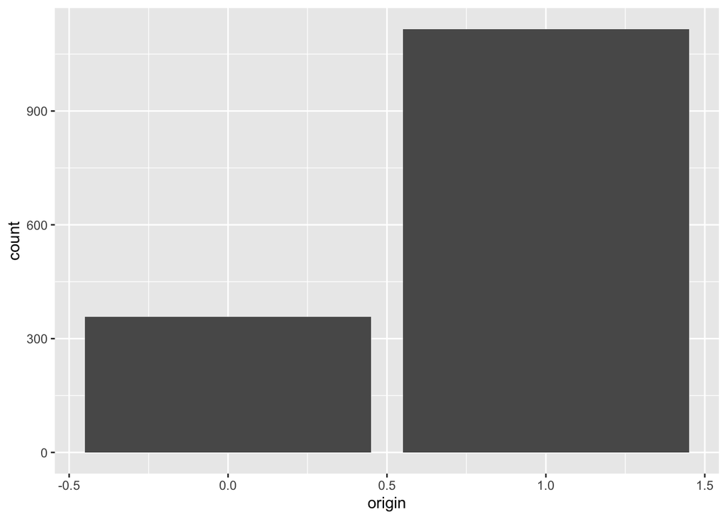

```r
ggplot(data = covid_id_unique, aes(x = origin))+
  geom_histogram(stat="count")
```

#### load non-covid UKB phenotype data

Data curation

```r
### load non-covid UKB phenotype data ----
ukb_covid = read.csv("data_v4/29_4_2020_ukb41646_covid19_subset.csv")[,-1]
#check distribution

#here, I will aggregate the columns by selecting the last results, for each
# reshape
ukb_covid_t = melt(ukb_covid, id='eid')
ukb_covid_t <- ukb_covid_t[order(ukb_covid_t$variable),]
#delete everything after period
ukb_covid_t$variable = gsub("\\..*","",ukb_covid_t$variable)

#aggregate by last
ukb_covid_t_na = na.omit(ukb_covid_t)
ukb_covid_t_na = aggregate(ukb_covid_t_na, by=list(ukb_covid_t_na$eid,ukb_covid_t_na$variable), FUN=last)

# put it back straight
ukb_covid_t_na$variable = as.factor(ukb_covid_t_na$variable)
ukb_covid_t_na = ukb_covid_t_na[,-c(1,2)]
ukb_covid_cur = cast(ukb_covid_t_na, eid~variable)

### label UKB data ----
#get levels and labels
lvl.0493 <- c(-141,-131,-121,0)
lbl.0493 <- c("Often","Sometimes","Do not know","Rarely/never")

lvl.0007 <- c(0,1)
lbl.0007 <- c("No","Yes")

lvl.100349 <- c(-3,-1,0,1)
lbl.100349 <- c("Prefer not to answer","Do not know","No","Yes")

lvl.0090 <- c(-3,0,1,2)
lbl.0090 <- c("Prefer not to answer","Never","Previous","Current")

lvl.0009 <- c(0,1)
lbl.0009 <- c("Female","Male")

### eid replacement, saved here ----
yy_replace <- function(string, patterns, replacements) {
  for (i in seq_along(patterns))
    string <- gsub(patterns[i], replacements[i], string, perl=TRUE)
  string
}
#label = replacement, lvl = to replace

ukb_covid_cur$X22609 <- yy_replace(ukb_covid_cur$X22609, lvl.0493, lbl.0493)
ukb_covid_cur$X22610 <- yy_replace(ukb_covid_cur$X22610, lvl.0493, lbl.0493)
ukb_covid_cur$X22611 <- yy_replace(ukb_covid_cur$X22611, lvl.0493, lbl.0493)
ukb_covid_cur$X22615 <- yy_replace(ukb_covid_cur$X22615, lvl.0493, lbl.0493)
ukb_covid_cur$X22616 <- yy_replace(ukb_covid_cur$X22616, lvl.0007, lbl.0007)
ukb_covid_cur$X2316 <- yy_replace(ukb_covid_cur$X2316, lvl.100349, lbl.100349)
ukb_covid_cur$X31 <- yy_replace(ukb_covid_cur$X31, lvl.0009, lbl.0009)
ukb_covid_cur$X22130 <- yy_replace(ukb_covid_cur$X22130, lvl.0007, lbl.0007)
ukb_covid_cur$X2443 <- yy_replace(ukb_covid_cur$X2443, lvl.100349, lbl.100349)
ukb_covid_cur$X20116 <- yy_replace(ukb_covid_cur$X20116, lvl.0090, lbl.0090)


### put custom column names----
#get the ID that I designed
UID_names = read.csv("data_v4/UKB_list_columns_AIRcovid.csv")[c("FieldID","my_colname")]
UID_names$FieldID = paste("X",UID_names$FieldID, sep = "")
UID_names$my_colname = lapply(UID_names$my_colname,toString)
UID_names[nrow(UID_names) + 1,] = c("eid","eid")

# sort it according to the dataset

UID_names_match = colnames(ukb_covid_cur)

UID_sort_df = data.frame(UID_names_match)
colnames(UID_sort_df) <- "FieldID"

#merge to sort
UID_sort_df = merge(UID_sort_df, UID_names, by = "FieldID")
# this is now sorted according to the correct df

#replace column names
ukb_covid_df = ukb_covid_cur

colnames(ukb_covid_df) <- UID_sort_df$my_colname

### merge both ukb datasets together ----
ukb_covid_merge = merge(covid_id_unique[,-1], ukb_covid_df, by = "eid")
nrow(ukb_covid_merge)
```

```
## [1] 1474
```

further processing…

```r
# do 2020 since COVID occurred in this year
ukb_covid_merge$age = 2020 - ukb_covid_merge$birthYear
ukb_covid_merge$whr = ukb_covid_merge$waist / ukb_covid_merge$hip

#definition from the NHS: Diastolic >= 90 OR Systolic >=140
ukb_covid_merge$highBP[ukb_covid_merge$diaBP>=90 | ukb_covid_merge$sysBP>=140] <-1
ukb_covid_merge$highBP[ukb_covid_merge$diaBP<90 | ukb_covid_merge$sysBP<140] <-0

# add a column: COVID + and inpatient
ukb_covid_merge$inpatient_covid  <-0
ukb_covid_merge$inpatient_covid [ukb_covid_merge$origin == 1 & ukb_covid_merge$origin == 1] <-1

write.csv(ukb_covid_merge, "data_output_v4/processed_29_4_2020_ukb41646_covid19.csv")
```

#### Preliminary analysis with PM2.5

I will load the air pollutants & match the covid patients to their nearest pollution climate mapping location.

```r
### load pm2.5 data ----
#note the pop weighted data have the area code, but not the x y coords

pm25 = read.csv("data_v4/processed_PM25_uk-air_annual_mean_mappm252018g.csv", na.strings = "MISSING")[c("x","y","pm252018g")]
nrow(pm25)
```

```
## [1] 281802
```

```r
pm25_na = na.omit(pm25)
nrow(pm25_na)
```

```
## [1] 254877
```

```r
### convert to lon lat - pm2.5 ----

# transform: easting/northing -> long/lat
### shortcuts (from https://stephendavidgregory.github.io/useful/UKgrid_to_LatLon)
ukgrid <- "+init=epsg:27700"
latlong <- "+init=epsg:4326"

### Create coordinates variable
pm25_coords <- cbind(Easting = as.numeric(as.character(pm25_na$x)),
                Northing = as.numeric(as.character(pm25_na$y)))

### Create the SpatialPointsDataFrame
pm25_SP <- SpatialPointsDataFrame(pm25_coords,
                                 data = pm25_na,
                                 proj4string = CRS("+init=epsg:27700"))

### Convert
pm25_LL <- spTransform(pm25_SP, CRS(latlong))

pm25_ll_df = data.frame('pm25_lon' = coordinates(pm25_LL)[, 1], 'pm25_lat' = coordinates(pm25_LL)[, 2], 'pm25_val' = pm25_LL$pm252018g)


write.csv(pm25_ll_df,"data_output_v4/processed_pm25_lonlat.csv")
```

#### convert UKB data to long lat

```r
# convert ukb data eastings northing to lon lat

ukb_covid_coord_na = na.omit(ukb_covid_merge[c("eid","x_coord","y_coord")])
nrow(ukb_covid_coord_na)
```

```
## [1] 1464
```

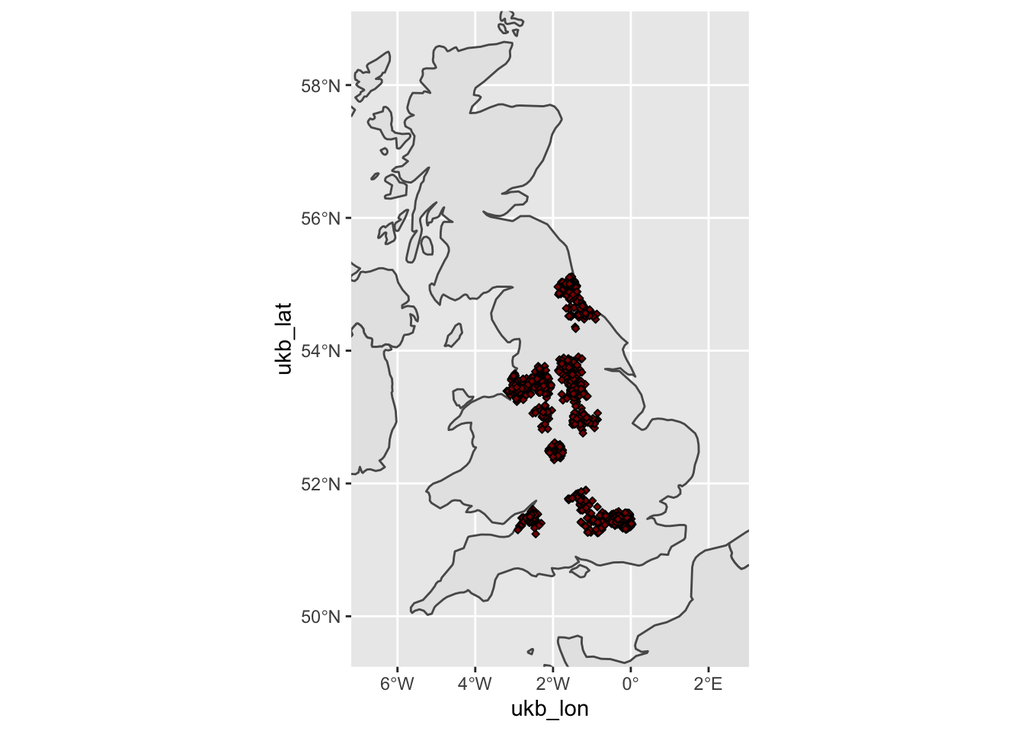

```r
ukb_covid_coords <- cbind(Easting = as.numeric(as.character(ukb_covid_coord_na$x_coord)),
                     Northing = as.numeric(as.character(ukb_covid_coord_na$y_coord)))
### Create the SpatialPointsDataFrame
ukb_covid_SP <- SpatialPointsDataFrame(ukb_covid_coords,
                                  data = ukb_covid_coord_na,
                                  proj4string = CRS("+init=epsg:27700"))

### Convert
ukb_covid_ll <- spTransform(ukb_covid_SP, CRS(latlong))

ukb_covid_ll_df = data.frame('ukb_lon' = coordinates(ukb_covid_ll)[, 1],
                             'ukb_lat' = coordinates(ukb_covid_ll)[, 2],
                             'eid' = ukb_covid_ll$eid)
write.csv(ukb_covid_ll_df, ("data_output_v4/ukb_covid_lonlat_df.csv"))
# plot UKB locations
world <- ne_countries(scale = "medium", returnclass = "sf")
ggplot(data = world) +
  geom_sf() +
  geom_point(data = ukb_covid_ll_df, aes(x = ukb_lon, y = ukb_lat), size = 1,
             shape = 23, fill = "darkred") +
  coord_sf(ylim = c(min(ukb_covid_ll_df$ukb_lat)-2, max(ukb_covid_ll_df$ukb_lat)+4),
           xlim = c(min(ukb_covid_ll_df$ukb_lon)-4, max(ukb_covid_ll_df$ukb_lon)+3), expand = FALSE)
```

```r
ggsave('fig_out_v4/UKB_COVID_participants_locations.pdf')
```

**I wrote a python script: match_air_to_UKB_covid**

### Merge and QC data for PM2.5

```r
ukb_eid_pm25_merged = read.csv('data_output_v4/merged_ukb_pm25.csv')[c("eid","distance","pm25_val")]

ukb_covid_pm25_df = merge(ukb_covid_merge, ukb_eid_pm25_merged, by = 'eid')
colnames(ukb_covid_pm25_df)
```

```
##  [1] "eid"             "origin"          "result"          "n_cancers"
##  [5] "townsend"        "x_coord"         "y_coord"         "smoking"
##  [9] "fev"             "copd"            "WP_dusty"        "WP_chemicals"
## [13] "WP_cig"          "WP_diesel"       "breathing"       "whistling"
## [17] "diabetes"        "sex"             "birthYear"       "diaBP"
## [21] "sysBP"           "waist"           "hip"             "height"
## [25] "age"             "whr"             "highBP"          "inpatient_covid"
## [29] "distance"        "pm25_val"
```

```r
#omit those without coordinates in the ukb data

### merge pop density----
ukb_cities_eid = read.csv("data_output_v4/2_5_2020_ukb_eid_match_cities.csv")[c("eid","spec_area","gen_area")]
nrow(ukb_cities_eid)
```

```
## [1] 1464
```

```r
popDens_2018 = read.csv("data_v4/2018_official_popDensity.csv")[c("Name","X2018.people.per.sq..km")]
popDens_2018$X2018.people.per.sq..km = gsub(",", "", popDens_2018$X2018.people.per.sq..km)
popDens_2018$X2018.people.per.sq..km = as.numeric(popDens_2018$X2018.people.per.sq..km)

#Make everything lower case
ukb_cities_eid$spec_area = tolower(ukb_cities_eid$spec_area)
ukb_cities_eid$gen_area = tolower(ukb_cities_eid$gen_area)
popDens_2018$Name = tolower(popDens_2018$Name)

#delete repeated strings
ukb_cities_eid$spec_area = gsub("london borough of ", "", ukb_cities_eid$spec_area)
ukb_cities_eid$spec_area = gsub("royal borough of ", "", ukb_cities_eid$spec_area)
ukb_cities_eid$spec_area = gsub("city of ", "", ukb_cities_eid$spec_area)
ukb_cities_eid$spec_area = gsub("st helens", "helens", ukb_cities_eid$spec_area)
ukb_cities_eid$gen_area = gsub(" combined authority", "", ukb_cities_eid$gen_area)
popDens_2018$Name = gsub(", city of", "", popDens_2018$Name)
popDens_2018$Name = gsub("st. ", "", popDens_2018$Name)
#delete west midlands because its redundant (all cities are well defined) and there are several regions called west midlands so it's confusing
popDens_2018$Name = gsub("west midlands", "deleted_west_midlands_because_redundant", popDens_2018$Name)
popDens_2018$Name = gsub("\\s*\\([^\\)]+\\)","",popDens_2018$Name)

ukb_cities_eid_merged = merge(ukb_cities_eid, popDens_2018, by.x="spec_area",by.y="Name", all.x=TRUE)
colnames(ukb_cities_eid_merged)[4] <- "spec_Pop_dens_perkm2"
nrow(ukb_cities_eid_merged)
```

```
## [1] 1464
```

```r
#check for duplicated rows in popDens
length(unique(popDens_2018$Name))
```

```
## [1] 434
```

```r
length(popDens_2018$Name) # there is a dupicate
```

```
## [1] 435
```

```r
popDens_2018$Name[duplicated(popDens_2018$Name)]
```

```
## [1] "deleted_west_midlands_because_redundant"
```

```r
ukb_cities_eid_merged2 = merge(ukb_cities_eid_merged, popDens_2018, by.x="gen_area",by.y="Name", all.x=TRUE,all.y=FALSE)
colnames(ukb_cities_eid_merged2)[5] <- "gen_Pop_dens_perkm2"
nrow(ukb_cities_eid_merged2)
```

```
## [1] 1464
```

```r
#QC
sum(is.na(ukb_cities_eid_merged2$spec_Pop_dens_perkm2))
```

```
## [1] 214
```

```r
sum(is.na(ukb_cities_eid_merged2$gen_Pop_dens_perkm2))
```

```
## [1] 516
```

```r
ukb_cities_eid_merged2$merged_popDens_km2 <- ifelse(is.na(ukb_cities_eid_merged2$spec_Pop_dens_perkm2),
                                                    ukb_cities_eid_merged2$gen_Pop_dens_perkm2, ukb_cities_eid_merged2$spec_Pop_dens_perkm2)
ukb_cities_eid_out = ukb_cities_eid_merged2[c("eid","merged_popDens_km2")]
ukb_covid_pm25_popDens_df = merge(ukb_covid_pm25_df, ukb_cities_eid_out, by = 'eid')
nrow(ukb_covid_pm25_df)
```

```
## [1] 1464
```

```r
ukb_covid_pm25_popDens_df = read.csv("data_output_v4/2_5_2020_full_cov_CV_UKB_air_dataset.csv")
ukb_covid_pm25_popDens_df$smoker = ifelse(ukb_covid_pm25_popDens_df$smoking =="Current", "smoking", "not_smoking")

library(MASS)
summary(ukb_covid_pm25.nb <-glm.nb(data = ukb_covid_pm25_popDens_df, result ~ merged_popDens_km2 + n_cancers +townsend + smoking + whistling + diabetes+
                               whr + sex + age + pm25_val))
```

```
##
## Call:
## glm.nb(formula = result ~ merged_popDens_km2 + n_cancers + townsend +
##     smoking + whistling + diabetes + whr + sex + age + pm25_val,
##     data = ukb_covid_pm25_popDens_df, init.theta = 15229.88441,
##     link = log)
##
## Deviance Residuals:
##     Min       1Q   Median       3Q      Max
## -1.2059  -0.9479  -0.8028   0.6589   1.1708
##
## Coefficients:
##                                 Estimate Std. Error z value Pr(>|z|)
## (Intercept)                   -2.065e+00  8.543e-01  -2.418  0.01562 *
## merged_popDens_km2            -9.956e-06  1.884e-05  -0.529  0.59711
## n_cancers                     -1.258e-01  1.272e-01  -0.989  0.32253
## townsend                       1.354e-02  1.310e-02   1.034  0.30121
## smokingNever                   3.665e-01  1.379e-01   2.658  0.00785 **
## smokingPrefer not to answer    7.608e-01  4.478e-01   1.699  0.08929 .
## smokingPrevious                4.056e-01  1.377e-01   2.946  0.00322 **
## whistlingNo                    2.671e-01  2.698e-01   0.990  0.32220
## whistlingPrefer not to answer  4.568e-02  1.276e+00   0.036  0.97145
## whistlingYes                   2.533e-01  2.742e-01   0.924  0.35559
## diabetesNo                    -1.619e-01  6.106e-01  -0.265  0.79085
## diabetesPrefer not to answer  -6.877e-01  1.433e+00  -0.480  0.63140
## diabetesYes                   -1.956e-01  6.195e-01  -0.316  0.75215
## whr                            7.856e-01  5.839e-01   1.346  0.17846
## sexMale                        3.340e-02  1.000e-01   0.334  0.73838
## age                           -5.681e-03  4.748e-03  -1.196  0.23153
## pm25_val                       6.035e-02  2.866e-02   2.106  0.03520 *
## ---
## Signif. codes:  0 '***' 0.001 '**' 0.01 '*' 0.05 '.' 0.1 ' ' 1
##
## (Dispersion parameter for Negative Binomial(15229.88) family taken to be 1)
##
##     Null deviance: 1040.2  on 1449  degrees of freedom
## Residual deviance: 1015.6  on 1433  degrees of freedom
##   (14 observations deleted due to missingness)
## AIC: 2365.6
##
## Number of Fisher Scoring iterations: 1
##
##
##               Theta:  15230
##           Std. Err.:  58208
## Warning while fitting theta: iteration limit reached
##
##  2 x log-likelihood:  -2329.646
```

```r
summary(ukb_covid_pm25.p <-glm(data = ukb_covid_pm25_popDens_df, result ~ merged_popDens_km2 + n_cancers +townsend + smoking + whistling + diabetes+
                                     whr + sex + age + pm25_val, family = 'poisson'))
```

```
##
## Call:
## glm(formula = result ~ merged_popDens_km2 + n_cancers + townsend +
##     smoking + whistling + diabetes + whr + sex + age + pm25_val,
##     family = "poisson", data = ukb_covid_pm25_popDens_df)
##
## Deviance Residuals:
##     Min       1Q   Median       3Q      Max
## -1.2060  -0.9479  -0.8028   0.6589   1.1708
##
## Coefficients:
##                                 Estimate Std. Error z value Pr(>|z|)
## (Intercept)                   -2.065e+00  8.543e-01  -2.418  0.01562 *
## merged_popDens_km2            -9.956e-06  1.883e-05  -0.529  0.59711
## n_cancers                     -1.258e-01  1.272e-01  -0.989  0.32252
## townsend                       1.354e-02  1.310e-02   1.034  0.30120
## smokingNever                   3.665e-01  1.379e-01   2.658  0.00785 **
## smokingPrefer not to answer    7.609e-01  4.478e-01   1.699  0.08928 .
## smokingPrevious                4.056e-01  1.377e-01   2.946  0.00321 **
## whistlingNo                    2.671e-01  2.698e-01   0.990  0.32219
## whistlingPrefer not to answer  4.567e-02  1.276e+00   0.036  0.97145
## whistlingYes                   2.533e-01  2.742e-01   0.924  0.35558
## diabetesNo                    -1.619e-01  6.105e-01  -0.265  0.79084
## diabetesPrefer not to answer  -6.877e-01  1.433e+00  -0.480  0.63138
## diabetesYes                   -1.956e-01  6.194e-01  -0.316  0.75214
## whr                            7.856e-01  5.839e-01   1.346  0.17845
## sexMale                        3.340e-02  1.000e-01   0.334  0.73837
## age                           -5.681e-03  4.748e-03  -1.196  0.23151
## pm25_val                       6.035e-02  2.866e-02   2.106  0.03520 *
## ---
## Signif. codes:  0 '***' 0.001 '**' 0.01 '*' 0.05 '.' 0.1 ' ' 1
##
## (Dispersion parameter for poisson family taken to be 1)
##
##     Null deviance: 1040.2  on 1449  degrees of freedom
## Residual deviance: 1015.6  on 1433  degrees of freedom
##   (14 observations deleted due to missingness)
## AIC: 2363.6
##
## Number of Fisher Scoring iterations: 5
```

```r
#I dont' think that pop density should be an offset here
#check for multicolinearity
car::vif(ukb_covid_pm25.nb)
```

```
##                        GVIF Df GVIF^(1/(2*Df))
## merged_popDens_km2 2.443689  1        1.563230
## n_cancers          1.019337  1        1.009622
## townsend           1.442148  1        1.200895
## smoking            1.259363  3        1.039182
## whistling          1.875826  3        1.110535
## diabetes           2.049216  3        1.127019
## whr                1.850854  1        1.360461
## sex                1.619879  1        1.272744
## age                1.138711  1        1.067104
## pm25_val           2.011763  1        1.418366
```

```r
# according to http://www.jstor.org/stable/2290467, GVIF^(1/(2*Df)) < 5 is ok
# model reduction:

summary(ukb_covid_pm25.nb_red <-glm.nb(data = ukb_covid_pm25_popDens_df, result ~ merged_popDens_km2 + smoking +pm25_val))
```

```
##
## Call:
## glm.nb(formula = result ~ merged_popDens_km2 + smoking + pm25_val,
##     data = ukb_covid_pm25_popDens_df, init.theta = 15585.93096,
##     link = log)
##
## Deviance Residuals:
##     Min       1Q   Median       3Q      Max
## -1.1217  -0.9499  -0.8075   0.6755   1.0620
##
## Coefficients:
##                               Estimate Std. Error z value Pr(>|z|)
## (Intercept)                 -1.639e+00  2.629e-01  -6.235 4.52e-10 ***
## merged_popDens_km2          -9.261e-07  1.680e-05  -0.055  0.95604
## smokingNever                 3.369e-01  1.344e-01   2.507  0.01216 *
## smokingPrefer not to answer  6.113e-01  4.261e-01   1.435  0.15139
## smokingPrevious              3.899e-01  1.353e-01   2.882  0.00395 **
## pm25_val                     5.801e-02  2.833e-02   2.048  0.04055 *
## ---
## Signif. codes:  0 '***' 0.001 '**' 0.01 '*' 0.05 '.' 0.1 ' ' 1
##
## (Dispersion parameter for Negative Binomial(15585.93) family taken to be 1)
##
##     Null deviance: 1049.0  on 1461  degrees of freedom
## Residual deviance: 1032.7  on 1456  degrees of freedom
##   (2 observations deleted due to missingness)
## AIC: 2370.7
##
## Number of Fisher Scoring iterations: 1
##
##
##               Theta:  15586
##           Std. Err.:  60471
## Warning while fitting theta: iteration limit reached
##
##  2 x log-likelihood:  -2356.739
```

```r
summary(ukb_covid_pm25.p_red <-glm(data = ukb_covid_pm25_popDens_df, result ~ merged_popDens_km2 + smoking + pm25_val, family = 'poisson'))
```

```
##
## Call:
## glm(formula = result ~ merged_popDens_km2 + smoking + pm25_val,
##     family = "poisson", data = ukb_covid_pm25_popDens_df)
##
## Deviance Residuals:
##     Min       1Q   Median       3Q      Max
## -1.1218  -0.9499  -0.8075   0.6756   1.0620
##
## Coefficients:
##                               Estimate Std. Error z value Pr(>|z|)
## (Intercept)                 -1.639e+00  2.629e-01  -6.235 4.52e-10 ***
## merged_popDens_km2          -9.261e-07  1.680e-05  -0.055  0.95604
## smokingNever                 3.369e-01  1.344e-01   2.508  0.01216 *
## smokingPrefer not to answer  6.113e-01  4.261e-01   1.435  0.15138
## smokingPrevious              3.899e-01  1.353e-01   2.882  0.00395 **
## pm25_val                     5.801e-02  2.832e-02   2.048  0.04055 *
## ---
## Signif. codes:  0 '***' 0.001 '**' 0.01 '*' 0.05 '.' 0.1 ' ' 1
##
## (Dispersion parameter for poisson family taken to be 1)
##
##     Null deviance: 1049.0  on 1461  degrees of freedom
## Residual deviance: 1032.7  on 1456  degrees of freedom
##   (2 observations deleted due to missingness)
## AIC: 2368.7
##
## Number of Fisher Scoring iterations: 5
```

```r
#check
anova(ukb_covid_pm25.nb, ukb_covid_pm25.nb_red) # p < 0.05 -> not significantly different
```

```
## Likelihood ratio tests of Negative Binomial Models
##
## Response: result
##                                                                                                     Model
## 1                                                                 merged_popDens_km2 + smoking + pm25_val
## 2 merged_popDens_km2 + n_cancers + townsend + smoking + whistling + diabetes + whr + sex + age + pm25_val
##      theta Resid. df    2 x log-lik.   Test    df LR stat.   Pr(Chi)
## 1 15585.93      1456       -2356.739
## 2 15229.88      1433       -2329.646 1 vs 2    23  27.0924 0.2520556
```

Conclusion:  
1. PM2.5 is a significant predictor of COVID-19: more cases with PM2.5 levels are high  
2. Smoking interpretation  
The probability of infection of people who never smoked is the expected difference in log count between reference group -> 1.442676 * rate of current smoker  
That of previous smokers = 1.5001871 * rate of current smoker  
3. In the actual analysis, I can explore using binary models

### Convert the rest of the pollutant variables from X Y to long lat

```r
### convert NO2 x y to lat lon ----
### shortcuts (from https://stephendavidgregory.github.io/useful/UKgrid_to_LatLon)
no2_raw_dt = na.omit(read.csv("data_v4/processed_30_4_2020_NO2_map2018g.csv", na.strings = "MISSING")[c("x","y","no22018")])

ukgrid <- "+init=epsg:27700"
latlong <- "+init=epsg:4326"

### Create coordinates variable
no2_coords <- cbind(Easting = as.numeric(as.character(no2_raw_dt$x)),
                     Northing = as.numeric(as.character(no2_raw_dt$y)))

no2_LL <- spTransform(SpatialPointsDataFrame(no2_coords,
                                  data = no2_raw_dt,
                                  proj4string = CRS("+init=epsg:27700")), CRS(latlong))

no2_LL_df = data.frame('no2_lon' = coordinates(no2_LL)[, 1], 'no2_lat' = coordinates(no2_LL)[, 2], 'no2_val' = no2_LL$no22018)

write.csv(no2_LL_df,"data_output_v4/processed_no2_lonlat.csv")

### convert SO2 x y to lat lon ----
so2_raw_dt = na.omit(read.csv("data_v4/processed_30_4_2020_SO2_map2018g.csv", na.strings = "MISSING")[c("x","y","so22018")])

so2_coords <- cbind(Easting = as.numeric(as.character(so2_raw_dt$x)),
                    Northing = as.numeric(as.character(so2_raw_dt$y)))

so2_LL <- spTransform(SpatialPointsDataFrame(so2_coords,
                                             data = so2_raw_dt,
                                             proj4string = CRS("+init=epsg:27700")), CRS(latlong))

so2_LL_df = data.frame('so2_lon' = coordinates(so2_LL)[, 1], 'so2_lat' = coordinates(so2_LL)[, 2], 'so2_val' = so2_LL$so22018)

write.csv(so2_LL_df,"data_output_v4/processed_so2_lonlat.csv")

### convert 03 x y to lat lon ----

o3_raw_dt = na.omit(read.csv("data_v4/processed_30_4_2020_O3_map2018g.csv", na.strings = "MISSING")[c("x","y","dgt12018")])

o3_coords <- cbind(Easting = as.numeric(as.character(o3_raw_dt$x)),
                    Northing = as.numeric(as.character(o3_raw_dt$y)))

o3_LL <- spTransform(SpatialPointsDataFrame(o3_coords,
                                             data = o3_raw_dt,
                                             proj4string = CRS("+init=epsg:27700")), CRS(latlong))

o3_LL_df = data.frame('o3_lon' = coordinates(o3_LL)[, 1], 'o3_lat' = coordinates(o3_LL)[, 2], 'o3_val' = o3_LL$dgt12018)

write.csv(o3_LL_df,"data_output_v4/processed_o3_lonlat.csv")

### convert PM10 x y to lat lon ----

pm10_raw_dt = na.omit(read.csv("data_v4/processed_30_4_2020_PM10_mappm102018g.csv", na.strings = "MISSING")[c("x","y","pm102018g")])

pm10_coords <- cbind(Easting = as.numeric(as.character(pm10_raw_dt$x)),
                   Northing = as.numeric(as.character(pm10_raw_dt$y)))

pm10_LL <- spTransform(SpatialPointsDataFrame(pm10_coords,
                                            data = pm10_raw_dt,
                                            proj4string = CRS("+init=epsg:27700")), CRS(latlong))

pm10_LL_df = data.frame('pm10_lon' = coordinates(pm10_LL)[, 1], 'pm10_lat' = coordinates(pm10_LL)[, 2], 'pm10_val' = pm10_LL$pm102018g)

write.csv(pm10_LL_df,"data_output_v4/processed_pm10_lonlat.csv")


### convert NOx x y to lat lon ----

nox_raw_dt = na.omit(read.csv("data_v4/processed_30_4_2020_NOX_map2018g.csv", na.strings = "MISSING")[c("x","y","nox2018")])

nox_coords <- cbind(Easting = as.numeric(as.character(nox_raw_dt$x)),
                     Northing = as.numeric(as.character(nox_raw_dt$y)))

nox_LL <- spTransform(SpatialPointsDataFrame(nox_coords,
                                              data = nox_raw_dt,
                                              proj4string = CRS("+init=epsg:27700")), CRS(latlong))

nox_LL_df = data.frame('nox_lon' = coordinates(nox_LL)[, 1], 'nox_lat' = coordinates(nox_LL)[, 2], 'nox_val' = nox_LL$nox2018)

write.csv(nox_LL_df,"data_output_v4/processed_nox_lonlat.csv")
```

### Analysis

load and merge all data

```r
no2_ukb = read.csv("data_output_v4/merged_ukb_no2.csv")[c('eid','no2_val')]
so2_ukb = read.csv("data_output_v4/merged_ukb_so2.csv")[c('eid','so2_val')]
o3_ukb = read.csv("data_output_v4/merged_ukb_o3.csv")[c('eid','o3_val')]
nox_ukb = read.csv("data_output_v4/merged_ukb_nox.csv")[c('eid','nox_val')]
pm10_ukb = read.csv("data_output_v4/merged_ukb_pm10.csv")[c('eid','pm10_val')]

ukb_additional_pol = merge(no2_ukb, so2_ukb, by = 'eid')
ukb_additional_pol = merge(ukb_additional_pol, o3_ukb, by = 'eid')
ukb_additional_pol = merge(ukb_additional_pol, nox_ukb, by = 'eid')
ukb_additional_pol = merge(ukb_additional_pol, pm10_ukb, by = 'eid')

ukb_covid_allPol_df = merge(ukb_covid_pm25_popDens_df, ukb_additional_pol, by = 'eid')
```

### model with all pollutants: glm

```r
# PM2.5
summary(ukb_covid_pm25.nb <-glm.nb(data = ukb_covid_allPol_df, result ~ merged_popDens_km2 + n_cancers +townsend + smoking + whistling + diabetes+
                                     whr + sex + age + pm25_val))
```

```
##
## Call:
## glm.nb(formula = result ~ merged_popDens_km2 + n_cancers + townsend +
##     smoking + whistling + diabetes + whr + sex + age + pm25_val,
##     data = ukb_covid_allPol_df, init.theta = 15229.88441, link = log)
##
## Deviance Residuals:
##     Min       1Q   Median       3Q      Max
## -1.2059  -0.9479  -0.8028   0.6589   1.1708
##
## Coefficients:
##                                 Estimate Std. Error z value Pr(>|z|)
## (Intercept)                   -2.065e+00  8.543e-01  -2.418  0.01562 *
## merged_popDens_km2            -9.956e-06  1.884e-05  -0.529  0.59711
## n_cancers                     -1.258e-01  1.272e-01  -0.989  0.32253
## townsend                       1.354e-02  1.310e-02   1.034  0.30121
## smokingNever                   3.665e-01  1.379e-01   2.658  0.00785 **
## smokingPrefer not to answer    7.608e-01  4.478e-01   1.699  0.08929 .
## smokingPrevious                4.056e-01  1.377e-01   2.946  0.00322 **
## whistlingNo                    2.671e-01  2.698e-01   0.990  0.32220
## whistlingPrefer not to answer  4.568e-02  1.276e+00   0.036  0.97145
## whistlingYes                   2.533e-01  2.742e-01   0.924  0.35559
## diabetesNo                    -1.619e-01  6.106e-01  -0.265  0.79085
## diabetesPrefer not to answer  -6.877e-01  1.433e+00  -0.480  0.63140
## diabetesYes                   -1.956e-01  6.195e-01  -0.316  0.75215
## whr                            7.856e-01  5.839e-01   1.346  0.17846
## sexMale                        3.340e-02  1.000e-01   0.334  0.73838
## age                           -5.681e-03  4.748e-03  -1.196  0.23153
## pm25_val                       6.035e-02  2.866e-02   2.106  0.03520 *
## ---
## Signif. codes:  0 '***' 0.001 '**' 0.01 '*' 0.05 '.' 0.1 ' ' 1
##
## (Dispersion parameter for Negative Binomial(15229.88) family taken to be 1)
##
##     Null deviance: 1040.2  on 1449  degrees of freedom
## Residual deviance: 1015.6  on 1433  degrees of freedom
##   (14 observations deleted due to missingness)
## AIC: 2365.6
##
## Number of Fisher Scoring iterations: 1
##
##
##               Theta:  15230
##           Std. Err.:  58208
## Warning while fitting theta: iteration limit reached
##
##  2 x log-likelihood:  -2329.646
```

```r
summary(ukb_covid_pm25.p <-glm(data = ukb_covid_allPol_df, result ~ merged_popDens_km2 + n_cancers +townsend + smoking + whistling + diabetes+
                                 whr + sex + age + pm25_val, family = 'poisson'))
```

```
##
## Call:
## glm(formula = result ~ merged_popDens_km2 + n_cancers + townsend +
##     smoking + whistling + diabetes + whr + sex + age + pm25_val,
##     family = "poisson", data = ukb_covid_allPol_df)
##
## Deviance Residuals:
##     Min       1Q   Median       3Q      Max
## -1.2060  -0.9479  -0.8028   0.6589   1.1708
##
## Coefficients:
##                                 Estimate Std. Error z value Pr(>|z|)
## (Intercept)                   -2.065e+00  8.543e-01  -2.418  0.01562 *
## merged_popDens_km2            -9.956e-06  1.883e-05  -0.529  0.59711
## n_cancers                     -1.258e-01  1.272e-01  -0.989  0.32252
## townsend                       1.354e-02  1.310e-02   1.034  0.30120
## smokingNever                   3.665e-01  1.379e-01   2.658  0.00785 **
## smokingPrefer not to answer    7.609e-01  4.478e-01   1.699  0.08928 .
## smokingPrevious                4.056e-01  1.377e-01   2.946  0.00321 **
## whistlingNo                    2.671e-01  2.698e-01   0.990  0.32219
## whistlingPrefer not to answer  4.567e-02  1.276e+00   0.036  0.97145
## whistlingYes                   2.533e-01  2.742e-01   0.924  0.35558
## diabetesNo                    -1.619e-01  6.105e-01  -0.265  0.79084
## diabetesPrefer not to answer  -6.877e-01  1.433e+00  -0.480  0.63138
## diabetesYes                   -1.956e-01  6.194e-01  -0.316  0.75214
## whr                            7.856e-01  5.839e-01   1.346  0.17845
## sexMale                        3.340e-02  1.000e-01   0.334  0.73837
## age                           -5.681e-03  4.748e-03  -1.196  0.23151
## pm25_val                       6.035e-02  2.866e-02   2.106  0.03520 *
## ---
## Signif. codes:  0 '***' 0.001 '**' 0.01 '*' 0.05 '.' 0.1 ' ' 1
##
## (Dispersion parameter for poisson family taken to be 1)
##
##     Null deviance: 1040.2  on 1449  degrees of freedom
## Residual deviance: 1015.6  on 1433  degrees of freedom
##   (14 observations deleted due to missingness)
## AIC: 2363.6
##
## Number of Fisher Scoring iterations: 5
```

```r
car::vif(ukb_covid_pm25.nb)
```

```
##                        GVIF Df GVIF^(1/(2*Df))
## merged_popDens_km2 2.443689  1        1.563230
## n_cancers          1.019337  1        1.009622
## townsend           1.442148  1        1.200895
## smoking            1.259363  3        1.039182
## whistling          1.875826  3        1.110535
## diabetes           2.049216  3        1.127019
## whr                1.850854  1        1.360461
## sex                1.619879  1        1.272744
## age                1.138711  1        1.067104
## pm25_val           2.011763  1        1.418366
```

```r
# according to http://www.jstor.org/stable/2290467, GVIF^(1/(2*Df)) < 5 is ok
# model reduction:

summary(ukb_covid_pm25.nb_red <-glm.nb(data = ukb_covid_pm25_popDens_df, result ~ merged_popDens_km2 + smoking +pm25_val))
```

```
##
## Call:
## glm.nb(formula = result ~ merged_popDens_km2 + smoking + pm25_val,
##     data = ukb_covid_pm25_popDens_df, init.theta = 15585.93096,
##     link = log)
##
## Deviance Residuals:
##     Min       1Q   Median       3Q      Max
## -1.1217  -0.9499  -0.8075   0.6755   1.0620
##
## Coefficients:
##                               Estimate Std. Error z value Pr(>|z|)
## (Intercept)                 -1.639e+00  2.629e-01  -6.235 4.52e-10 ***
## merged_popDens_km2          -9.261e-07  1.680e-05  -0.055  0.95604
## smokingNever                 3.369e-01  1.344e-01   2.507  0.01216 *
## smokingPrefer not to answer  6.113e-01  4.261e-01   1.435  0.15139
## smokingPrevious              3.899e-01  1.353e-01   2.882  0.00395 **
## pm25_val                     5.801e-02  2.833e-02   2.048  0.04055 *
## ---
## Signif. codes:  0 '***' 0.001 '**' 0.01 '*' 0.05 '.' 0.1 ' ' 1
##
## (Dispersion parameter for Negative Binomial(15585.93) family taken to be 1)
##
##     Null deviance: 1049.0  on 1461  degrees of freedom
## Residual deviance: 1032.7  on 1456  degrees of freedom
##   (2 observations deleted due to missingness)
## AIC: 2370.7
##
## Number of Fisher Scoring iterations: 1
##
##
##               Theta:  15586
##           Std. Err.:  60471
## Warning while fitting theta: iteration limit reached
##
##  2 x log-likelihood:  -2356.739
```

```r
summary(ukb_covid_pm25.p_red <-glm(data = ukb_covid_pm25_popDens_df, result ~ merged_popDens_km2 + smoking + pm25_val, family = 'poisson'))
```

```
##
## Call:
## glm(formula = result ~ merged_popDens_km2 + smoking + pm25_val,
##     family = "poisson", data = ukb_covid_pm25_popDens_df)
##
## Deviance Residuals:
##     Min       1Q   Median       3Q      Max
## -1.1218  -0.9499  -0.8075   0.6756   1.0620
##
## Coefficients:
##                               Estimate Std. Error z value Pr(>|z|)
## (Intercept)                 -1.639e+00  2.629e-01  -6.235 4.52e-10 ***
## merged_popDens_km2          -9.261e-07  1.680e-05  -0.055  0.95604
## smokingNever                 3.369e-01  1.344e-01   2.508  0.01216 *
## smokingPrefer not to answer  6.113e-01  4.261e-01   1.435  0.15138
## smokingPrevious              3.899e-01  1.353e-01   2.882  0.00395 **
## pm25_val                     5.801e-02  2.832e-02   2.048  0.04055 *
## ---
## Signif. codes:  0 '***' 0.001 '**' 0.01 '*' 0.05 '.' 0.1 ' ' 1
##
## (Dispersion parameter for poisson family taken to be 1)
##
##     Null deviance: 1049.0  on 1461  degrees of freedom
## Residual deviance: 1032.7  on 1456  degrees of freedom
##   (2 observations deleted due to missingness)
## AIC: 2368.7
##
## Number of Fisher Scoring iterations: 5
```

```r
#check
anova(ukb_covid_pm25.nb, ukb_covid_pm25.nb_red) # p < 0.05 -> not significantly different
```

```
## Likelihood ratio tests of Negative Binomial Models
##
## Response: result
##                                                                                                     Model
## 1                                                                 merged_popDens_km2 + smoking + pm25_val
## 2 merged_popDens_km2 + n_cancers + townsend + smoking + whistling + diabetes + whr + sex + age + pm25_val
##      theta Resid. df    2 x log-lik.   Test    df LR stat.   Pr(Chi)
## 1 15585.93      1456       -2356.739
## 2 15229.88      1433       -2329.646 1 vs 2    23  27.0924 0.2520556
```

```r
#PM10
summary(ukb_covid_pm10.nb <-glm.nb(data = ukb_covid_allPol_df, result ~ merged_popDens_km2 + n_cancers +townsend + smoking + whistling + diabetes+
                                     whr + sex + age + pm10_val))
```

```
##
## Call:
## glm.nb(formula = result ~ merged_popDens_km2 + n_cancers + townsend +
##     smoking + whistling + diabetes + whr + sex + age + pm10_val,
##     data = ukb_covid_allPol_df, init.theta = 15278.17332, link = log)
##
## Deviance Residuals:
##     Min       1Q   Median       3Q      Max
## -1.2226  -0.9484  -0.8030   0.6608   1.1713
##
## Coefficients:
##                                 Estimate Std. Error z value Pr(>|z|)
## (Intercept)                   -2.035e+00  8.581e-01  -2.371  0.01774 *
## merged_popDens_km2            -9.198e-06  1.962e-05  -0.469  0.63913
## n_cancers                     -1.255e-01  1.272e-01  -0.987  0.32375
## townsend                       1.338e-02  1.310e-02   1.021  0.30706
## smokingNever                   3.635e-01  1.378e-01   2.637  0.00836 **
## smokingPrefer not to answer    7.550e-01  4.479e-01   1.685  0.09189 .
## smokingPrevious                4.008e-01  1.376e-01   2.913  0.00358 **
## whistlingNo                    2.608e-01  2.697e-01   0.967  0.33356
## whistlingPrefer not to answer  4.399e-02  1.272e+00   0.035  0.97242
## whistlingYes                   2.481e-01  2.741e-01   0.905  0.36539
## diabetesNo                    -1.706e-01  6.104e-01  -0.279  0.77992
## diabetesPrefer not to answer  -6.936e-01  1.430e+00  -0.485  0.62768
## diabetesYes                   -2.053e-01  6.193e-01  -0.332  0.74021
## whr                            7.986e-01  5.841e-01   1.367  0.17153
## sexMale                        3.228e-02  1.000e-01   0.323  0.74690
## age                           -5.740e-03  4.748e-03  -1.209  0.22678
## pm10_val                       3.829e-02  2.056e-02   1.862  0.06254 .
## ---
## Signif. codes:  0 '***' 0.001 '**' 0.01 '*' 0.05 '.' 0.1 ' ' 1
##
## (Dispersion parameter for Negative Binomial(15278.17) family taken to be 1)
##
##     Null deviance: 1040.2  on 1449  degrees of freedom
## Residual deviance: 1016.5  on 1433  degrees of freedom
##   (14 observations deleted due to missingness)
## AIC: 2366.6
##
## Number of Fisher Scoring iterations: 1
##
##
##               Theta:  15278
##           Std. Err.:  58535
## Warning while fitting theta: iteration limit reached
##
##  2 x log-likelihood:  -2330.591
```

```r
summary(ukb_covid_pm10.p <-glm(data = ukb_covid_allPol_df, result ~ merged_popDens_km2 + n_cancers +townsend + smoking + whistling + diabetes+
                                 whr + sex + age + pm10_val, family = 'poisson'))
```

```
##
## Call:
## glm(formula = result ~ merged_popDens_km2 + n_cancers + townsend +
##     smoking + whistling + diabetes + whr + sex + age + pm10_val,
##     family = "poisson", data = ukb_covid_allPol_df)
##
## Deviance Residuals:
##     Min       1Q   Median       3Q      Max
## -1.2226  -0.9484  -0.8030   0.6608   1.1713
##
## Coefficients:
##                                 Estimate Std. Error z value Pr(>|z|)
## (Intercept)                   -2.035e+00  8.581e-01  -2.371  0.01774 *
## merged_popDens_km2            -9.198e-06  1.962e-05  -0.469  0.63912
## n_cancers                     -1.255e-01  1.272e-01  -0.987  0.32374
## townsend                       1.338e-02  1.310e-02   1.021  0.30705
## smokingNever                   3.635e-01  1.378e-01   2.637  0.00836 **
## smokingPrefer not to answer    7.550e-01  4.479e-01   1.686  0.09188 .
## smokingPrevious                4.008e-01  1.376e-01   2.913  0.00358 **
## whistlingNo                    2.608e-01  2.697e-01   0.967  0.33355
## whistlingPrefer not to answer  4.399e-02  1.272e+00   0.035  0.97242
## whistlingYes                   2.481e-01  2.741e-01   0.905  0.36538
## diabetesNo                    -1.706e-01  6.104e-01  -0.279  0.77992
## diabetesPrefer not to answer  -6.936e-01  1.430e+00  -0.485  0.62766
## diabetesYes                   -2.053e-01  6.193e-01  -0.332  0.74020
## whr                            7.986e-01  5.841e-01   1.367  0.17152
## sexMale                        3.228e-02  1.000e-01   0.323  0.74690
## age                           -5.740e-03  4.748e-03  -1.209  0.22676
## pm10_val                       3.829e-02  2.056e-02   1.863  0.06253 .
## ---
## Signif. codes:  0 '***' 0.001 '**' 0.01 '*' 0.05 '.' 0.1 ' ' 1
##
## (Dispersion parameter for poisson family taken to be 1)
##
##     Null deviance: 1040.2  on 1449  degrees of freedom
## Residual deviance: 1016.6  on 1433  degrees of freedom
##   (14 observations deleted due to missingness)
## AIC: 2364.6
##
## Number of Fisher Scoring iterations: 5
```

```r
car::vif(ukb_covid_pm10.nb)
```

```
##                        GVIF Df GVIF^(1/(2*Df))
## merged_popDens_km2 2.690058  1        1.640140
## n_cancers          1.019347  1        1.009627
## townsend           1.448761  1        1.203645
## smoking            1.258582  3        1.039075
## whistling          1.863927  3        1.109357
## diabetes           2.037411  3        1.125934
## whr                1.852457  1        1.361050
## sex                1.620823  1        1.273115
## age                1.139335  1        1.067396
## pm10_val           2.234526  1        1.494833
```

```r
#nox
summary(ukb_covid_nox.nb <-glm.nb(data = ukb_covid_allPol_df, result ~ merged_popDens_km2 + n_cancers +townsend + smoking + whistling + diabetes+
                                     whr + sex + age + nox_val))
```

```
##
## Call:
## glm.nb(formula = result ~ merged_popDens_km2 + n_cancers + townsend +
##     smoking + whistling + diabetes + whr + sex + age + nox_val,
##     data = ukb_covid_allPol_df, init.theta = 15323.76936, link = log)
##
## Deviance Residuals:
##     Min       1Q   Median       3Q      Max
## -1.3845  -0.9475  -0.8039   0.6603   1.1833
##
## Coefficients:
##                                 Estimate Std. Error z value Pr(>|z|)
## (Intercept)                   -1.764e+00  8.293e-01  -2.127  0.03339 *
## merged_popDens_km2            -1.289e-05  2.130e-05  -0.605  0.54515
## n_cancers                     -1.220e-01  1.271e-01  -0.960  0.33727
## townsend                       6.366e-03  1.337e-02   0.476  0.63384
## smokingNever                   3.541e-01  1.377e-01   2.571  0.01015 *
## smokingPrefer not to answer    7.226e-01  4.491e-01   1.609  0.10759
## smokingPrevious                3.917e-01  1.374e-01   2.851  0.00436 **
## whistlingNo                    2.591e-01  2.697e-01   0.961  0.33670
## whistlingPrefer not to answer  2.364e-03  1.245e+00   0.002  0.99849
## whistlingYes                   2.438e-01  2.741e-01   0.890  0.37362
## diabetesNo                    -1.971e-01  6.103e-01  -0.323  0.74668
## diabetesPrefer not to answer  -7.274e-01  1.408e+00  -0.516  0.60552
## diabetesYes                   -2.279e-01  6.191e-01  -0.368  0.71277
## whr                            8.545e-01  5.847e-01   1.462  0.14387
## sexMale                        1.812e-02  1.004e-01   0.180  0.85680
## age                           -5.503e-03  4.747e-03  -1.159  0.24641
## nox_val                        1.043e-02  5.565e-03   1.874  0.06097 .
## ---
## Signif. codes:  0 '***' 0.001 '**' 0.01 '*' 0.05 '.' 0.1 ' ' 1
##
## (Dispersion parameter for Negative Binomial(15323.77) family taken to be 1)
##
##     Null deviance: 1040.2  on 1449  degrees of freedom
## Residual deviance: 1016.6  on 1433  degrees of freedom
##   (14 observations deleted due to missingness)
## AIC: 2366.6
##
## Number of Fisher Scoring iterations: 1
##
##
##               Theta:  15324
##           Std. Err.:  58831
## Warning while fitting theta: iteration limit reached
##
##  2 x log-likelihood:  -2330.647
```

```r
summary(ukb_covid_nox.p <-glm(data = ukb_covid_allPol_df, result ~ merged_popDens_km2 + n_cancers +townsend + smoking + whistling + diabetes+
                                 whr + sex + age + nox_val, family = 'poisson'))
```

```
##
## Call:
## glm(formula = result ~ merged_popDens_km2 + n_cancers + townsend +
##     smoking + whistling + diabetes + whr + sex + age + nox_val,
##     family = "poisson", data = ukb_covid_allPol_df)
##
## Deviance Residuals:
##     Min       1Q   Median       3Q      Max
## -1.3845  -0.9476  -0.8039   0.6603   1.1833
##
## Coefficients:
##                                 Estimate Std. Error z value Pr(>|z|)
## (Intercept)                   -1.764e+00  8.293e-01  -2.127  0.03339 *
## merged_popDens_km2            -1.288e-05  2.130e-05  -0.605  0.54515
## n_cancers                     -1.220e-01  1.271e-01  -0.960  0.33726
## townsend                       6.366e-03  1.337e-02   0.476  0.63383
## smokingNever                   3.541e-01  1.377e-01   2.571  0.01015 *
## smokingPrefer not to answer    7.226e-01  4.491e-01   1.609  0.10758
## smokingPrevious                3.917e-01  1.374e-01   2.851  0.00436 **
## whistlingNo                    2.591e-01  2.697e-01   0.961  0.33668
## whistlingPrefer not to answer  2.361e-03  1.245e+00   0.002  0.99849
## whistlingYes                   2.438e-01  2.741e-01   0.890  0.37360
## diabetesNo                    -1.971e-01  6.103e-01  -0.323  0.74667
## diabetesPrefer not to answer  -7.274e-01  1.408e+00  -0.517  0.60549
## diabetesYes                   -2.279e-01  6.190e-01  -0.368  0.71277
## whr                            8.545e-01  5.847e-01   1.462  0.14387
## sexMale                        1.812e-02  1.004e-01   0.180  0.85679
## age                           -5.503e-03  4.747e-03  -1.159  0.24640
## nox_val                        1.043e-02  5.565e-03   1.874  0.06097 .
## ---
## Signif. codes:  0 '***' 0.001 '**' 0.01 '*' 0.05 '.' 0.1 ' ' 1
##
## (Dispersion parameter for poisson family taken to be 1)
##
##     Null deviance: 1040.2  on 1449  degrees of freedom
## Residual deviance: 1016.6  on 1433  degrees of freedom
##   (14 observations deleted due to missingness)
## AIC: 2364.6
##
## Number of Fisher Scoring iterations: 5
```

```r
car::vif(ukb_covid_nox.nb)
```

```
##                        GVIF Df GVIF^(1/(2*Df))
## merged_popDens_km2 3.190492  1        1.786195
## n_cancers          1.020066  1        1.009983
## townsend           1.522514  1        1.233902
## smoking            1.265027  3        1.039960
## whistling          1.781014  3        1.100976
## diabetes           1.961134  3        1.118797
## whr                1.848865  1        1.359730
## sex                1.633899  1        1.278241
## age                1.141394  1        1.068361
## nox_val            3.273151  1        1.809185
```

```r
#no2
summary(ukb_covid_no2.nb <-glm.nb(data = ukb_covid_allPol_df, result ~ merged_popDens_km2 + n_cancers +townsend + smoking + whistling + diabetes+
                                     whr + sex + age + no2_val))
```

```
##
## Call:
## glm.nb(formula = result ~ merged_popDens_km2 + n_cancers + townsend +
##     smoking + whistling + diabetes + whr + sex + age + no2_val,
##     data = ukb_covid_allPol_df, init.theta = 15256.03065, link = log)
##
## Deviance Residuals:
##     Min       1Q   Median       3Q      Max
## -1.3433  -0.9455  -0.8015   0.6594   1.1994
##
## Coefficients:
##                                 Estimate Std. Error z value Pr(>|z|)
## (Intercept)                   -1.867e+00  8.335e-01  -2.241  0.02506 *
## merged_popDens_km2            -1.812e-05  2.128e-05  -0.852  0.39434
## n_cancers                     -1.211e-01  1.271e-01  -0.953  0.34075
## townsend                       5.084e-03  1.340e-02   0.379  0.70433
## smokingNever                   3.554e-01  1.377e-01   2.580  0.00987 **
## smokingPrefer not to answer    7.209e-01  4.493e-01   1.605  0.10860
## smokingPrevious                3.954e-01  1.375e-01   2.876  0.00402 **
## whistlingNo                    2.585e-01  2.700e-01   0.957  0.33843
## whistlingPrefer not to answer -1.309e-02  1.238e+00  -0.011  0.99156
## whistlingYes                   2.449e-01  2.744e-01   0.892  0.37217
## diabetesNo                    -1.911e-01  6.113e-01  -0.313  0.75451
## diabetesPrefer not to answer  -7.362e-01  1.403e+00  -0.525  0.59967
## diabetesYes                   -2.218e-01  6.200e-01  -0.358  0.72050
## whr                            8.312e-01  5.848e-01   1.421  0.15525
## sexMale                        1.920e-02  1.003e-01   0.191  0.84815
## age                           -5.471e-03  4.748e-03  -1.152  0.24919
## no2_val                        2.283e-02  1.039e-02   2.197  0.02804 *
## ---
## Signif. codes:  0 '***' 0.001 '**' 0.01 '*' 0.05 '.' 0.1 ' ' 1
##
## (Dispersion parameter for Negative Binomial(15256.03) family taken to be 1)
##
##     Null deviance: 1040.2  on 1449  degrees of freedom
## Residual deviance: 1015.3  on 1433  degrees of freedom
##   (14 observations deleted due to missingness)
## AIC: 2365.3
##
## Number of Fisher Scoring iterations: 1
##
##
##               Theta:  15256
##           Std. Err.:  58376
## Warning while fitting theta: iteration limit reached
##
##  2 x log-likelihood:  -2329.3
```

```r
summary(ukb_covid_no2.p <-glm(data = ukb_covid_allPol_df, result ~ merged_popDens_km2 + n_cancers +townsend + smoking + whistling + diabetes+
                                 whr + sex + age + no2_val, family = 'poisson'))
```

```
##
## Call:
## glm(formula = result ~ merged_popDens_km2 + n_cancers + townsend +
##     smoking + whistling + diabetes + whr + sex + age + no2_val,
##     family = "poisson", data = ukb_covid_allPol_df)
##
## Deviance Residuals:
##     Min       1Q   Median       3Q      Max
## -1.3434  -0.9455  -0.8015   0.6594   1.1994
##
## Coefficients:
##                                 Estimate Std. Error z value Pr(>|z|)
## (Intercept)                   -1.867e+00  8.335e-01  -2.241  0.02505 *
## merged_popDens_km2            -1.812e-05  2.127e-05  -0.852  0.39433
## n_cancers                     -1.211e-01  1.271e-01  -0.953  0.34074
## townsend                       5.084e-03  1.340e-02   0.379  0.70432
## smokingNever                   3.554e-01  1.377e-01   2.580  0.00987 **
## smokingPrefer not to answer    7.209e-01  4.493e-01   1.605  0.10859
## smokingPrevious                3.954e-01  1.375e-01   2.877  0.00402 **
## whistlingNo                    2.585e-01  2.700e-01   0.957  0.33841
## whistlingPrefer not to answer -1.310e-02  1.238e+00  -0.011  0.99156
## whistlingYes                   2.449e-01  2.744e-01   0.892  0.37215
## diabetesNo                    -1.911e-01  6.113e-01  -0.313  0.75450
## diabetesPrefer not to answer  -7.362e-01  1.402e+00  -0.525  0.59963
## diabetesYes                   -2.218e-01  6.200e-01  -0.358  0.72049
## whr                            8.312e-01  5.848e-01   1.421  0.15524
## sexMale                        1.920e-02  1.003e-01   0.191  0.84815
## age                           -5.471e-03  4.747e-03  -1.152  0.24918
## no2_val                        2.283e-02  1.039e-02   2.197  0.02804 *
## ---
## Signif. codes:  0 '***' 0.001 '**' 0.01 '*' 0.05 '.' 0.1 ' ' 1
##
## (Dispersion parameter for poisson family taken to be 1)
##
##     Null deviance: 1040.2  on 1449  degrees of freedom
## Residual deviance: 1015.3  on 1433  degrees of freedom
##   (14 observations deleted due to missingness)
## AIC: 2363.3
##
## Number of Fisher Scoring iterations: 5
```

```r
car::vif(ukb_covid_no2.nb)
```

```
##                        GVIF Df GVIF^(1/(2*Df))
## merged_popDens_km2 3.144160  1        1.773178
## n_cancers          1.020039  1        1.009970
## townsend           1.523933  1        1.234477
## smoking            1.267137  3        1.040249
## whistling          1.763147  3        1.099128
## diabetes           1.944539  3        1.117213
## whr                1.847941  1        1.359390
## sex                1.628714  1        1.276211
## age                1.141009  1        1.068180
## no2_val            3.255183  1        1.804212
```

```r
#o3
summary(ukb_covid_o3.nb <-glm.nb(data = ukb_covid_allPol_df, result ~ merged_popDens_km2 + n_cancers +townsend + smoking + whistling + diabetes+
                                    whr + sex + age + o3_val))
```

```
##
## Call:
## glm.nb(formula = result ~ merged_popDens_km2 + n_cancers + townsend +
##     smoking + whistling + diabetes + whr + sex + age + o3_val,
##     data = ukb_covid_allPol_df, init.theta = 15368.98351, link = log)
##
## Deviance Residuals:
##     Min       1Q   Median       3Q      Max
## -1.2076  -0.9503  -0.8062   0.6636   1.1391
##
## Coefficients:
##                                 Estimate Std. Error z value Pr(>|z|)
## (Intercept)                   -1.630e+00  8.293e-01  -1.966  0.04931 *
## merged_popDens_km2             1.614e-05  1.399e-05   1.154  0.24867
## n_cancers                     -1.289e-01  1.274e-01  -1.012  0.31151
## townsend                       1.333e-02  1.346e-02   0.990  0.32206
## smokingNever                   3.585e-01  1.381e-01   2.596  0.00942 **
## smokingPrefer not to answer    7.494e-01  4.493e-01   1.668  0.09528 .
## smokingPrevious                3.905e-01  1.377e-01   2.837  0.00455 **
## whistlingNo                    2.435e-01  2.687e-01   0.906  0.36477
## whistlingPrefer not to answer  2.093e-02  1.278e+00   0.016  0.98693
## whistlingYes                   2.276e-01  2.730e-01   0.834  0.40454
## diabetesNo                    -1.858e-01  6.083e-01  -0.305  0.76009
## diabetesPrefer not to answer  -6.932e-01  1.435e+00  -0.483  0.62909
## diabetesYes                   -2.278e-01  6.172e-01  -0.369  0.71205
## whr                            8.310e-01  5.842e-01   1.422  0.15489
## sexMale                        3.618e-02  1.002e-01   0.361  0.71815
## age                           -5.563e-03  4.749e-03  -1.171  0.24143
## o3_val                         7.573e-03  1.544e-02   0.491  0.62369
## ---
## Signif. codes:  0 '***' 0.001 '**' 0.01 '*' 0.05 '.' 0.1 ' ' 1
##
## (Dispersion parameter for Negative Binomial(15368.98) family taken to be 1)
##
##     Null deviance: 1040.2  on 1449  degrees of freedom
## Residual deviance: 1019.8  on 1433  degrees of freedom
##   (14 observations deleted due to missingness)
## AIC: 2369.8
##
## Number of Fisher Scoring iterations: 1
##
##
##               Theta:  15369
##           Std. Err.:  59189
## Warning while fitting theta: iteration limit reached
##
##  2 x log-likelihood:  -2333.797
```

```r
summary(ukb_covid_o3.p <-glm(data = ukb_covid_allPol_df, result ~ merged_popDens_km2 + n_cancers +townsend + smoking + whistling + diabetes+
                                whr + sex + age + o3_val, family = 'poisson'))
```

```
##
## Call:
## glm(formula = result ~ merged_popDens_km2 + n_cancers + townsend +
##     smoking + whistling + diabetes + whr + sex + age + o3_val,
##     family = "poisson", data = ukb_covid_allPol_df)
##
## Deviance Residuals:
##     Min       1Q   Median       3Q      Max
## -1.2076  -0.9503  -0.8062   0.6636   1.1391
##
## Coefficients:
##                                 Estimate Std. Error z value Pr(>|z|)
## (Intercept)                   -1.630e+00  8.292e-01  -1.966  0.04931 *
## merged_popDens_km2             1.614e-05  1.399e-05   1.154  0.24866
## n_cancers                     -1.289e-01  1.274e-01  -1.012  0.31150
## townsend                       1.333e-02  1.346e-02   0.990  0.32205
## smokingNever                   3.585e-01  1.381e-01   2.596  0.00942 **
## smokingPrefer not to answer    7.494e-01  4.492e-01   1.668  0.09527 .
## smokingPrevious                3.905e-01  1.377e-01   2.837  0.00455 **
## whistlingNo                    2.435e-01  2.687e-01   0.906  0.36476
## whistlingPrefer not to answer  2.092e-02  1.278e+00   0.016  0.98693
## whistlingYes                   2.276e-01  2.730e-01   0.834  0.40453
## diabetesNo                    -1.858e-01  6.083e-01  -0.305  0.76008
## diabetesPrefer not to answer  -6.932e-01  1.435e+00  -0.483  0.62906
## diabetesYes                   -2.278e-01  6.172e-01  -0.369  0.71205
## whr                            8.310e-01  5.842e-01   1.423  0.15488
## sexMale                        3.618e-02  1.002e-01   0.361  0.71814
## age                           -5.563e-03  4.749e-03  -1.171  0.24142
## o3_val                         7.573e-03  1.544e-02   0.491  0.62368
## ---
## Signif. codes:  0 '***' 0.001 '**' 0.01 '*' 0.05 '.' 0.1 ' ' 1
##
## (Dispersion parameter for poisson family taken to be 1)
##
##     Null deviance: 1040.2  on 1449  degrees of freedom
## Residual deviance: 1019.8  on 1433  degrees of freedom
##   (14 observations deleted due to missingness)
## AIC: 2367.8
##
## Number of Fisher Scoring iterations: 5
```

```r
car::vif(ukb_covid_o3.nb)
```

```
##                        GVIF Df GVIF^(1/(2*Df))
## merged_popDens_km2 1.370137  1        1.170528
## n_cancers          1.019831  1        1.009867
## townsend           1.535336  1        1.239087
## smoking            1.267302  3        1.040271
## whistling          1.867480  3        1.109710
## diabetes           2.047511  3        1.126863
## whr                1.856088  1        1.362383
## sex                1.627746  1        1.275831
## age                1.140751  1        1.068060
## o3_val             1.098307  1        1.048001
```

```r
#so2
summary(ukb_covid_so2.nb <-glm.nb(data = ukb_covid_allPol_df, result ~ merged_popDens_km2 + n_cancers +townsend + smoking + whistling + diabetes+
                                   whr + sex + age + so2_val))
```

```
##
## Call:
## glm.nb(formula = result ~ merged_popDens_km2 + n_cancers + townsend +
##     smoking + whistling + diabetes + whr + sex + age + so2_val,
##     data = ukb_covid_allPol_df, init.theta = 15326.12162, link = log)
##
## Deviance Residuals:
##     Min       1Q   Median       3Q      Max
## -1.2325  -0.9485  -0.8076   0.6604   1.2053
##
## Coefficients:
##                                 Estimate Std. Error z value Pr(>|z|)
## (Intercept)                   -1.721e+00  8.342e-01  -2.063  0.03915 *
## merged_popDens_km2             1.462e-05  1.409e-05   1.037  0.29962
## n_cancers                     -1.272e-01  1.274e-01  -0.998  0.31824
## townsend                       8.033e-03  1.345e-02   0.597  0.55043
## smokingNever                   3.566e-01  1.378e-01   2.587  0.00967 **
## smokingPrefer not to answer    7.159e-01  4.487e-01   1.596  0.11060
## smokingPrevious                3.901e-01  1.375e-01   2.837  0.00456 **
## whistlingNo                    2.472e-01  2.689e-01   0.920  0.35778
## whistlingPrefer not to answer -7.566e-03  1.260e+00  -0.006  0.99521
## whistlingYes                   2.310e-01  2.732e-01   0.846  0.39781
## diabetesNo                    -1.926e-01  6.089e-01  -0.316  0.75176
## diabetesPrefer not to answer  -6.932e-01  1.420e+00  -0.488  0.62534
## diabetesYes                   -2.308e-01  6.178e-01  -0.374  0.70864
## whr                            8.300e-01  5.845e-01   1.420  0.15560
## sexMale                        2.495e-02  1.004e-01   0.248  0.80378
## age                           -5.453e-03  4.748e-03  -1.148  0.25078
## so2_val                        8.195e-02  7.699e-02   1.065  0.28709
## ---
## Signif. codes:  0 '***' 0.001 '**' 0.01 '*' 0.05 '.' 0.1 ' ' 1
##
## (Dispersion parameter for Negative Binomial(15326.12) family taken to be 1)
##
##     Null deviance: 1040.2  on 1449  degrees of freedom
## Residual deviance: 1018.9  on 1433  degrees of freedom
##   (14 observations deleted due to missingness)
## AIC: 2368.9
##
## Number of Fisher Scoring iterations: 1
##
##
##               Theta:  15326
##           Std. Err.:  58891
## Warning while fitting theta: iteration limit reached
##
##  2 x log-likelihood:  -2332.922
```

```r
summary(ukb_covid_so2.p <-glm(data = ukb_covid_allPol_df, result ~ merged_popDens_km2 + n_cancers +townsend + smoking + whistling + diabetes+
                               whr + sex + age + so2_val, family = 'poisson'))
```

```
##
## Call:
## glm(formula = result ~ merged_popDens_km2 + n_cancers + townsend +
##     smoking + whistling + diabetes + whr + sex + age + so2_val,
##     family = "poisson", data = ukb_covid_allPol_df)
##
## Deviance Residuals:
##     Min       1Q   Median       3Q      Max
## -1.2325  -0.9485  -0.8076   0.6605   1.2054
##
## Coefficients:
##                                 Estimate Std. Error z value Pr(>|z|)
## (Intercept)                   -1.721e+00  8.342e-01  -2.063  0.03915 *
## merged_popDens_km2             1.462e-05  1.409e-05   1.037  0.29961
## n_cancers                     -1.272e-01  1.274e-01  -0.998  0.31823
## townsend                       8.033e-03  1.345e-02   0.597  0.55042
## smokingNever                   3.566e-01  1.378e-01   2.587  0.00967 **
## smokingPrefer not to answer    7.159e-01  4.487e-01   1.596  0.11059
## smokingPrevious                3.901e-01  1.375e-01   2.837  0.00456 **
## whistlingNo                    2.472e-01  2.689e-01   0.920  0.35776
## whistlingPrefer not to answer -7.570e-03  1.260e+00  -0.006  0.99521
## whistlingYes                   2.310e-01  2.732e-01   0.846  0.39779
## diabetesNo                    -1.926e-01  6.089e-01  -0.316  0.75175
## diabetesPrefer not to answer  -6.933e-01  1.420e+00  -0.488  0.62532
## diabetesYes                   -2.309e-01  6.178e-01  -0.374  0.70863
## whr                            8.300e-01  5.845e-01   1.420  0.15559
## sexMale                        2.495e-02  1.004e-01   0.248  0.80377
## age                           -5.453e-03  4.748e-03  -1.148  0.25077
## so2_val                        8.195e-02  7.698e-02   1.065  0.28708
## ---
## Signif. codes:  0 '***' 0.001 '**' 0.01 '*' 0.05 '.' 0.1 ' ' 1
##
## (Dispersion parameter for poisson family taken to be 1)
##
##     Null deviance: 1040.2  on 1449  degrees of freedom
## Residual deviance: 1018.9  on 1433  degrees of freedom
##   (14 observations deleted due to missingness)
## AIC: 2366.9
##
## Number of Fisher Scoring iterations: 5
```

```r
car::vif(ukb_covid_so2.nb)
```

```
##                        GVIF Df GVIF^(1/(2*Df))
## merged_popDens_km2 1.386609  1        1.177543
## n_cancers          1.019429  1        1.009668
## townsend           1.534094  1        1.238585
## smoking            1.264270  3        1.039856
## whistling          1.816373  3        1.104589
## diabetes           1.991278  3        1.121645
## whr                1.852603  1        1.361103
## sex                1.633541  1        1.278100
## age                1.141044  1        1.068196
## so2_val            1.185954  1        1.089015
```

### model with all pollutants: binary

binary model to account for the fact that the response variable is 1/0

```r
# PM2.5
summary(ukb_covid_pm25.b <-glm(data = ukb_covid_allPol_df, result ~ merged_popDens_km2 + n_cancers +townsend + smoking + whistling + diabetes+
                                 whr + sex + age + pm25_val, family = 'binomial'))
```

```
##
## Call:
## glm(formula = result ~ merged_popDens_km2 + n_cancers + townsend +
##     smoking + whistling + diabetes + whr + sex + age + pm25_val,
##     family = "binomial", data = ukb_covid_allPol_df)
##
## Deviance Residuals:
##     Min       1Q   Median       3Q      Max
## -1.5015  -1.0980  -0.8723   1.2076   1.7802
##
## Coefficients:
##                                 Estimate Std. Error z value Pr(>|z|)
## (Intercept)                   -2.495e+00  1.201e+00  -2.078 0.037729 *
## merged_popDens_km2            -1.665e-05  2.673e-05  -0.623 0.533410
## n_cancers                     -2.279e-01  1.656e-01  -1.376 0.168882
## townsend                       2.553e-02  1.803e-02   1.416 0.156877
## smokingNever                   6.317e-01  1.760e-01   3.589 0.000332 ***
## smokingPrefer not to answer    1.517e+00  7.460e-01   2.033 0.042046 *
## smokingPrevious                7.049e-01  1.764e-01   3.996 6.45e-05 ***
## whistlingNo                    4.731e-01  3.493e-01   1.355 0.175573
## whistlingPrefer not to answer  1.233e-01  1.636e+00   0.075 0.939912
## whistlingYes                   4.484e-01  3.556e-01   1.261 0.207277
## diabetesNo                    -2.793e-01  8.588e-01  -0.325 0.744986
## diabetesPrefer not to answer  -1.350e+00  1.910e+00  -0.707 0.479679
## diabetesYes                   -3.466e-01  8.712e-01  -0.398 0.690727
## whr                            1.465e+00  8.070e-01   1.816 0.069422 .
## sexMale                        6.331e-02  1.375e-01   0.461 0.645148
## age                           -1.069e-02  6.540e-03  -1.634 0.102234
## pm25_val                       1.131e-01  3.964e-02   2.853 0.004331 **
## ---
## Signif. codes:  0 '***' 0.001 '**' 0.01 '*' 0.05 '.' 0.1 ' ' 1
##
## (Dispersion parameter for binomial family taken to be 1)
##
##     Null deviance: 1997.4  on 1449  degrees of freedom
## Residual deviance: 1952.5  on 1433  degrees of freedom
##   (14 observations deleted due to missingness)
## AIC: 1986.5
##
## Number of Fisher Scoring iterations: 4
```

```r
car::vif(ukb_covid_pm25.b)
```

```
##                        GVIF Df GVIF^(1/(2*Df))
## merged_popDens_km2 2.324259  1        1.524552
## n_cancers          1.020306  1        1.010102
## townsend           1.406078  1        1.185782
## smoking            1.361982  3        1.052839
## whistling          1.946471  3        1.117398
## diabetes           2.222505  3        1.142371
## whr                1.864962  1        1.365636
## sex                1.637204  1        1.279533
## age                1.132009  1        1.063959
## pm25_val           1.946202  1        1.395064
```

```r
#PM10
summary(ukb_covid_pm10.b <-glm(data = ukb_covid_allPol_df, result ~ merged_popDens_km2 + n_cancers +townsend + smoking + whistling + diabetes+
                                 whr + sex + age + pm10_val, family = 'binomial'))
```

```
##
## Call:
## glm(formula = result ~ merged_popDens_km2 + n_cancers + townsend +
##     smoking + whistling + diabetes + whr + sex + age + pm10_val,
##     family = "binomial", data = ukb_covid_allPol_df)
##
## Deviance Residuals:
##     Min       1Q   Median       3Q      Max
## -1.5265  -1.1001  -0.8752   1.2106   1.7815
##
## Coefficients:
##                                 Estimate Std. Error z value Pr(>|z|)
## (Intercept)                   -2.436e+00  1.204e+00  -2.023 0.043114 *
## merged_popDens_km2            -1.452e-05  2.764e-05  -0.525 0.599243
## n_cancers                     -2.270e-01  1.656e-01  -1.371 0.170288
## townsend                       2.519e-02  1.802e-02   1.398 0.162234
## smokingNever                   6.253e-01  1.758e-01   3.556 0.000376 ***
## smokingPrefer not to answer    1.503e+00  7.454e-01   2.017 0.043730 *
## smokingPrevious                6.950e-01  1.761e-01   3.946 7.95e-05 ***
## whistlingNo                    4.602e-01  3.491e-01   1.318 0.187409
## whistlingPrefer not to answer  1.219e-01  1.635e+00   0.075 0.940573
## whistlingYes                   4.382e-01  3.554e-01   1.233 0.217639
## diabetesNo                    -2.959e-01  8.585e-01  -0.345 0.730345
## diabetesPrefer not to answer  -1.361e+00  1.909e+00  -0.713 0.475962
## diabetesYes                   -3.652e-01  8.709e-01  -0.419 0.674974
## whr                            1.483e+00  8.066e-01   1.839 0.065893 .
## sexMale                        6.211e-02  1.374e-01   0.452 0.651265
## age                           -1.075e-02  6.536e-03  -1.645 0.099922 .
## pm10_val                       7.170e-02  2.826e-02   2.537 0.011168 *
## ---
## Signif. codes:  0 '***' 0.001 '**' 0.01 '*' 0.05 '.' 0.1 ' ' 1
##
## (Dispersion parameter for binomial family taken to be 1)
##
##     Null deviance: 1997.4  on 1449  degrees of freedom
## Residual deviance: 1954.2  on 1433  degrees of freedom
##   (14 observations deleted due to missingness)
## AIC: 1988.2
##
## Number of Fisher Scoring iterations: 4
```

```r
car::vif(ukb_covid_pm10.b)
```

```
##                        GVIF Df GVIF^(1/(2*Df))
## merged_popDens_km2 2.479156  1        1.574534
## n_cancers          1.020245  1        1.010072
## townsend           1.405143  1        1.185387
## smoking            1.359251  3        1.052487
## whistling          1.938463  3        1.116631
## diabetes           2.215023  3        1.141729
## whr                1.865545  1        1.365850
## sex                1.637883  1        1.279798
## age                1.132501  1        1.064190
## pm10_val           2.089322  1        1.445449
```

```r
#nox
summary(ukb_covid_nox.b <-glm(data = ukb_covid_allPol_df, result ~ merged_popDens_km2 + n_cancers +townsend + smoking + whistling + diabetes+
                                whr + sex + age + nox_val, family = 'binomial'))
```

```
##
## Call:
## glm(formula = result ~ merged_popDens_km2 + n_cancers + townsend +
##     smoking + whistling + diabetes + whr + sex + age + nox_val,
##     family = "binomial", data = ukb_covid_allPol_df)
##
## Deviance Residuals:
##     Min       1Q   Median       3Q      Max
## -1.8158  -1.0981  -0.8681   1.2109   1.7967
##
## Coefficients:
##                                 Estimate Std. Error z value Pr(>|z|)
## (Intercept)                   -1.971e+00  1.167e+00  -1.688 0.091373 .
## merged_popDens_km2            -2.821e-05  3.058e-05  -0.922 0.356330
## n_cancers                     -2.220e-01  1.656e-01  -1.341 0.179989
## townsend                       1.120e-02  1.841e-02   0.608 0.542937
## smokingNever                   6.121e-01  1.758e-01   3.483 0.000497 ***
## smokingPrefer not to answer    1.418e+00  7.419e-01   1.911 0.056052 .
## smokingPrevious                6.853e-01  1.761e-01   3.893 9.92e-05 ***
## whistlingNo                    4.534e-01  3.511e-01   1.291 0.196604
## whistlingPrefer not to answer  3.230e-02  1.630e+00   0.020 0.984188
## whistlingYes                   4.300e-01  3.574e-01   1.203 0.228927
## diabetesNo                    -3.427e-01  8.598e-01  -0.399 0.690220
## diabetesPrefer not to answer  -1.409e+00  1.907e+00  -0.739 0.460161
## diabetesYes                   -4.073e-01  8.721e-01  -0.467 0.640507
## whr                            1.558e+00  8.069e-01   1.930 0.053549 .
## sexMale                        3.870e-02  1.378e-01   0.281 0.778826
## age                           -1.023e-02  6.537e-03  -1.564 0.117746
## nox_val                        2.286e-02  8.580e-03   2.665 0.007708 **
## ---
## Signif. codes:  0 '***' 0.001 '**' 0.01 '*' 0.05 '.' 0.1 ' ' 1
##
## (Dispersion parameter for binomial family taken to be 1)
##
##     Null deviance: 1997.4  on 1449  degrees of freedom
## Residual deviance: 1953.4  on 1433  degrees of freedom
##   (14 observations deleted due to missingness)
## AIC: 1987.4
##
## Number of Fisher Scoring iterations: 4
```

```r
#no2
summary(ukb_covid_no2.b <-glm(data = ukb_covid_allPol_df, result ~ merged_popDens_km2 + n_cancers +townsend + smoking + whistling + diabetes+
                                whr + sex + age + no2_val, family = 'binomial'))
```

```
##
## Call:
## glm(formula = result ~ merged_popDens_km2 + n_cancers + townsend +
##     smoking + whistling + diabetes + whr + sex + age + no2_val,
##     family = "binomial", data = ukb_covid_allPol_df)
##
## Deviance Residuals:
##     Min       1Q   Median       3Q      Max
## -1.7152  -1.0980  -0.8676   1.2074   1.8112
##
## Coefficients:
##                                 Estimate Std. Error z value Pr(>|z|)
## (Intercept)                   -2.146e+00  1.175e+00  -1.826 0.067787 .
## merged_popDens_km2            -3.474e-05  3.012e-05  -1.153 0.248722
## n_cancers                     -2.206e-01  1.657e-01  -1.332 0.182872
## townsend                       9.422e-03  1.844e-02   0.511 0.609470
## smokingNever                   6.136e-01  1.759e-01   3.489 0.000485 ***
## smokingPrefer not to answer    1.414e+00  7.420e-01   1.906 0.056635 .
## smokingPrevious                6.904e-01  1.762e-01   3.918 8.94e-05 ***
## whistlingNo                    4.519e-01  3.508e-01   1.288 0.197732
## whistlingPrefer not to answer  5.918e-03  1.629e+00   0.004 0.997102
## whistlingYes                   4.301e-01  3.571e-01   1.204 0.228481
## diabetesNo                    -3.365e-01  8.622e-01  -0.390 0.696330
## diabetesPrefer not to answer  -1.424e+00  1.908e+00  -0.746 0.455449
## diabetesYes                   -4.023e-01  8.745e-01  -0.460 0.645508
## whr                            1.520e+00  8.073e-01   1.883 0.059643 .
## sexMale                        4.126e-02  1.378e-01   0.300 0.764553
## age                           -1.014e-02  6.542e-03  -1.550 0.121023
## no2_val                        4.586e-02  1.507e-02   3.042 0.002350 **
## ---
## Signif. codes:  0 '***' 0.001 '**' 0.01 '*' 0.05 '.' 0.1 ' ' 1
##
## (Dispersion parameter for binomial family taken to be 1)
##
##     Null deviance: 1997.4  on 1449  degrees of freedom
## Residual deviance: 1951.3  on 1433  degrees of freedom
##   (14 observations deleted due to missingness)
## AIC: 1985.3
##
## Number of Fisher Scoring iterations: 4
```

```r
car::vif(ukb_covid_no2.b)
```

```
##                        GVIF Df GVIF^(1/(2*Df))
## merged_popDens_km2 2.908510  1        1.705436
## n_cancers          1.020530  1        1.010213
## townsend           1.465272  1        1.210484
## smoking            1.361503  3        1.052777
## whistling          1.873400  3        1.110295
## diabetes           2.153442  3        1.136376
## whr                1.867270  1        1.366481
## sex                1.643660  1        1.282053
## age                1.131877  1        1.063897
## no2_val            3.004997  1        1.733493
```

```r
#o3
summary(ukb_covid_o3.b <-glm(data = ukb_covid_allPol_df, result ~ merged_popDens_km2 + n_cancers +townsend + smoking + whistling + diabetes+
                               whr + sex + age + o3_val, family = 'binomial'))
```

```
##
## Call:
## glm(formula = result ~ merged_popDens_km2 + n_cancers + townsend +
##     smoking + whistling + diabetes + whr + sex + age + o3_val,
##     family = "binomial", data = ukb_covid_allPol_df)
##
## Deviance Residuals:
##     Min       1Q   Median       3Q      Max
## -1.5128  -1.1014  -0.8815   1.2147   1.7384
##
## Coefficients:
##                                 Estimate Std. Error z value Pr(>|z|)
## (Intercept)                   -1.691e+00  1.160e+00  -1.458 0.144974
## merged_popDens_km2             3.266e-05  2.026e-05   1.613 0.106848
## n_cancers                     -2.303e-01  1.657e-01  -1.390 0.164576
## townsend                       2.509e-02  1.857e-02   1.351 0.176671
## smokingNever                   6.132e-01  1.757e-01   3.491 0.000482 ***
## smokingPrefer not to answer    1.475e+00  7.434e-01   1.985 0.047180 *
## smokingPrevious                6.728e-01  1.758e-01   3.828 0.000129 ***
## whistlingNo                    4.292e-01  3.476e-01   1.235 0.216935
## whistlingPrefer not to answer  7.931e-02  1.637e+00   0.048 0.961358
## whistlingYes                   4.005e-01  3.538e-01   1.132 0.257619
## diabetesNo                    -3.154e-01  8.525e-01  -0.370 0.711418
## diabetesPrefer not to answer  -1.337e+00  1.909e+00  -0.700 0.483791
## diabetesYes                   -3.952e-01  8.650e-01  -0.457 0.647746
## whr                            1.542e+00  8.047e-01   1.917 0.055253 .
## sexMale                        6.833e-02  1.373e-01   0.498 0.618821
## age                           -1.036e-02  6.521e-03  -1.589 0.112170
## o3_val                         1.394e-02  2.102e-02   0.663 0.507271
## ---
## Signif. codes:  0 '***' 0.001 '**' 0.01 '*' 0.05 '.' 0.1 ' ' 1
##
## (Dispersion parameter for binomial family taken to be 1)
##
##     Null deviance: 1997.4  on 1449  degrees of freedom
## Residual deviance: 1960.2  on 1433  degrees of freedom
##   (14 observations deleted due to missingness)
## AIC: 1994.2
##
## Number of Fisher Scoring iterations: 4
```

```r
car::vif(ukb_covid_o3.b)
```

```
##                        GVIF Df GVIF^(1/(2*Df))
## merged_popDens_km2 1.334395  1        1.155160
## n_cancers          1.020762  1        1.010327
## townsend           1.497646  1        1.223783
## smoking            1.363683  3        1.053058
## whistling          1.938926  3        1.116675
## diabetes           2.218764  3        1.142050
## whr                1.865199  1        1.365723
## sex                1.642995  1        1.281794
## age                1.132566  1        1.064221
## o3_val             1.092175  1        1.045072
```

```r
#so2
summary(ukb_covid_so2.b <-glm(data = ukb_covid_allPol_df, result ~ merged_popDens_km2 + n_cancers +townsend + smoking + whistling + diabetes+
                                whr + sex + age + so2_val, family = 'binomial'))
```

```
##
## Call:
## glm(formula = result ~ merged_popDens_km2 + n_cancers + townsend +
##     smoking + whistling + diabetes + whr + sex + age + so2_val,
##     family = "binomial", data = ukb_covid_allPol_df)
##
## Deviance Residuals:
##     Min       1Q   Median       3Q      Max
## -1.5419  -1.1008  -0.8828   1.2125   1.8154
##
## Coefficients:
##                                 Estimate Std. Error z value Pr(>|z|)
## (Intercept)                   -1.865e+00  1.168e+00  -1.597 0.110294
## merged_popDens_km2             2.955e-05  2.042e-05   1.447 0.147827
## n_cancers                     -2.274e-01  1.657e-01  -1.372 0.170114
## townsend                       1.531e-02  1.853e-02   0.826 0.408529
## smokingNever                   6.105e-01  1.755e-01   3.478 0.000505 ***
## smokingPrefer not to answer    1.415e+00  7.429e-01   1.905 0.056727 .
## smokingPrevious                6.719e-01  1.756e-01   3.827 0.000130 ***
## whistlingNo                    4.384e-01  3.479e-01   1.260 0.207518
## whistlingPrefer not to answer  2.860e-02  1.632e+00   0.018 0.986015
## whistlingYes                   4.079e-01  3.540e-01   1.152 0.249305
## diabetesNo                    -3.297e-01  8.535e-01  -0.386 0.699264
## diabetesPrefer not to answer  -1.338e+00  1.905e+00  -0.703 0.482347
## diabetesYes                   -4.055e-01  8.659e-01  -0.468 0.639609
## whr                            1.542e+00  8.050e-01   1.916 0.055368 .
## sexMale                        4.830e-02  1.377e-01   0.351 0.725700
## age                           -1.015e-02  6.524e-03  -1.556 0.119623
## so2_val                        1.553e-01  1.078e-01   1.441 0.149709
## ---
## Signif. codes:  0 '***' 0.001 '**' 0.01 '*' 0.05 '.' 0.1 ' ' 1
##
## (Dispersion parameter for binomial family taken to be 1)
##
##     Null deviance: 1997.4  on 1449  degrees of freedom
## Residual deviance: 1958.6  on 1433  degrees of freedom
##   (14 observations deleted due to missingness)
## AIC: 1992.6
##
## Number of Fisher Scoring iterations: 4
```

```r
car::vif(ukb_covid_so2.b)
```

```
##                        GVIF Df GVIF^(1/(2*Df))
## merged_popDens_km2 1.352441  1        1.162945
## n_cancers          1.020029  1        1.009965
## townsend           1.489026  1        1.220257
## smoking            1.355795  3        1.052040
## whistling          1.916015  3        1.114465
## diabetes           2.192588  3        1.139793
## whr                1.865722  1        1.365914
## sex                1.649086  1        1.284167
## age                1.131975  1        1.063943
## so2_val            1.177317  1        1.085042
```

### Supplementary Table 6. Effect of air pollutants on the probability of being infected, using the UK Biobank data

```r
stargazer(ukb_covid_pm25.b, ukb_covid_pm10.b, ukb_covid_nox.b, ukb_covid_no2.b,
          ukb_covid_o3.b, ukb_covid_so2.b,type="html",out = "fig_out_v4/ukb_covid_allPoll_binary.html",
          dep.var.labels="COVID positive or not",
          single.row=TRUE)
```

|  | *Dependent variable:* |  |  |  |  |  |
| --- | --- | --- | --- | --- | --- | --- |
|  | COVID positive or not |  |  |  |  |  |
|  | (1) | (2) | (3) | (4) | (5) | (6) |
| merged_popDens_km2 | -0.00002 (0.00003) | -0.00001 (0.00003) | -0.00003 (0.00003) | -0.00003 (0.00003) | 0.00003 (0.00002) | 0.00003 (0.00002) |
| n_cancers | -0.228 (0.166) | -0.227 (0.166) | -0.222 (0.166) | -0.221 (0.166) | -0.230 (0.166) | -0.227 (0.166) |
| townsend | 0.026 (0.018) | 0.025 (0.018) | 0.011 (0.018) | 0.009 (0.018) | 0.025 (0.019) | 0.015 (0.019) |
| smokingNever | 0.632*** (0.176) | 0.625*** (0.176) | 0.612*** (0.176) | 0.614*** (0.176) | 0.613*** (0.176) | 0.610*** (0.176) |
| smokingPrefer not to answer | 1.517** (0.746) | 1.503** (0.745) | 1.418* (0.742) | 1.414* (0.742) | 1.475** (0.743) | 1.415* (0.743) |
| smokingPrevious | 0.705*** (0.176) | 0.695*** (0.176) | 0.685*** (0.176) | 0.690*** (0.176) | 0.673*** (0.176) | 0.672*** (0.176) |
| whistlingNo | 0.473 (0.349) | 0.460 (0.349) | 0.453 (0.351) | 0.452 (0.351) | 0.429 (0.348) | 0.438 (0.348) |
| whistlingPrefer not to answer | 0.123 (1.636) | 0.122 (1.635) | 0.032 (1.630) | 0.006 (1.629) | 0.079 (1.637) | 0.029 (1.632) |
| whistlingYes | 0.448 (0.356) | 0.438 (0.355) | 0.430 (0.357) | 0.430 (0.357) | 0.401 (0.354) | 0.408 (0.354) |
| diabetesNo | -0.279 (0.859) | -0.296 (0.858) | -0.343 (0.860) | -0.337 (0.862) | -0.315 (0.853) | -0.330 (0.853) |
| diabetesPrefer not to answer | -1.350 (1.910) | -1.361 (1.909) | -1.409 (1.907) | -1.424 (1.908) | -1.337 (1.909) | -1.338 (1.905) |
| diabetesYes | -0.347 (0.871) | -0.365 (0.871) | -0.407 (0.872) | -0.402 (0.875) | -0.395 (0.865) | -0.405 (0.866) |
| whr | 1.465* (0.807) | 1.483* (0.807) | 1.558* (0.807) | 1.520* (0.807) | 1.542* (0.805) | 1.542* (0.805) |
| sexMale | 0.063 (0.137) | 0.062 (0.137) | 0.039 (0.138) | 0.041 (0.138) | 0.068 (0.137) | 0.048 (0.138) |
| age | -0.011 (0.007) | -0.011* (0.007) | -0.010 (0.007) | -0.010 (0.007) | -0.010 (0.007) | -0.010 (0.007) |
| pm25_val | 0.113*** (0.040) |  |  |  |  |  |
| pm10_val |  | 0.072** (0.028) |  |  |  |  |
| nox_val |  |  | 0.023*** (0.009) |  |  |  |
| no2_val |  |  |  | 0.046*** (0.015) |  |  |
| o3_val |  |  |  |  | 0.014 (0.021) |  |
| so2_val |  |  |  |  |  | 0.155 (0.108) |
| Constant | -2.495** (1.201) | -2.436** (1.204) | -1.971* (1.167) | -2.146* (1.175) | -1.691 (1.160) | -1.865 (1.168) |
| Observations | 1,450 | 1,450 | 1,450 | 1,450 | 1,450 | 1,450 |
| Log Likelihood | -976.235 | -977.093 | -976.681 | -975.636 | -980.105 | -979.286 |
| Akaike Inf. Crit. | 1,986.469 | 1,988.185 | 1,987.362 | 1,985.271 | 1,994.211 | 1,992.572 |
| *Note:* | p<0.1; p<0.05; p<0.01 |  |  |  |  |  |

### Calculate infectivity odds ratios

### Format odds ratios

```r
ukb_covid_pm25.b_odds = data.frame(cbind(exp(cbind(OR = coef(ukb_covid_pm25.b), confint(ukb_covid_pm25.b))), p_value = summary(ukb_covid_pm25.b)$coefficients[,4]))
ukb_covid_pm10.b_odds = data.frame(cbind(exp(cbind(OR = coef(ukb_covid_pm10.b), confint(ukb_covid_pm10.b))), p_value = summary(ukb_covid_pm10.b)$coefficients[,4]))
ukb_covid_nox.b_odds = data.frame(cbind(exp(cbind(OR = coef(ukb_covid_nox.b), confint(ukb_covid_nox.b))), p_value = summary(ukb_covid_nox.b)$coefficients[,4]))
ukb_covid_no2.b_odds = data.frame(cbind(exp(cbind(OR = coef(ukb_covid_no2.b), confint(ukb_covid_no2.b))), p_value = summary(ukb_covid_no2.b)$coefficients[,4]))
ukb_covid_o3.b_odds = data.frame(cbind(exp(cbind(OR = coef(ukb_covid_o3.b), confint(ukb_covid_o3.b))), p_value = summary(ukb_covid_o3.b)$coefficients[,4]))
ukb_covid_so2.b_odds = data.frame(cbind(exp(cbind(OR = coef(ukb_covid_so2.b), confint(ukb_covid_so2.b))), p_value = summary(ukb_covid_so2.b)$coefficients[,4]))
#make a df just with the pollutants

ukb_covid_onlyPoll = data.frame(rbind(ukb_covid_pm25.b_odds[nrow(ukb_covid_pm25.b_odds),],
                           ukb_covid_pm10.b_odds[nrow(ukb_covid_pm10.b_odds),],
                           ukb_covid_nox.b_odds[nrow(ukb_covid_nox.b_odds),],
                           ukb_covid_no2.b_odds[nrow(ukb_covid_no2.b_odds),],
                           ukb_covid_o3.b_odds[nrow(ukb_covid_o3.b_odds),],
                           ukb_covid_so2.b_odds[nrow(ukb_covid_so2.b_odds),]))
```

#### Plot infectivity odds ratios

sort data

```r
ukb_covid_onlyPoll$names = row.names(ukb_covid_onlyPoll)
ukb_covid_onlyPoll$significance = "p-value > 0.05"
ukb_covid_onlyPoll$significance[ukb_covid_onlyPoll$p_value < 0.05] <- "p-value < 0.05"
```

plot

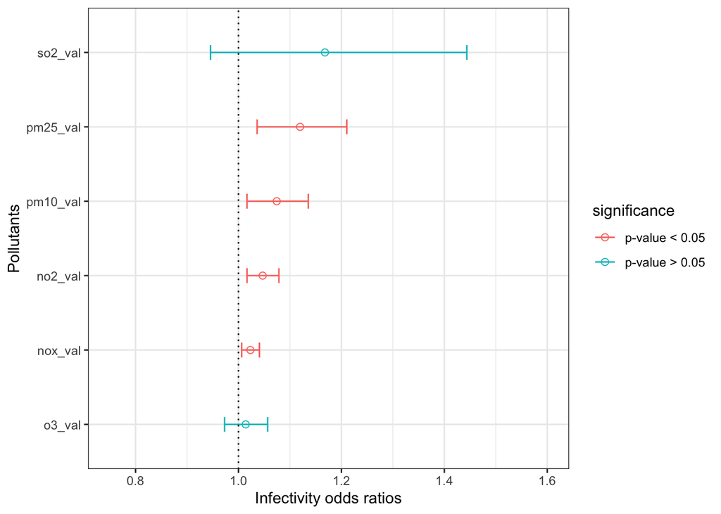

```r
ggplot(ukb_covid_onlyPoll, aes(x=reorder(names, OR), y=OR, color=significance)) +
    geom_point(fill="white", shape=21, size = 2) +
    geom_errorbar(aes(ymin=X2.5.., ymax=X97.5..),
                  width=.2,                    # Width of the error bars
                  position=position_dodge(.9)) +
  theme_bw() +
  geom_hline(yintercept = 1, linetype="dotted") +
  coord_flip()+ylab("Infectivity odds ratios") +
  xlab("Pollutants")+
  ylim(0.75, 1.6)
```

```r
ggsave('fig_out_v4/UKB_infectivityOR_bar.pdf')
```

## Aim 4: Identifying the main contributors of air pollution

We downloaded the original files in data_v4.  
We then deleted the irrelevant or repeated columns by hand, and saved in data output.

#### Analysis rationale:

First, we set out to explore how the main contributors of NOx and SO2 emissions relate with each other.  
Then we wanted to assess which emission source is best at predicting air pollution.

To deal with the multicollinearity and high dimensionality of these confounding variables we used two different approaches, based on previous air pollution studies (https://www.ncbi.nlm.nih.gov/pmc/articles/PMC6717171/ and https://www.sciencedirect.com/science/article/pii/S0048969714016647?via%3Dihub). First, we used a principal component analysis (PCA) approach to transform the original variables into a set of uncorrelated, mutually orthogonal components called principal components (PCs). PCs represent linear combinations of the original variables that provide information on the most meaningful parameter with minimum loss of original information.  
PCs were not estimated for gas consumption as only two variables were included in this analysis.

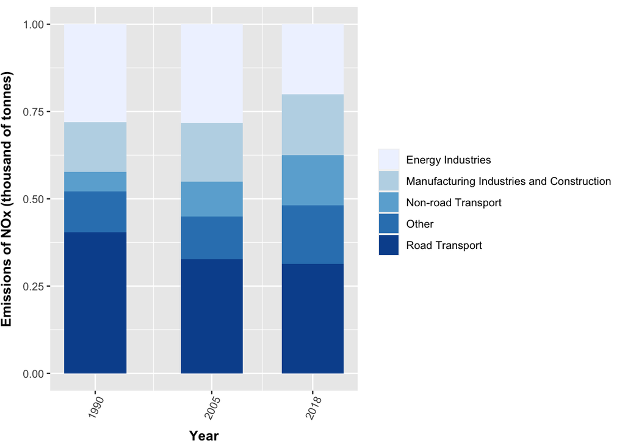

```r
NOx_emissions <- read.csv("data_v4/Main_NOx_emission_sector.csv")
library(ggplot2)
NOx.plot <- ggplot(data = NOx_emissions, mapping = aes(y = Emissions, x = Year, fill = Sector)) +
  geom_bar(stat = "identity", position = "fill", width = 8) +
  theme_gray() + scale_fill_brewer() +
  ylab("Emissions of NOx (thousand of tonnes)") +
  theme(
    axis.title.x = element_text(color="black", vjust=-0.35, face = "bold"),
    axis.title.y = element_text(color="black" , vjust=3, face = "bold"),
    axis.text.x = element_text(angle=65, vjust=0.6),
    plot.title = element_text(size=12, face="bold",
                              margin = margin(10, 10, 0, 0), hjust = 0.5,
                              vjust = 5),
    legend.title = element_blank())
# x axis
NOx.plot + scale_x_continuous(breaks = c(1990, 2005, 2018),labels=c(1990, 2005, 2018))
```

```r
ggsave("fig_out_v4/Main_NOx_emission_sector_V2.pdf")
```

The graph shows the contribution of nitrogen oxides emissions for each sector in the UK over the last three decades. “Road transport” refers to cumulative emissions recorded for various motor vehicles (buses, motorcycles, cars, LGV and HGV); “Other category” captures nitrogen oxides emissions from non-agriculture livestock such as domestic pets as well as non-agriculture fertilisers; “Non-road transport” represents emissions from residual transport sources (aviation, rail, shipping); “Manufacturing industries and construction” refers to cement and lime production as well as other industrial combustion; and “Energy industries” included emissions produced by power stations, miscellaneous commercial and industrial combustion, gas and coke production.

#### Supplementary Table 8. Main SO2 emission sources

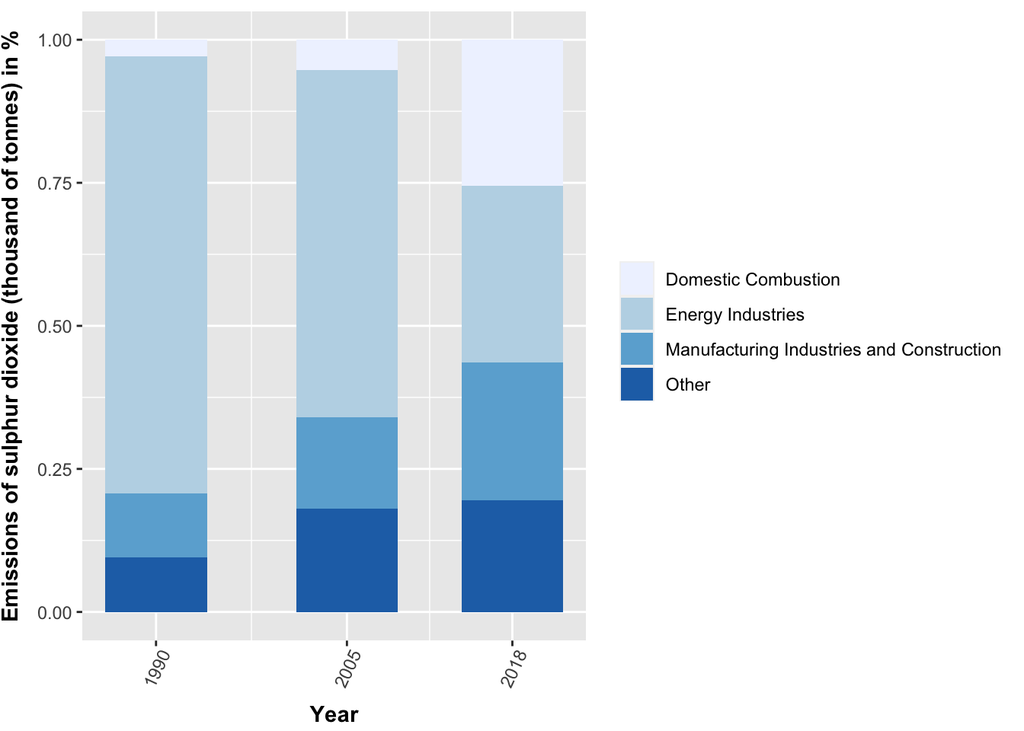

```r
So2_emissions <- read.csv("data_v4/Figure_SO2_sector.csv")
library(ggplot2)
SO2.plot <- ggplot(data = So2_emissions, mapping = aes(y = Emissions, x = Year, fill = Sector)) +
  geom_bar(stat = "identity", position = "fill", width = 8) +
  theme_gray() + scale_fill_brewer() +
  ylab("Emissions of sulphur dioxide (thousand of tonnes) in %") +
  theme(
    axis.title.x = element_text(color="black", vjust=-0.35, face = "bold"),
    axis.title.y = element_text(color="black" , vjust=3, face = "bold"),
    axis.text.x = element_text(angle=65, vjust=0.6),
    plot.title = element_text(size=12, face="bold",
                              margin = margin(10, 10, 0, 0), hjust = 0.5,
                              vjust = 5),
    legend.title = element_blank())
# x axis
SO2.plot + scale_x_continuous(breaks = c(1990, 2005, 2018),labels=c(1990, 2005, 2018))
```

```r
ggsave("fig_out_v4/Main_SO2_emission_sector_V2.pdf")
```

### Load and process the data

```r
LA_merged_dt = read.csv("data_output_v4/merged_covidAir_cov_dt_LA.csv")
LA_merged_code_dt = LA_merged_dt["Code"]
colnames(LA_merged_code_dt) <- "ons_code"
road_fuel_raw = read.csv("data_output_v4/clean_road_fuel_consumption2017.csv")
residuals_raw = read.csv("data_output_v4/clean_residual_consumption2017.csv", na.strings = "NA")
gas_raw = read.csv("data_output_v4/clean_gas_consumption2018.csv", na.strings = "NA")

print(paste("road_fuel_raw: ", colnames(road_fuel_raw)))
```

```
##  [1] "road_fuel_raw:  ons_code"
##  [2] "road_fuel_raw:  area"
##  [3] "road_fuel_raw:  personal.buses.Motorways"
##  [4] "road_fuel_raw:  personal.buses.A.roads"
##  [5] "road_fuel_raw:  personal.buses.Minor.roads"
##  [6] "road_fuel_raw:  personal.diesel.cars.Motorways"
##  [7] "road_fuel_raw:  personal.diesel.cars.A.roads"
##  [8] "road_fuel_raw:  personal.diesel.cars.Minor.roads"
##  [9] "road_fuel_raw:  personal.petrol.cars.Motorway"
## [10] "road_fuel_raw:  personal.petrol.cars.A.roads"
## [11] "road_fuel_raw:  personal.petrol.cars.Minor.roads"
## [12] "road_fuel_raw:  personal.motorcycles.Motorways"
## [13] "road_fuel_raw:  personal.motorcycles.A.roads"
## [14] "road_fuel_raw:  personal.motorcycles.Minor.roads"
## [15] "road_fuel_raw:  freight.HGV.Motorways"
## [16] "road_fuel_raw:  freight.HGV.A.roads"
## [17] "road_fuel_raw:  freight.HGV.Minor.roads"
## [18] "road_fuel_raw:  freight.diesel.LGV.Motorways"
## [19] "road_fuel_raw:  freight.diesel.LGV.A.roads"
## [20] "road_fuel_raw:  freight.diesel.LGV.Minor.roads"
## [21] "road_fuel_raw:  freight.petrol.LGV.Motorways"
## [22] "road_fuel_raw:  freight.petrol.LGV.A.roads"
## [23] "road_fuel_raw:  freight.petrol.LGV.Minor.roads"
```

```r
print(paste("residuals_raw: ", colnames(residuals_raw)))
```

```
##  [1] "residuals_raw:  ons_code"
##  [2] "residuals_raw:  area"
##  [3] "residuals_raw:  petroleum.Industrial"
##  [4] "residuals_raw:  petroleum.Domestic"
##  [5] "residuals_raw:  petroleum.Rail"
##  [6] "residuals_raw:  petroleum.Public.Administration"
##  [7] "residuals_raw:  petroleum.Commercial"
##  [8] "residuals_raw:  petroleum.Agriculture"
##  [9] "residuals_raw:  coal.Industrial.Commercial"
## [10] "residuals_raw:  coal.Domestic"
## [11] "residuals_raw:  coal.Rail"
## [12] "residuals_raw:  Manufactured.Solid.Fuels.Industrial"
## [13] "residuals_raw:  Manufactured.Solid.Fuels.Domestic"
## [14] "residuals_raw:  bioenergy"
```

Only keep the data with location in England and delete columns that contain more than 10% NA.

```r
road_fuel_dt = merge(LA_merged_code_dt, road_fuel_raw, by = "ons_code")
residuals_dt = merge(LA_merged_code_dt, residuals_raw, by = "ons_code")
gas_dt = merge(LA_merged_code_dt, gas_raw, by = "ons_code")

#keep track of deleted columns
road_fuel_rm = road_fuel_dt[,!sapply(road_fuel_dt, function(x) mean(is.na(x)))<0.1]
residuals_rm = residuals_dt[,!sapply(residuals_dt, function(x) mean(is.na(x)))<0.1]
gas_rm = gas_dt[,!sapply(gas_dt, function(x) mean(is.na(x)))<0.1]

#delete columns that contain more than 10% NA
road_fuel_dt = road_fuel_dt[,!sapply(road_fuel_dt, function(x) mean(is.na(x)))>0.1]
residuals_dt = residuals_dt[,!sapply(residuals_dt, function(x) mean(is.na(x)))>0.1]
gas_dt = gas_dt[,!sapply(gas_dt, function(x) mean(is.na(x)))>0.1]

# save
write.csv(road_fuel_dt, "data_output_v4/processed_road_fuel_consumption2017.csv")
write.csv(residuals_dt, "data_output_v4/processed_residual_consumption2017.csv")
write.csv(gas_dt, "data_output_v4/processed_road_gas_consumption2018.csv")
```

### PCA for variable grouping and multicollinearity issues

Read in and view the data (England only)

```r
fossilfuel_2017 = read.csv("data_output_v4/AQ_vs_fossilfuels_LA_England.csv")
head(fossilfuel_2017)
```

```
##   Number  ons_code     Region X.people.per.sq.km      Local.Authority   no2_val
## 1      1 E06000001 North East                997           Hartlepool 13.105737
## 2      2 E06000002 North East               2608        Middlesbrough 20.178191
## 3      3 E06000003 North East                558 Redcar and Cleveland  7.749542
## 4      4 E06000004 North East                962     Stockton-on-Tees 15.562038
## 5      5 E06000005 North East                540           Darlington 11.360341
## 6      6 E06000006 North West               1624               Halton 15.611062
##     o3_val   nox_val pm25_val pm10_val   so2_val Domestic.mean.gas.consumption
## 1 5.303858 17.730895 7.362821 11.50678 1.5755607                         12439
## 2 4.251802 29.296034 8.210541 12.56193 3.1332865                         12573
## 3 6.851500  9.983241 7.293137 12.85583 0.9988638                         12519
## 4 5.050632 21.440737 7.900856 12.25113 1.9343295                         12992
## 5 5.198811 15.098272 7.153221 11.12964 1.1290335                         13417
## 6 4.393569 21.642167 9.257343 13.26975 3.0365011                         11520
##   Non.domestic.mean.gas.consumption personal.buses.Motorways
```

[output cut: 97 more lines]

First thing to do here is to analyse the data distribution of the target or response variable (NO2, NOx, O3 and SO2 concentration). To do this, we will use the following functions:

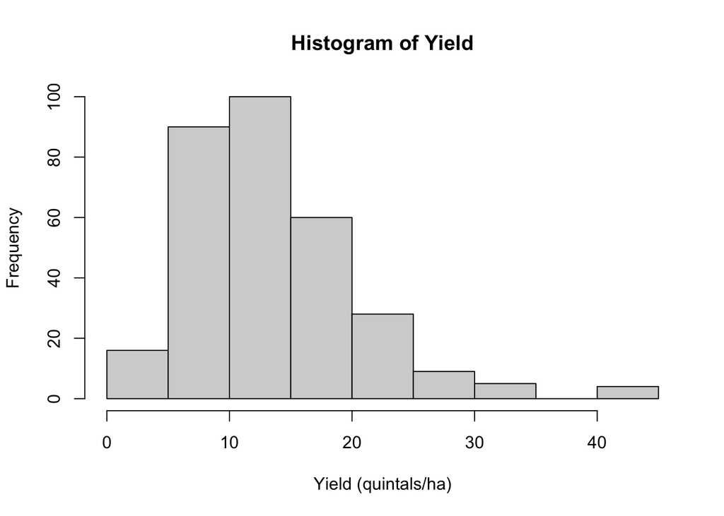

```r
hist(fossilfuel_2017$no2_val, main="Histogram of Yield", xlab="Yield (quintals/ha)")
```

```r
#qqnorm(fossilfuel_2017$no2_val, main="QQplot of NO2")
library(e1071)
skewness(fossilfuel_2017$no2_val)
```

```
## [1] NA
```

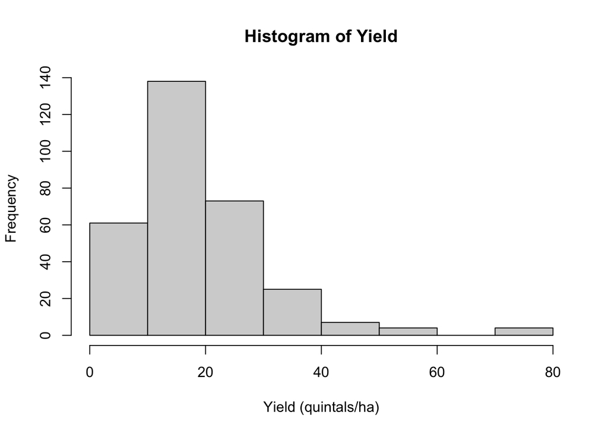

```r
hist(fossilfuel_2017$nox_val, main="Histogram of Yield", xlab="Yield (quintals/ha)")
```

```r
#qqnorm(fossilfuel_2017$nox_val, main="QQplot of NOx")
skewness(fossilfuel_2017$nox_val)
```

```
## [1] NA
```

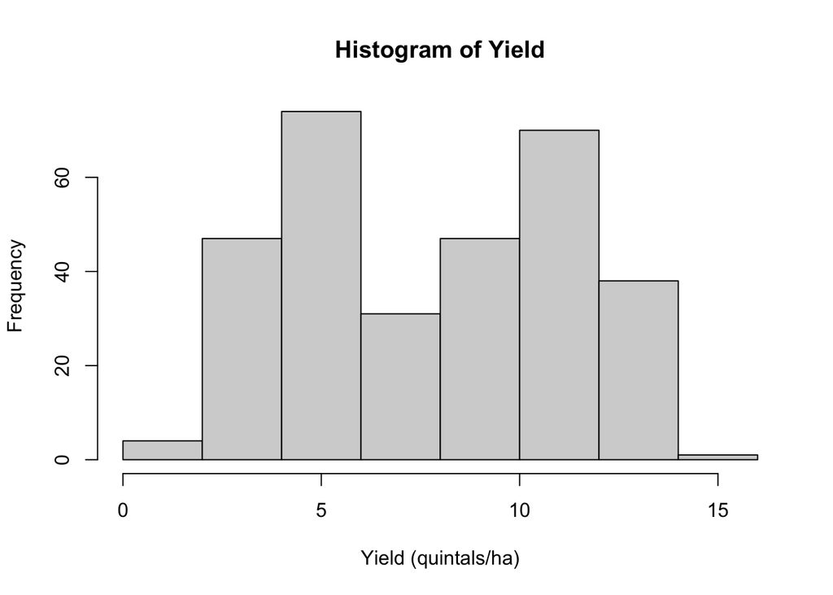

```r
hist(fossilfuel_2017$o3_val, main="Histogram of Yield", xlab="Yield (quintals/ha)")
```

```r
#qqnorm(fossilfuel_2017$o3_val, main="QQplot of O3")
skewness(fossilfuel_2017$o3_val)
```

```
## [1] NA
```

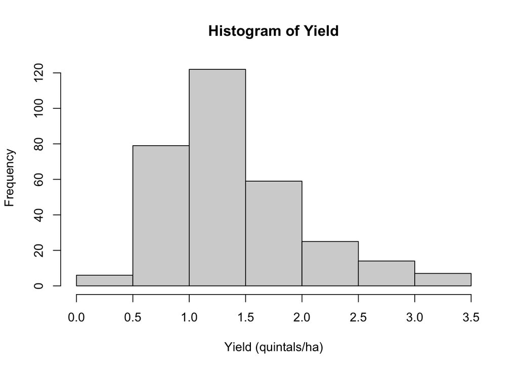

```r
hist(fossilfuel_2017$so2_val, main="Histogram of Yield", xlab="Yield (quintals/ha)")
```

```r
#qqnorm(fossilfuel_2017$so2_val, main="QQplot of SO2")
skewness(fossilfuel_2017$so2_val)
```

```
## [1] NA
```

For NO2, NOx, O3 and SO2, the histogram suggests that data is not normally distributed.

### Data formatting for PCA

One of the fundamental assumptions of linear modelling is the independence of predictors. Our independent variables show multicollinearity. We will adjust for multicollinearity by using a PCA approach. PCA is ran on the independent variables only, so we must first subset the data to only include predictors:

```r
# Before fititng the model, exlude missing data
fossilfuel_2017.omit <- na.omit(fossilfuel_2017)
# Create a dataset that only includes road transport independent variables
data_coll.road.clean <- fossilfuel_2017.omit[,14:34]
data.road.pca <- prcomp(data_coll.road.clean, center = TRUE, scale. = TRUE)
summary(data.road.pca)
```

```
## Importance of components:
##                           PC1    PC2     PC3     PC4     PC5     PC6     PC7
## Standard deviation     3.2200 2.4035 1.42388 1.19921 0.60912 0.53559 0.45432
## Proportion of Variance 0.4937 0.2751 0.09654 0.06848 0.01767 0.01366 0.00983
## Cumulative Proportion  0.4937 0.7688 0.86535 0.93383 0.95150 0.96516 0.97499
##                           PC8     PC9    PC10    PC11    PC12   PC13    PC14
## Standard deviation     0.3693 0.35149 0.27052 0.25962 0.22582 0.1586 0.13393
## Proportion of Variance 0.0065 0.00588 0.00348 0.00321 0.00243 0.0012 0.00085
## Cumulative Proportion  0.9815 0.98737 0.99085 0.99406 0.99649 0.9977 0.99854
##                           PC15    PC16    PC17    PC18    PC19     PC20
## Standard deviation     0.12209 0.11030 0.05132 0.02130 0.01884 0.007981
## Proportion of Variance 0.00071 0.00058 0.00013 0.00002 0.00002 0.000000
## Cumulative Proportion  0.99925 0.99983 0.99996 0.99998 1.00000 1.000000
##                            PC21
## Standard deviation     0.005863
## Proportion of Variance 0.000000
## Cumulative Proportion  1.000000
```

```r
# gas
data_coll.gas.clean <- fossilfuel_2017.omit[,12:13]
data.gas.pca <- prcomp(data_coll.gas.clean, center = TRUE, scale. = TRUE)
summary(data.gas.pca)
```

```
## Importance of components:
##                           PC1    PC2
## Standard deviation     1.0833 0.9091
## Proportion of Variance 0.5867 0.4133
## Cumulative Proportion  0.5867 1.0000
```

```r
# Residual fuels
data_coll.rsd.clean <- fossilfuel_2017.omit[,35:43]
data.rsd.pca <- prcomp(data_coll.rsd.clean, center = TRUE, scale. = TRUE)
summary(data.rsd.pca)
```

```
## Importance of components:
##                           PC1    PC2    PC3     PC4    PC5    PC6     PC7
## Standard deviation     2.1275 1.0342 0.9684 0.94606 0.8044 0.6782 0.56912
## Proportion of Variance 0.5029 0.1188 0.1042 0.09945 0.0719 0.0511 0.03599
## Cumulative Proportion  0.5029 0.6217 0.7259 0.82539 0.8973 0.9484 0.98438
##                            PC8     PC9
## Standard deviation     0.32078 0.19400
## Proportion of Variance 0.01143 0.00418
## Cumulative Proportion  0.99582 1.00000
```

### Models with PCs for fossil fuel consumption data

```r
## Run model with PC1 and PC2 from each data set
# NO2 glm
summary(mod.pca.no2 <- glm( no2_val~X.people.per.sq.km + data.road.pca$x[,1:2] + data.rsd.pca$x[,1:2] + Domestic.mean.gas.consumption + Non.domestic.mean.gas.consumption,
                       family  = Gamma(link = "log"), data= fossilfuel_2017.omit)) #road and rsd is significant
```

```
##
## Call:
## glm(formula = no2_val ~ X.people.per.sq.km + data.road.pca$x[,
##     1:2] + data.rsd.pca$x[, 1:2] + Domestic.mean.gas.consumption +
##     Non.domestic.mean.gas.consumption, family = Gamma(link = "log"),
##     data = fossilfuel_2017.omit)
##
## Deviance Residuals:
##      Min        1Q    Median        3Q       Max
## -1.43119  -0.20277   0.01158   0.15501   1.50927
##
## Coefficients:
##                                     Estimate Std. Error t value Pr(>|t|)
## (Intercept)                        2.437e+00  1.844e-01  13.211   <2e-16 ***
## X.people.per.sq.km                 9.517e-05  7.982e-06  11.923   <2e-16 ***
## data.road.pca$x[, 1:2]PC1          6.372e-02  7.205e-03   8.844   <2e-16 ***
## data.road.pca$x[, 1:2]PC2         -8.225e-03  8.167e-03  -1.007    0.315
## data.rsd.pca$x[, 1:2]PC1          -1.216e-01  1.215e-02 -10.011   <2e-16 ***
## data.rsd.pca$x[, 1:2]PC2          -1.152e-02  1.719e-02  -0.670    0.503
## Domestic.mean.gas.consumption     -5.125e-06  1.294e-05  -0.396    0.692
## Non.domestic.mean.gas.consumption -4.402e-09  3.219e-08  -0.137    0.891
## ---
## Signif. codes:  0 '***' 0.001 '**' 0.01 '*' 0.05 '.' 0.1 ' ' 1
##
## (Dispersion parameter for Gamma family taken to be 0.09243599)
##
##     Null deviance: 71.050  on 299  degrees of freedom
## Residual deviance: 27.227  on 292  degrees of freedom
## AIC: 1650.3
##
## Number of Fisher Scoring iterations: 11
```

```r
vif(mod.pca.no2) # VIF <3
```

```
##                                       GVIF Df GVIF^(1/(2*Df))
## X.people.per.sq.km                1.486531  1        1.219234
## data.road.pca$x[, 1:2]            2.118656  2        1.206466
## data.rsd.pca$x[, 1:2]             2.202936  2        1.218289
## Domestic.mean.gas.consumption     1.261858  1        1.123324
## Non.domestic.mean.gas.consumption 1.111511  1        1.054282
```

```r
# NOx glm
summary(mod.pca.nox <- glm( nox_val~X.people.per.sq.km + data.road.pca$x[,1:2] + data.rsd.pca$x[,1:2] + Domestic.mean.gas.consumption + Non.domestic.mean.gas.consumption,
                       family  = Gamma(link = "log"), data= fossilfuel_2017.omit)) #road and rsd is significant
```

```
##
## Call:
## glm(formula = nox_val ~ X.people.per.sq.km + data.road.pca$x[,
##     1:2] + data.rsd.pca$x[, 1:2] + Domestic.mean.gas.consumption +
##     Non.domestic.mean.gas.consumption, family = Gamma(link = "log"),
##     data = fossilfuel_2017.omit)
##
## Deviance Residuals:
##      Min        1Q    Median        3Q       Max
## -1.55879  -0.23926  -0.00143   0.16741   1.96634
##
## Coefficients:
##                                     Estimate Std. Error t value Pr(>|t|)
## (Intercept)                        2.784e+00  2.196e-01  12.678  < 2e-16 ***
## X.people.per.sq.km                 1.147e-04  9.504e-06  12.066  < 2e-16 ***
## data.road.pca$x[, 1:2]PC1          6.961e-02  8.579e-03   8.114 1.37e-14 ***
## data.road.pca$x[, 1:2]PC2         -8.912e-03  9.724e-03  -0.916    0.360
## data.rsd.pca$x[, 1:2]PC1          -1.317e-01  1.446e-02  -9.105  < 2e-16 ***
## data.rsd.pca$x[, 1:2]PC2          -1.306e-02  2.047e-02  -0.638    0.524
## Domestic.mean.gas.consumption     -9.659e-06  1.541e-05  -0.627    0.531
## Non.domestic.mean.gas.consumption -5.029e-09  3.833e-08  -0.131    0.896
## ---
## Signif. codes:  0 '***' 0.001 '**' 0.01 '*' 0.05 '.' 0.1 ' ' 1
##
## (Dispersion parameter for Gamma family taken to be 0.1310457)
##
##     Null deviance: 94.264  on 299  degrees of freedom
## Residual deviance: 34.589  on 292  degrees of freedom
## AIC: 1909.3
##
## Number of Fisher Scoring iterations: 12
```

```r
vif(mod.pca.nox) # VIF <3
```

```
##                                       GVIF Df GVIF^(1/(2*Df))
## X.people.per.sq.km                1.486531  1        1.219234
## data.road.pca$x[, 1:2]            2.118656  2        1.206466
## data.rsd.pca$x[, 1:2]             2.202936  2        1.218289
## Domestic.mean.gas.consumption     1.261858  1        1.123324
## Non.domestic.mean.gas.consumption 1.111511  1        1.054282
```

```r
# O3
summary(mod.pca.o3 <- glm( o3_val~X.people.per.sq.km + data.road.pca$x[,1:2] + data.rsd.pca$x[,1:2] + Domestic.mean.gas.consumption + Non.domestic.mean.gas.consumption,
                       family  = "gaussian", data= fossilfuel_2017.omit)) # road, rsd and non-domestic gas
```

```
##
## Call:
## glm(formula = o3_val ~ X.people.per.sq.km + data.road.pca$x[,
##     1:2] + data.rsd.pca$x[, 1:2] + Domestic.mean.gas.consumption +
##     Non.domestic.mean.gas.consumption, family = "gaussian", data = fossilfuel_2017.omit)
##
## Deviance Residuals:
##     Min       1Q   Median       3Q      Max
## -7.6768  -2.7207   0.1503   2.7315   9.3601
##
## Coefficients:
##                                     Estimate Std. Error t value Pr(>|t|)
## (Intercept)                        8.925e+00  1.951e+00   4.575 7.06e-06 ***
## X.people.per.sq.km                -2.922e-04  8.443e-05  -3.461 0.000619 ***
## data.road.pca$x[, 1:2]PC1         -2.078e-01  7.622e-02  -2.727 0.006779 **
## data.road.pca$x[, 1:2]PC2          4.271e-02  8.639e-02   0.494 0.621387
## data.rsd.pca$x[, 1:2]PC1           3.273e-01  1.285e-01   2.548 0.011355 *
## data.rsd.pca$x[, 1:2]PC2          -4.492e-01  1.819e-01  -2.470 0.014089 *
## Domestic.mean.gas.consumption      2.954e-05  1.369e-04   0.216 0.829293
## Non.domestic.mean.gas.consumption -1.455e-06  3.405e-07  -4.272 2.63e-05 ***
## ---
## Signif. codes:  0 '***' 0.001 '**' 0.01 '*' 0.05 '.' 0.1 ' ' 1
##
## (Dispersion parameter for gaussian family taken to be 10.34288)
##
##     Null deviance: 3556.1  on 299  degrees of freedom
## Residual deviance: 3020.1  on 292  degrees of freedom
## AIC: 1562.1
##
## Number of Fisher Scoring iterations: 2
```

```r
vif(mod.pca.o3) # VIF <3
```

```
##                                       GVIF Df GVIF^(1/(2*Df))
## X.people.per.sq.km                1.486531  1        1.219234
## data.road.pca$x[, 1:2]            2.118656  2        1.206466
## data.rsd.pca$x[, 1:2]             2.202936  2        1.218289
## Domestic.mean.gas.consumption     1.261858  1        1.123324
## Non.domestic.mean.gas.consumption 1.111511  1        1.054282
```

```r
# SO2
summary(mod.pca.so2 <- glm( so2_val~X.people.per.sq.km + data.road.pca$x[,1:2] + data.rsd.pca$x[,1:2] + Domestic.mean.gas.consumption + Non.domestic.mean.gas.consumption,
                       family  = Gamma(link = "log"), data= fossilfuel_2017.omit)) # all significant
```

```
##
## Call:
## glm(formula = so2_val ~ X.people.per.sq.km + data.road.pca$x[,
##     1:2] + data.rsd.pca$x[, 1:2] + Domestic.mean.gas.consumption +
##     Non.domestic.mean.gas.consumption, family = Gamma(link = "log"),
##     data = fossilfuel_2017.omit)
##
## Deviance Residuals:
##      Min        1Q    Median        3Q       Max
## -1.05261  -0.24711  -0.04019   0.15673   0.83290
##
## Coefficients:
##                                     Estimate Std. Error t value Pr(>|t|)
## (Intercept)                        7.901e-01  1.951e-01   4.050 6.58e-05 ***
## X.people.per.sq.km                 4.349e-05  8.444e-06   5.150 4.79e-07 ***
## data.road.pca$x[, 1:2]PC1          5.381e-02  7.622e-03   7.059 1.22e-11 ***
## data.road.pca$x[, 1:2]PC2         -7.448e-03  8.639e-03  -0.862 0.389349
## data.rsd.pca$x[, 1:2]PC1          -1.034e-01  1.285e-02  -8.050 2.11e-14 ***
## data.rsd.pca$x[, 1:2]PC2           4.960e-02  1.819e-02   2.727 0.006785 **
## Domestic.mean.gas.consumption     -4.704e-05  1.369e-05  -3.436 0.000675 ***
## Non.domestic.mean.gas.consumption  1.070e-07  3.406e-08   3.141 0.001857 **
## ---
## Signif. codes:  0 '***' 0.001 '**' 0.01 '*' 0.05 '.' 0.1 ' ' 1
##
## (Dispersion parameter for Gamma family taken to be 0.1034392)
##
##     Null deviance: 49.192  on 299  degrees of freedom
## Residual deviance: 30.357  on 292  degrees of freedom
## AIC: 346.66
##
## Number of Fisher Scoring iterations: 7
```

```r
vif(mod.pca.so2) # VIF <3
```

```
##                                       GVIF Df GVIF^(1/(2*Df))
## X.people.per.sq.km                1.486531  1        1.219234
## data.road.pca$x[, 1:2]            2.118656  2        1.206466
## data.rsd.pca$x[, 1:2]             2.202936  2        1.218289
## Domestic.mean.gas.consumption     1.261858  1        1.123324
## Non.domestic.mean.gas.consumption 1.111511  1        1.054282
```

### Calculate OR for principal component models:

OR ratio graphs for PCA models

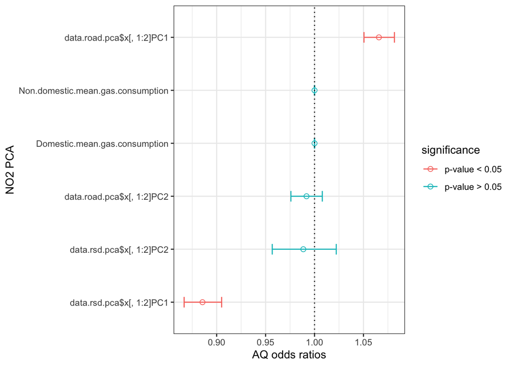

```r
# Calculate odds ratio (OR) for plotting
# Format OR
NO2_pca_odds = data.frame(cbind(exp(cbind(OR = coef(mod.pca.no2), confint(mod.pca.no2))), p_value = summary(mod.pca.no2)$coefficients[,4]))
NOx_pca_odds = data.frame(cbind(exp(cbind(OR = coef(mod.pca.nox), confint(mod.pca.nox))), p_value = summary(mod.pca.nox)$coefficients[,4]))
O3_pca_odds = data.frame(cbind(exp(cbind(OR = coef(mod.pca.o3), confint(mod.pca.o3))), p_value = summary(mod.pca.o3)$coefficients[,4]))
SO2_pca_odds = data.frame(cbind(exp(cbind(OR = coef(mod.pca.so2), confint(mod.pca.so2))), p_value = summary(mod.pca.no2)$coefficients[,4]))

#now delete the rows that you dont want - Intercepts
NO2_pca_odds_clean = NO2_pca_odds[-c(1,2),]
NOx_pca_odds_clean = NOx_pca_odds[-c(1,2),]
O3_pca_odds_clean = O3_pca_odds[-c(1,2),]
SO2_pca_odds_clean = SO2_pca_odds[-c(1,2),]

#make a df just with the pollutants
NO2_pca_onlyPoll = data.frame(NO2_pca_odds_clean)
NOx_pca_onlyPoll = data.frame(NOx_pca_odds_clean)
O3_pca_onlyPoll = data.frame(O3_pca_odds_clean)
SO2_pca_onlyPoll = data.frame(SO2_pca_odds_clean)

# Sort data for NO2
NO2_pca_onlyPoll$names = row.names(NO2_pca_onlyPoll)
NO2_pca_onlyPoll$significance = "p-value > 0.05"
NO2_pca_onlyPoll$significance[NO2_pca_onlyPoll$p_value < 0.05] <- "p-value < 0.05"
# Sort data for NOx
NOx_pca_onlyPoll$names = row.names(NOx_pca_onlyPoll)
NOx_pca_onlyPoll$significance = "p-value > 0.05"
NOx_pca_onlyPoll$significance[NOx_pca_onlyPoll$p_value < 0.05] <- "p-value < 0.05"
# Sort data for O3
O3_pca_onlyPoll$names = row.names(O3_pca_onlyPoll)
O3_pca_onlyPoll$significance = "p-value > 0.05"
O3_pca_onlyPoll$significance[O3_pca_onlyPoll$p_value < 0.05] <- "p-value < 0.05"
# Sort data for SO2
SO2_pca_onlyPoll$names = row.names(SO2_pca_onlyPoll)
SO2_pca_onlyPoll$significance = "p-value > 0.05"
SO2_pca_onlyPoll$significance[SO2_pca_onlyPoll$p_value < 0.05] <- "p-value < 0.05"

# plot for NO2 PCA
ggplot(NO2_pca_onlyPoll, aes(x=reorder(names, OR), y=OR, color= significance)) +
    geom_point(fill="white", shape=21, size = 2) +
    geom_errorbar(aes(ymin=X2.5.., ymax=X97.5..),
                  width=.2,                    # Width of the error bars
                  position=position_dodge(.9)) +
  theme_bw() +
  geom_hline(yintercept = 1, linetype="dotted") +
  coord_flip()+ylab("AQ odds ratios") +
  xlab("NO2 PCA")
```

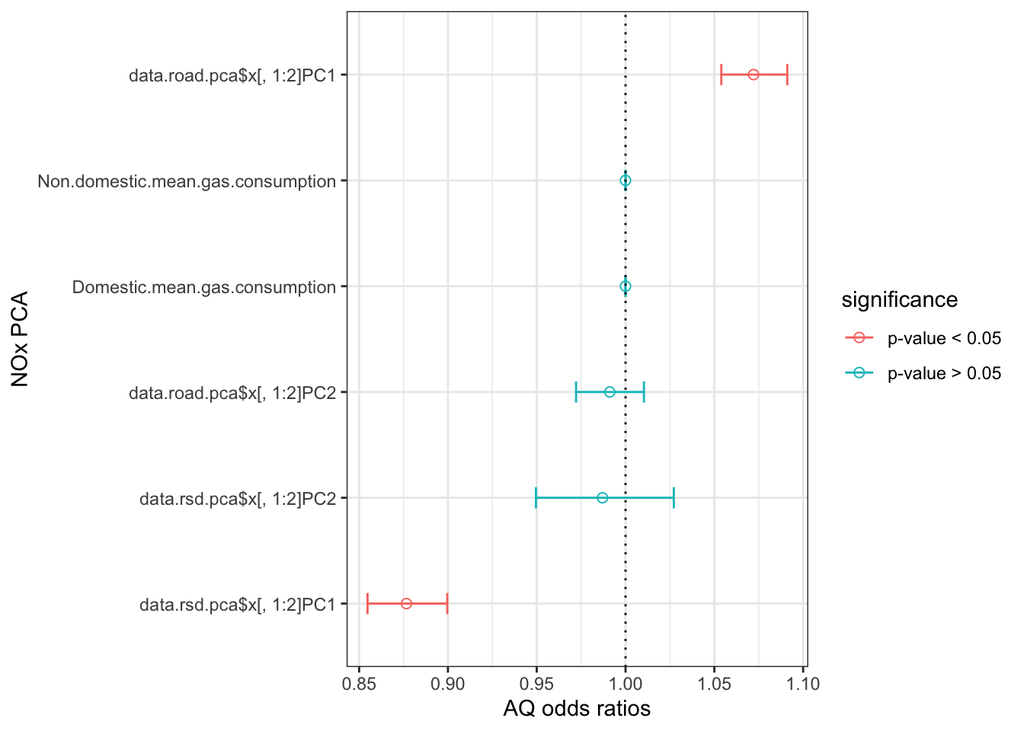

```r
# plot for NOx PCA
ggplot(NOx_pca_onlyPoll, aes(x=reorder(names, OR), y=OR, color= significance)) +
    geom_point(fill="white", shape=21, size = 2) +
    geom_errorbar(aes(ymin=X2.5.., ymax=X97.5..),
                  width=.2,                    # Width of the error bars
                  position=position_dodge(.9)) +
  theme_bw() +
  geom_hline(yintercept = 1, linetype="dotted") +
  coord_flip()+ylab("AQ odds ratios") +
  xlab("NOx PCA")
```

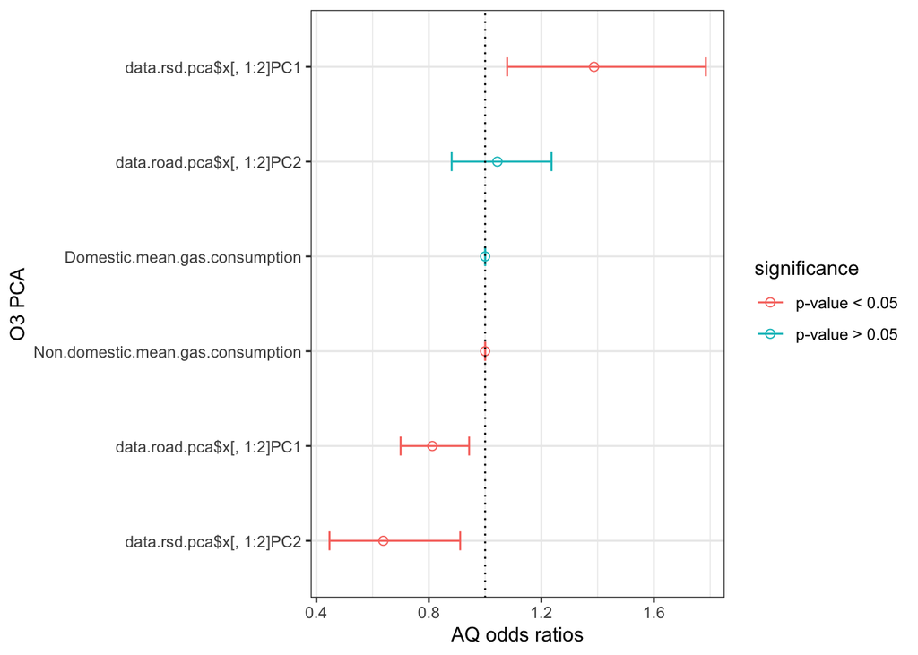

```r
# plot for O3 PCA
ggplot(O3_pca_onlyPoll, aes(x=reorder(names, OR), y=OR, color= significance)) +
    geom_point(fill="white", shape=21, size = 2) +
    geom_errorbar(aes(ymin=X2.5.., ymax=X97.5..),
                  width=.2,                    # Width of the error bars
                  position=position_dodge(.9)) +
  theme_bw() +
  geom_hline(yintercept = 1, linetype="dotted") +
  coord_flip()+ylab("AQ odds ratios") +
  xlab("O3 PCA")
```

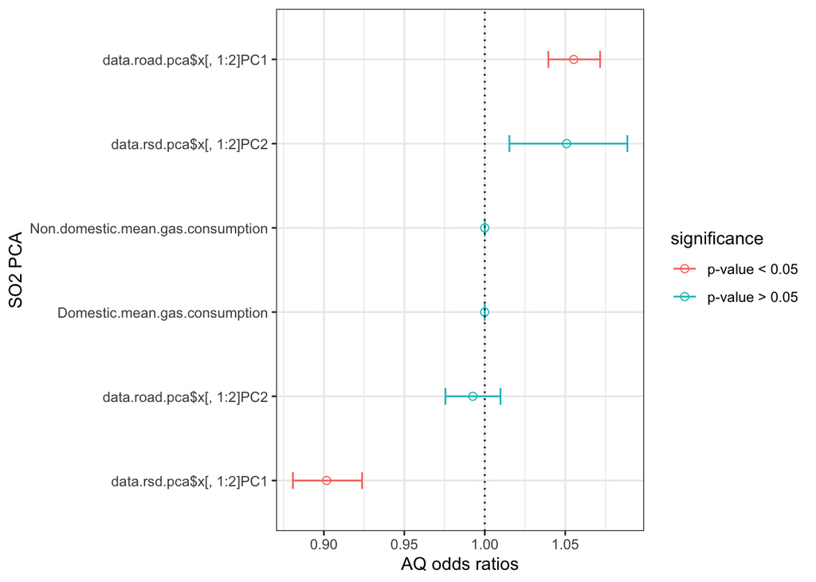

```r
# plot for SO2 PCA
ggplot(SO2_pca_onlyPoll, aes(x=reorder(names, OR), y=OR, color= significance)) +
    geom_point(fill="white", shape=21, size = 2) +
    geom_errorbar(aes(ymin=X2.5.., ymax=X97.5..),
                  width=.2,                    # Width of the error bars
                  position=position_dodge(.9)) +
  theme_bw() +
  geom_hline(yintercept = 1, linetype="dotted") +
  coord_flip()+ylab("AQ odds ratios") +
  xlab("SO2 PCA")
```

#### Supplementary Table 9. Summary of the generalised linear models based on principal components of the effect of fossil fuel consumption on air pollutant levels

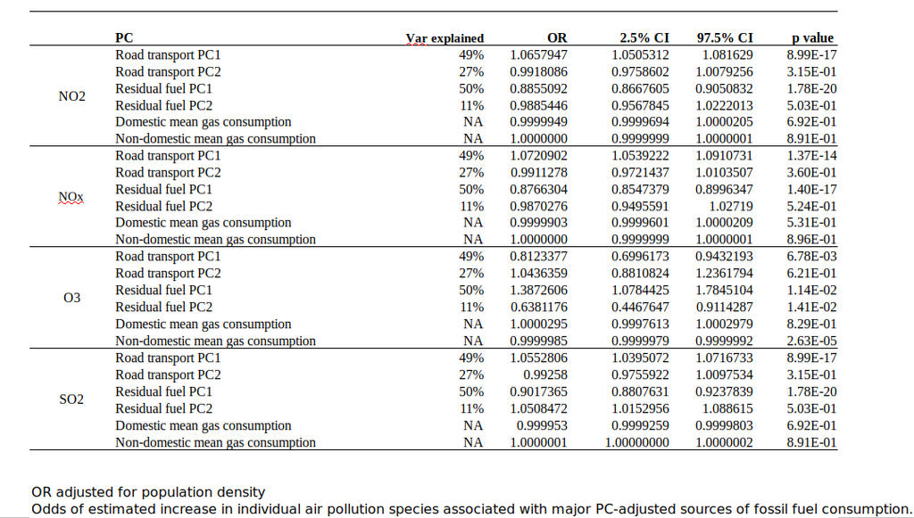

PCA-adjusted odds ratios for estimated increase of individual air pollutant concentrations according to levels of fuel consumption from road transport, consumption of residual fuels and gas combustion. PCs were not estimated for gas consumption as only two variables were included in the analysis. We fit generalized linear models of the gamma family (log link) to NO2, NOx and SO2 data after testing assumptions of linearity, multivariate normality and homoscedasticity. A generalized linear model of the gaussian family was fitted to O3 data. Results were adjusted for population density in England. Abbreviations: PC, principal component; Var explained, percentage of variance explained; OR, odds ratio; CI, confidence interval; NO2, nitrogen dioxide; NOx, nitrogen oxides; O3, ozone; SO2, sulphur dioxide; NA, Not available, PC, principal components.

### Iterative stepwise regression

#### Aim: Determine contribution of individual fuel-burning sources after variable selection

We will start by looking at NO2. Fitting the gamma identity glm (link = “identity”) to NO2 data throws a lot of warnings and terminates with an overflow. This could be because the identity function is not guaranteed to map the linear predictor to a positive real number, yielding a valid mean parameter. For this reason, we will need to use the log link function in the Gamma family as this forces the predictions/output to “respect the domain” by ensuring all predicted values are positive.

```r
# Road transport - log link is used
summary(model_NO2_gamma <- glm(data = fossilfuel_2017.omit, no2_val ~ X.people.per.sq.km + personal.buses.A.roads + personal.buses.Minor.roads + personal.diesel.cars.Motorways + personal.buses.Motorways + personal.diesel.cars.A.roads + personal.diesel.cars.Minor.roads + personal.petrol.cars.Motorway + personal.petrol.cars.A.roads + personal.petrol.cars.Minor.roads + personal.motorcycles.Motorways + personal.motorcycles.A.roads + personal.motorcycles.Minor.roads + freight.HGV.Motorways + freight.HGV.A.roads + freight.HGV.Minor.roads + freight.diesel.LGV.Motorways + freight.diesel.LGV.A.roads + freight.diesel.LGV.Minor.roads + freight.petrol.LGV.Motorways + freight.petrol.LGV.A.roads + freight.petrol.LGV.Minor.roads, family  = Gamma(link = "log")))
```

```
##
## Call:
## glm(formula = no2_val ~ X.people.per.sq.km + personal.buses.A.roads +
##     personal.buses.Minor.roads + personal.diesel.cars.Motorways +
##     personal.buses.Motorways + personal.diesel.cars.A.roads +
##     personal.diesel.cars.Minor.roads + personal.petrol.cars.Motorway +
##     personal.petrol.cars.A.roads + personal.petrol.cars.Minor.roads +
##     personal.motorcycles.Motorways + personal.motorcycles.A.roads +
##     personal.motorcycles.Minor.roads + freight.HGV.Motorways +
##     freight.HGV.A.roads + freight.HGV.Minor.roads + freight.diesel.LGV.Motorways +
##     freight.diesel.LGV.A.roads + freight.diesel.LGV.Minor.roads +
##     freight.petrol.LGV.Motorways + freight.petrol.LGV.A.roads +
##     freight.petrol.LGV.Minor.roads, family = Gamma(link = "log"),
##     data = fossilfuel_2017.omit)
##
## Deviance Residuals:
##      Min        1Q    Median        3Q       Max
## -1.36915  -0.17130   0.02453   0.14542   1.29314
##
## Coefficients:
##                                    Estimate Std. Error t value Pr(>|t|)
## (Intercept)                       2.357e+00  4.010e-02  58.795  < 2e-16 ***
## X.people.per.sq.km                6.921e-05  1.286e-05   5.381 1.58e-07 ***
## personal.buses.A.roads           -3.024e-05  3.477e-05  -0.870  0.38528
## personal.buses.Minor.roads       -1.096e-05  3.074e-05  -0.357  0.72170
## personal.diesel.cars.Motorways   -5.696e-05  6.922e-05  -0.823  0.41127
## personal.buses.Motorways         -2.168e-04  2.064e-04  -1.051  0.29434
## personal.diesel.cars.A.roads     -7.197e-05  5.405e-05  -1.331  0.18412
## personal.diesel.cars.Minor.roads  1.261e-04  1.198e-04   1.053  0.29330
## personal.petrol.cars.Motorway     7.678e-05  9.567e-05   0.803  0.42294
## personal.petrol.cars.A.roads      7.122e-05  4.771e-05   1.493  0.13667
## personal.petrol.cars.Minor.roads -1.161e-04  9.906e-05  -1.172  0.24211
## personal.motorcycles.Motorways    1.838e-03  6.785e-04   2.709  0.00717 **
## personal.motorcycles.A.roads      2.609e-04  2.925e-04   0.892  0.37316
## personal.motorcycles.Minor.roads  1.371e-05  3.703e-04   0.037  0.97049
## freight.HGV.Motorways             2.573e-06  4.993e-06   0.515  0.60675
## freight.HGV.A.roads               1.277e-06  4.487e-06   0.285  0.77622
## freight.HGV.Minor.roads          -4.999e-05  9.174e-05  -0.545  0.58628
## freight.diesel.LGV.Motorways     -9.037e-06  3.581e-04  -0.025  0.97989
## freight.diesel.LGV.A.roads        8.356e-05  8.065e-05   1.036  0.30105
## freight.diesel.LGV.Minor.roads   -1.024e-03  3.557e-04  -2.879  0.00430 **
## freight.petrol.LGV.Motorways      1.264e-04  1.265e-02   0.010  0.99203
## freight.petrol.LGV.A.roads       -2.971e-03  2.689e-03  -1.105  0.27020
## freight.petrol.LGV.Minor.roads    2.718e-02  8.926e-03   3.044  0.00255 **
## ---
## Signif. codes:  0 '***' 0.001 '**' 0.01 '*' 0.05 '.' 0.1 ' ' 1
##
## (Dispersion parameter for Gamma family taken to be 0.08175415)
##
##     Null deviance: 71.050  on 299  degrees of freedom
## Residual deviance: 24.877  on 277  degrees of freedom
## AIC: 1652.9
##
## Number of Fisher Scoring iterations: 8
```

In the dev residuals section, we see that 1Q and 3Q are not perfectly symmetrical as we are not log transforming our data so there is some sort of skewness. We also get an AIC of 1652. The high AIC value could be a consequence of a large number of explanatory variables included in the model: variable selection is required to minimise noise.

To test interdependence of factors we will assess the VIF of each road transport predictor included in the original model. Based on that, we will sequentially drop the predictors with the highest VIF until each VIF is less than 5.

```r
library(car)
vif(model_NO2_gamma)
```

```
##               X.people.per.sq.km           personal.buses.A.roads
##                         4.364386                         8.658227
##       personal.buses.Minor.roads   personal.diesel.cars.Motorways
##                         5.278376                      1813.546278
##         personal.buses.Motorways     personal.diesel.cars.A.roads
##                        13.674013                       665.083797
## personal.diesel.cars.Minor.roads    personal.petrol.cars.Motorway
##                      2478.069220                      1739.764191
##     personal.petrol.cars.A.roads personal.petrol.cars.Minor.roads
##                       657.078903                      2523.720217
##   personal.motorcycles.Motorways     personal.motorcycles.A.roads
##                        10.635740                        12.440160
## personal.motorcycles.Minor.roads            freight.HGV.Motorways
##                        10.337500                        17.214787
##              freight.HGV.A.roads          freight.HGV.Minor.roads
##                         4.172695                        17.478741
##     freight.diesel.LGV.Motorways       freight.diesel.LGV.A.roads
##                     14314.830468                       551.977298
##   freight.diesel.LGV.Minor.roads     freight.petrol.LGV.Motorways
##                      5702.510145                     14486.032195
##       freight.petrol.LGV.A.roads   freight.petrol.LGV.Minor.roads
##                       589.010803                      5553.482992
```

```r
summary(model_NO2_gamma.vif2 <- glm(data = fossilfuel_2017.omit, no2_val ~ X.people.per.sq.km + personal.buses.A.roads + personal.motorcycles.Motorways + personal.motorcycles.A.roads + personal.motorcycles.Minor.roads + freight.HGV.Motorways + freight.HGV.A.roads, family  = Gamma(link = "log")))
```

```
##
## Call:
## glm(formula = no2_val ~ X.people.per.sq.km + personal.buses.A.roads +
##     personal.motorcycles.Motorways + personal.motorcycles.A.roads +
##     personal.motorcycles.Minor.roads + freight.HGV.Motorways +
##     freight.HGV.A.roads, family = Gamma(link = "log"), data = fossilfuel_2017.omit)
##
## Deviance Residuals:
##      Min        1Q    Median        3Q       Max
## -1.46769  -0.23269  -0.00132   0.17465   1.55628
##
## Coefficients:
##                                    Estimate Std. Error t value Pr(>|t|)
## (Intercept)                       2.318e+00  4.271e-02  54.261  < 2e-16 ***
## X.people.per.sq.km                1.189e-04  1.183e-05  10.051  < 2e-16 ***
## personal.buses.A.roads            7.821e-05  3.017e-05   2.593  0.01001 *
## personal.motorcycles.Motorways    9.132e-04  3.907e-04   2.338  0.02008 *
## personal.motorcycles.A.roads     -6.207e-04  1.854e-04  -3.348  0.00092 ***
## personal.motorcycles.Minor.roads  1.899e-04  2.036e-04   0.933  0.35158
## freight.HGV.Motorways             1.345e-06  2.288e-06   0.588  0.55709
## freight.HGV.A.roads              -6.589e-06  3.367e-06  -1.957  0.05128 .
## ---
## Signif. codes:  0 '***' 0.001 '**' 0.01 '*' 0.05 '.' 0.1 ' ' 1
##
## (Dispersion parameter for Gamma family taken to be 0.1160752)
##
##     Null deviance: 71.050  on 299  degrees of freedom
## Residual deviance: 34.457  on 292  degrees of freedom
## AIC: 1722.2
##
## Number of Fisher Scoring iterations: 7
```

```r
vif(model_NO2_gamma.vif2) # VIF <5
```

```
##               X.people.per.sq.km           personal.buses.A.roads
##                         2.601107                         4.589445
##   personal.motorcycles.Motorways     personal.motorcycles.A.roads
##                         2.483397                         3.520010
## personal.motorcycles.Minor.roads            freight.HGV.Motorways
##                         2.200378                         2.546692
##              freight.HGV.A.roads
##                         1.654252
```

The model above only includes predictors displaying modest collinearity. However, it must be noted that the AIC penalises models with multiple variables. Therefore, we will apply a stepwise regression method to only include those variables that have an effect on NO2 concentration in our final model. To check that multicollinearity is accounted for in the absence of VIF testing, we will run stepwise regression on the VIF-corrected and original model and compare the results.

```r
### Define full and null models and do step procedure
model_0_glm.gamma <- glm(no2_val ~ 1, data = fossilfuel_2017.omit, family = Gamma(link = "log"))
step(model_0_glm.gamma, direction = "both", scope = formula(model_NO2_gamma, test = "Chisq"))
```

```
## Start:  AIC=1931.38
## no2_val ~ 1
##
##                                    Df Deviance    AIC
## + X.people.per.sq.km                1   40.079 1812.6
## + personal.buses.A.roads            1   51.658 1857.7
## + personal.motorcycles.A.roads      1   61.171 1894.8
## + personal.motorcycles.Minor.roads  1   63.913 1905.5
## + freight.HGV.A.roads               1   65.739 1912.7
## + freight.petrol.LGV.Minor.roads    1   68.848 1924.8
## + freight.diesel.LGV.A.roads        1   69.364 1926.8
## + personal.buses.Minor.roads        1   69.675 1928.0
## + personal.petrol.cars.Minor.roads  1   69.747 1928.3
## + freight.diesel.LGV.Minor.roads    1   70.108 1929.7
## + personal.diesel.cars.A.roads      1   70.500 1931.2
## <none>                                  71.050 1931.4
## + personal.diesel.cars.Minor.roads  1   70.716 1932.1
## + freight.HGV.Motorways             1   70.936 1932.9
## + personal.buses.Motorways          1   70.979 1933.1
## + freight.petrol.LGV.Motorways      1   71.007 1933.2
## + personal.diesel.cars.Motorways    1   71.009 1933.2
## + freight.diesel.LGV.Motorways      1   71.015 1933.2
## + personal.petrol.cars.Motorway     1   71.022 1933.3
## + freight.HGV.Minor.roads           1   71.027 1933.3
## + personal.motorcycles.Motorways    1   71.033 1933.3
## + personal.petrol.cars.A.roads      1   71.038 1933.3
## + freight.petrol.LGV.A.roads        1   71.048 1933.4
##
## Step:  AIC=1756.48
## no2_val ~ X.people.per.sq.km
##
##                                    Df Deviance    AIC
## + personal.motorcycles.Motorways    1   37.618 1738.2
## + freight.diesel.LGV.Motorways      1   37.697 1738.9
## + personal.petrol.cars.Motorway     1   37.714 1739.0
## + freight.petrol.LGV.Motorways      1   37.727 1739.1
## + personal.diesel.cars.Motorways    1   37.822 1739.9
## + freight.HGV.Motorways             1   38.166 1742.7
## + personal.petrol.cars.Minor.roads  1   38.228 1743.2
## + personal.buses.Motorways          1   38.426 1744.9
```

[output cut: 648 more lines]

```
## + freight.HGV.Motorways             1   25.484 1630.2
## - personal.buses.Motorways          1   25.822 1630.4
## + personal.buses.Minor.roads        1   25.502 1630.4
## + personal.motorcycles.Minor.roads  1   25.507 1630.5
## + personal.petrol.cars.Minor.roads  1   25.513 1630.5
## + personal.diesel.cars.Minor.roads  1   25.523 1630.7
## + freight.petrol.LGV.Motorways      1   25.533 1630.8
## + freight.diesel.LGV.Motorways      1   25.534 1630.8
## + personal.petrol.cars.Motorway     1   25.536 1630.8
## + personal.buses.A.roads            1   25.539 1630.9
## + personal.diesel.cars.Motorways    1   25.539 1630.9
## - personal.motorcycles.Motorways    1   26.373 1637.2
## - X.people.per.sq.km                1   31.977 1706.6
## - freight.diesel.LGV.Minor.roads    1   35.062 1744.8
## - freight.petrol.LGV.Minor.roads    1   36.780 1766.1
```

```
##
## Call:  glm(formula = no2_val ~ X.people.per.sq.km + personal.motorcycles.Motorways +
##     personal.buses.Motorways + freight.petrol.LGV.Minor.roads +
##     freight.diesel.LGV.Minor.roads + freight.HGV.Minor.roads,
##     family = Gamma(link = "log"), data = fossilfuel_2017.omit)
##
## Coefficients:
##                    (Intercept)              X.people.per.sq.km
##                      2.375e+00                       7.034e-05
## personal.motorcycles.Motorways        personal.buses.Motorways
##                      1.750e-03                      -2.753e-04
## freight.petrol.LGV.Minor.roads  freight.diesel.LGV.Minor.roads
##                      1.722e-02                      -6.420e-04
##        freight.HGV.Minor.roads
##                     -1.058e-04
##
## Degrees of Freedom: 299 Total (i.e. Null);  293 Residual
## Null Deviance:       71.05
## Residual Deviance: 25.54     AIC: 1629
```

```r
step(model_0_glm.gamma, direction = "both", scope = formula(model_NO2_gamma.vif2, test = "Chisq"))
```

```
## Start:  AIC=1931.38
## no2_val ~ 1
##
##                                    Df Deviance    AIC
## + X.people.per.sq.km                1   40.079 1812.6
## + personal.buses.A.roads            1   51.658 1857.7
## + personal.motorcycles.A.roads      1   61.171 1894.8
## + personal.motorcycles.Minor.roads  1   63.913 1905.5
## + freight.HGV.A.roads               1   65.739 1912.7
## <none>                                  71.050 1931.4
## + freight.HGV.Motorways             1   70.936 1932.9
## + personal.motorcycles.Motorways    1   71.033 1933.3
##
## Step:  AIC=1756.48
## no2_val ~ X.people.per.sq.km
##
##                                    Df Deviance    AIC
## + personal.motorcycles.Motorways    1   37.618 1738.2
## + freight.HGV.Motorways             1   38.166 1742.7
## + freight.HGV.A.roads               1   39.160 1750.9
## + personal.motorcycles.A.roads      1   39.498 1753.7
## + personal.motorcycles.Minor.roads  1   39.553 1754.2
## + personal.buses.A.roads            1   39.658 1755.0
## <none>                                  40.079 1756.5
## - X.people.per.sq.km                1   71.050 2009.5
##
## Step:  AIC=1739.05
## no2_val ~ X.people.per.sq.km + personal.motorcycles.Motorways
##
##                                    Df Deviance    AIC
## + personal.motorcycles.A.roads      1   36.679 1732.9
## + freight.HGV.A.roads               1   36.782 1733.8
## <none>                                  37.618 1739.0
## + personal.buses.A.roads            1   37.442 1739.5
## + personal.motorcycles.Minor.roads  1   37.460 1739.7
## + freight.HGV.Motorways             1   37.499 1740.0
## - personal.motorcycles.Motorways    1   40.079 1758.4
## - X.people.per.sq.km                1   71.033 2026.3
##
## Step:  AIC=1733.32
```

[output cut: 25 more lines]

```
## - X.people.per.sq.km                1   50.602 1851.4
##
## Step:  AIC=1719.41
## no2_val ~ X.people.per.sq.km + personal.motorcycles.Motorways +
##     personal.motorcycles.A.roads + personal.buses.A.roads + freight.HGV.A.roads
##
##                                    Df Deviance    AIC
## <none>                                  34.594 1719.4
## - freight.HGV.A.roads               1   34.938 1720.4
## + personal.motorcycles.Minor.roads  1   34.498 1720.6
## + freight.HGV.Motorways             1   34.558 1721.1
## - personal.motorcycles.A.roads      1   36.140 1730.8
## - personal.buses.A.roads            1   36.429 1733.3
## - personal.motorcycles.Motorways    1   36.809 1736.6
## - X.people.per.sq.km                1   44.673 1804.6
```

```
##
## Call:  glm(formula = no2_val ~ X.people.per.sq.km + personal.motorcycles.Motorways +
##     personal.motorcycles.A.roads + personal.buses.A.roads + freight.HGV.A.roads,
##     family = Gamma(link = "log"), data = fossilfuel_2017.omit)
##
## Coefficients:
##                    (Intercept)              X.people.per.sq.km
##                      2.337e+00                       1.164e-04
## personal.motorcycles.Motorways    personal.motorcycles.A.roads
##                      1.124e-03                      -6.497e-04
##         personal.buses.A.roads             freight.HGV.A.roads
##                      9.757e-05                      -5.540e-06
##
## Degrees of Freedom: 299 Total (i.e. Null);  294 Residual
## Null Deviance:       71.05
## Residual Deviance: 34.59     AIC: 1719
```

```r
summary(model_NO2_gamma.final <- glm(formula = no2_val ~ X.people.per.sq.km + personal.motorcycles.Motorways +
    personal.motorcycles.A.roads + personal.buses.A.roads + freight.HGV.A.roads,
    family = Gamma(link = "log"), data = fossilfuel_2017.omit))
```

```
##
## Call:
## glm(formula = no2_val ~ X.people.per.sq.km + personal.motorcycles.Motorways +
##     personal.motorcycles.A.roads + personal.buses.A.roads + freight.HGV.A.roads,
##     family = Gamma(link = "log"), data = fossilfuel_2017.omit)
##
## Deviance Residuals:
##      Min        1Q    Median        3Q       Max
## -1.46058  -0.22360  -0.00582   0.17644   1.52810
##
## Coefficients:
##                                  Estimate Std. Error t value Pr(>|t|)
## (Intercept)                     2.337e+00  3.832e-02  60.995  < 2e-16 ***
## X.people.per.sq.km              1.164e-04  1.165e-05   9.998  < 2e-16 ***
## personal.motorcycles.Motorways  1.124e-03  2.557e-04   4.395 1.55e-05 ***
## personal.motorcycles.A.roads   -6.497e-04  1.818e-04  -3.574 0.000410 ***
## personal.buses.A.roads          9.757e-05  2.510e-05   3.888 0.000125 ***
## freight.HGV.A.roads            -5.540e-06  3.196e-06  -1.734 0.084038 .
## ---
## Signif. codes:  0 '***' 0.001 '**' 0.01 '*' 0.05 '.' 0.1 ' ' 1
##
## (Dispersion parameter for Gamma family taken to be 0.1155419)
##
##     Null deviance: 71.050  on 299  degrees of freedom
## Residual deviance: 34.594  on 294  degrees of freedom
## AIC: 1719.4
##
## Number of Fisher Scoring iterations: 6
```

```r
# freight.HGV.A.roads is not significant so it can be dropped from the model
summary(model_NO2_gamma.final.v2 <- glm(formula = no2_val ~ X.people.per.sq.km + personal.motorcycles.Motorways +
    personal.motorcycles.A.roads + personal.buses.A.roads,
    family = Gamma(link = "log"), data = fossilfuel_2017.omit))
```

```
##
## Call:
## glm(formula = no2_val ~ X.people.per.sq.km + personal.motorcycles.Motorways +
##     personal.motorcycles.A.roads + personal.buses.A.roads, family = Gamma(link = "log"),
##     data = fossilfuel_2017.omit)
##
## Deviance Residuals:
##      Min        1Q    Median        3Q       Max
## -1.47768  -0.22557  -0.01073   0.18751   1.61676
##
## Coefficients:
##                                  Estimate Std. Error t value Pr(>|t|)
## (Intercept)                     2.298e+00  3.238e-02  70.977  < 2e-16 ***
## X.people.per.sq.km              1.273e-04  1.019e-05  12.485  < 2e-16 ***
## personal.motorcycles.Motorways  1.168e-03  2.569e-04   4.546 8.00e-06 ***
## personal.motorcycles.A.roads   -7.643e-04  1.663e-04  -4.596 6.39e-06 ***
## personal.buses.A.roads          9.500e-05  2.534e-05   3.749 0.000213 ***
## ---
## Signif. codes:  0 '***' 0.001 '**' 0.01 '*' 0.05 '.' 0.1 ' ' 1
##
## (Dispersion parameter for Gamma family taken to be 0.1178213)
##
##     Null deviance: 71.050  on 299  degrees of freedom
## Residual deviance: 34.938  on 295  degrees of freedom
## AIC: 1720.4
##
## Number of Fisher Scoring iterations: 7
```

```r
vif(model_NO2_gamma.final.v2)
```

```
##             X.people.per.sq.km personal.motorcycles.Motorways
##                       1.901923                       1.057647
##   personal.motorcycles.A.roads         personal.buses.A.roads
##                       2.790539                       3.189693
```

```r
summary(model_NO2_gamma.rsd <- glm(data = fossilfuel_2017.omit, no2_val ~ X.people.per.sq.km + petroleum.Industrial + petroleum.Domestic + petroleum.Rail + petroleum.Public.Administration + petroleum.Commercial + petroleum.Agriculture + coal.Domestic + Manufactured.Solid.Fuels.Domestic + bioenergy, family  = Gamma(link = "log")))
```

```
##
## Call:
## glm(formula = no2_val ~ X.people.per.sq.km + petroleum.Industrial +
##     petroleum.Domestic + petroleum.Rail + petroleum.Public.Administration +
##     petroleum.Commercial + petroleum.Agriculture + coal.Domestic +
##     Manufactured.Solid.Fuels.Domestic + bioenergy, family = Gamma(link = "log"),
##     data = fossilfuel_2017.omit)
##
## Deviance Residuals:
##      Min        1Q    Median        3Q       Max
## -1.39314  -0.20144  -0.00765   0.14356   1.13692
##
## Coefficients:
##                                     Estimate Std. Error t value Pr(>|t|)
## (Intercept)                        2.367e+00  3.167e-02  74.730  < 2e-16 ***
## X.people.per.sq.km                 8.051e-05  7.054e-06  11.414  < 2e-16 ***
## petroleum.Industrial              -1.836e-04  2.173e-04  -0.845 0.398903
## petroleum.Domestic                -1.357e-02  6.693e-03  -2.027 0.043542 *
## petroleum.Rail                     2.200e-02  9.333e-03   2.358 0.019052 *
## petroleum.Public.Administration   -1.075e-01  6.342e-02  -1.695 0.091152 .
## petroleum.Commercial               2.462e-01  8.670e-02   2.839 0.004842 **
## petroleum.Agriculture             -6.000e-02  9.493e-03  -6.321 9.83e-10 ***
## coal.Domestic                     -2.744e-01  7.624e-02  -3.599 0.000376 ***
## Manufactured.Solid.Fuels.Domestic  5.847e-01  1.129e-01   5.179 4.18e-07 ***
## bioenergy                         -1.662e-03  1.034e-03  -1.608 0.108933
## ---
## Signif. codes:  0 '***' 0.001 '**' 0.01 '*' 0.05 '.' 0.1 ' ' 1
##
## (Dispersion parameter for Gamma family taken to be 0.07949522)
##
##     Null deviance: 71.050  on 299  degrees of freedom
## Residual deviance: 24.228  on 289  degrees of freedom
## AIC: 1620.8
##
## Number of Fisher Scoring iterations: 7
```

```r
vif(model_NO2_gamma.rsd)
```

```
##                X.people.per.sq.km              petroleum.Industrial
##                          1.349871                          1.042394
##                petroleum.Domestic                    petroleum.Rail
##                          6.433641                          1.588282
##   petroleum.Public.Administration              petroleum.Commercial
##                          1.172803                          2.362592
##             petroleum.Agriculture                     coal.Domestic
##                          5.424378                         15.846945
## Manufactured.Solid.Fuels.Domestic                         bioenergy
##                         13.300006                          1.134588
```

```r
summary(model_NO2_gamma.rsd.vif2 <- glm(data = fossilfuel_2017.omit, no2_val ~ X.people.per.sq.km + petroleum.Industrial + petroleum.Rail + petroleum.Public.Administration + petroleum.Commercial + petroleum.Agriculture + Manufactured.Solid.Fuels.Domestic + bioenergy, family  = Gamma(link = "log")))
```

```
##
## Call:
## glm(formula = no2_val ~ X.people.per.sq.km + petroleum.Industrial +
##     petroleum.Rail + petroleum.Public.Administration + petroleum.Commercial +
##     petroleum.Agriculture + Manufactured.Solid.Fuels.Domestic +
##     bioenergy, family = Gamma(link = "log"), data = fossilfuel_2017.omit)
##
## Deviance Residuals:
##      Min        1Q    Median        3Q       Max
## -1.41673  -0.22125  -0.02595   0.15814   1.13330
##
## Coefficients:
##                                     Estimate Std. Error t value Pr(>|t|)
## (Intercept)                        2.376e+00  3.220e-02  73.792  < 2e-16 ***
## X.people.per.sq.km                 9.043e-05  6.839e-06  13.224  < 2e-16 ***
## petroleum.Industrial              -2.506e-04  2.223e-04  -1.127   0.2607
## petroleum.Rail                     2.267e-02  9.533e-03   2.378   0.0180 *
## petroleum.Public.Administration   -1.261e-01  6.303e-02  -2.000   0.0464 *
## petroleum.Commercial               2.010e-01  8.092e-02   2.484   0.0136 *
## petroleum.Agriculture             -8.371e-02  6.968e-03 -12.013  < 2e-16 ***
## Manufactured.Solid.Fuels.Domestic  2.041e-01  5.161e-02   3.955 9.61e-05 ***
## bioenergy                         -1.165e-03  1.041e-03  -1.119   0.2640
## ---
## Signif. codes:  0 '***' 0.001 '**' 0.01 '*' 0.05 '.' 0.1 ' ' 1
##
## (Dispersion parameter for Gamma family taken to be 0.0833698)
##
##     Null deviance: 71.050  on 299  degrees of freedom
## Residual deviance: 25.555  on 291  degrees of freedom
## AIC: 1633
##
## Number of Fisher Scoring iterations: 7
```

```r
vif(model_NO2_gamma.rsd.vif2)
```

```
##                X.people.per.sq.km              petroleum.Industrial
##                          1.209843                          1.040351
##                    petroleum.Rail   petroleum.Public.Administration
##                          1.580011                          1.104873
##              petroleum.Commercial             petroleum.Agriculture
##                          1.962510                          2.787182
## Manufactured.Solid.Fuels.Domestic                         bioenergy
##                          2.650664                          1.096700
```

Same as before, we tested all predictors of the original model for collinearity and dropped predictors with VIF>5.We will apply a stepwise regression method to only include those variables that have an effect on NO2 concentration in our final model.

```r
### Define full and null models and do step procedure
model_0_glm.gamma.2 <- glm(no2_val ~ 1, data = fossilfuel_2017.omit, family = Gamma(link = "log"))
step(model_0_glm.gamma, direction = "both", scope = formula(model_NO2_gamma.rsd.vif2, test = "Chisq"))
```

```
## Start:  AIC=1931.38
## no2_val ~ 1
##
##                                     Df Deviance    AIC
## + X.people.per.sq.km                 1   40.079 1812.6
## + petroleum.Agriculture              1   47.651 1842.1
## + Manufactured.Solid.Fuels.Domestic  1   64.818 1909.1
## + petroleum.Rail                     1   68.638 1924.0
## + bioenergy                          1   68.869 1924.9
## + petroleum.Industrial               1   70.084 1929.6
## <none>                                   71.050 1931.4
## + petroleum.Commercial               1   70.549 1931.4
## + petroleum.Public.Administration    1   70.638 1931.8
##
## Step:  AIC=1756.48
## no2_val ~ X.people.per.sq.km
##
##                                     Df Deviance    AIC
## + petroleum.Agriculture              1   29.661 1672.7
## + petroleum.Commercial               1   38.672 1746.9
## + Manufactured.Solid.Fuels.Domestic  1   38.977 1749.4
## + bioenergy                          1   39.492 1753.6
## + petroleum.Public.Administration    1   39.676 1755.2
## <none>                                   40.079 1756.5
## + petroleum.Industrial               1   39.910 1757.1
## + petroleum.Rail                     1   39.995 1757.8
## - X.people.per.sq.km                 1   71.050 2009.5
##
## Step:  AIC=1666.43
## no2_val ~ X.people.per.sq.km + petroleum.Agriculture
##
##                                     Df Deviance    AIC
## + Manufactured.Solid.Fuels.Domestic  1   26.973 1640.4
## + petroleum.Rail                     1   28.187 1653.1
## + petroleum.Commercial               1   28.337 1654.6
## <none>                                   29.661 1666.4
## + petroleum.Public.Administration    1   29.641 1668.2
## + petroleum.Industrial               1   29.650 1668.3
## + bioenergy                          1   29.656 1668.4
## - petroleum.Agriculture              1   40.079 1773.1
```

[output cut: 45 more lines]

```
##
## Step:  AIC=1631.65
## no2_val ~ X.people.per.sq.km + petroleum.Agriculture + Manufactured.Solid.Fuels.Domestic +
##     petroleum.Commercial + petroleum.Rail + petroleum.Public.Administration
##
##                                     Df Deviance    AIC
## <none>                                   25.774 1631.7
## + petroleum.Industrial               1   25.651 1632.2
## + bioenergy                          1   25.660 1632.3
## - petroleum.Public.Administration    1   26.084 1633.3
## - petroleum.Rail                     1   26.233 1635.1
## - petroleum.Commercial               1   26.317 1636.1
## - Manufactured.Solid.Fuels.Domestic  1   26.999 1644.2
## - petroleum.Agriculture              1   38.030 1775.7
## - X.people.per.sq.km                 1   41.729 1819.7
```

```
##
## Call:  glm(formula = no2_val ~ X.people.per.sq.km + petroleum.Agriculture +
##     Manufactured.Solid.Fuels.Domestic + petroleum.Commercial +
##     petroleum.Rail + petroleum.Public.Administration, family = Gamma(link = "log"),
##     data = fossilfuel_2017.omit)
##
## Coefficients:
##                       (Intercept)                 X.people.per.sq.km
##                         2.369e+00                          9.114e-05
##             petroleum.Agriculture  Manufactured.Solid.Fuels.Domestic
##                        -8.388e-02                          1.924e-01
##              petroleum.Commercial                     petroleum.Rail
##                         2.026e-01                          2.190e-02
##   petroleum.Public.Administration
##                        -1.228e-01
##
## Degrees of Freedom: 299 Total (i.e. Null);  293 Residual
## Null Deviance:       71.05
## Residual Deviance: 25.77     AIC: 1632
```

Based on the results of stepwise regression from the VIF-corrected model, we will now call the following final model:

```r
### Define final model based on stepwise regression results
summary(model_NO2_gamma.final.rsd <- glm(formula = no2_val ~ X.people.per.sq.km + petroleum.Agriculture + petroleum.Commercial + Manufactured.Solid.Fuels.Domestic + petroleum.Rail, family = Gamma(link = "log"),
    data = fossilfuel_2017.omit))
```

```
##
## Call:
## glm(formula = no2_val ~ X.people.per.sq.km + petroleum.Agriculture +
##     petroleum.Commercial + Manufactured.Solid.Fuels.Domestic +
##     petroleum.Rail, family = Gamma(link = "log"), data = fossilfuel_2017.omit)
##
## Deviance Residuals:
##      Min        1Q    Median        3Q       Max
## -1.41166  -0.22105  -0.02232   0.16275   1.15941
##
## Coefficients:
##                                     Estimate Std. Error t value Pr(>|t|)
## (Intercept)                        2.370e+00  3.226e-02  73.470  < 2e-16 ***
## X.people.per.sq.km                 9.088e-05  6.905e-06  13.161  < 2e-16 ***
## petroleum.Agriculture             -8.316e-02  7.008e-03 -11.866  < 2e-16 ***
## petroleum.Commercial               1.827e-01  8.076e-02   2.262 0.024420 *
## Manufactured.Solid.Fuels.Domestic  1.907e-01  5.161e-02   3.696 0.000261 ***
## petroleum.Rail                     1.871e-02  9.452e-03   1.979 0.048722 *
## ---
## Signif. codes:  0 '***' 0.001 '**' 0.01 '*' 0.05 '.' 0.1 ' ' 1
##
## (Dispersion parameter for Gamma family taken to be 0.08530947)
##
##     Null deviance: 71.050  on 299  degrees of freedom
## Residual deviance: 26.084  on 294  degrees of freedom
## AIC: 1633.3
##
## Number of Fisher Scoring iterations: 8
```

```r
vif(model_NO2_gamma.final.rsd) # VIF is <5
```

```
##                X.people.per.sq.km             petroleum.Agriculture
##                          1.205406                          2.754995
##              petroleum.Commercial Manufactured.Solid.Fuels.Domestic
##                          1.909997                          2.590281
##                    petroleum.Rail
##                          1.518114
```

```r
#plot(model_NO2_gamma.final.rsd) # no significant outlier
```

Last, we will look at the effect of domestic and non-domestic gas consumption:

```r
summary(model_NO2_gamma.gas <- glm(data = fossilfuel_2017.omit, no2_val ~  X.people.per.sq.km + Domestic.mean.gas.consumption + Non.domestic.mean.gas.consumption, family  = Gamma(link = "log")))
```

```
##
## Call:
## glm(formula = no2_val ~ X.people.per.sq.km + Domestic.mean.gas.consumption +
##     Non.domestic.mean.gas.consumption, family = Gamma(link = "log"),
##     data = fossilfuel_2017.omit)
##
## Deviance Residuals:
##      Min        1Q    Median        3Q       Max
## -1.52285  -0.25481  -0.00762   0.20148   1.38140
##
## Coefficients:
##                                     Estimate Std. Error t value Pr(>|t|)
## (Intercept)                        1.919e+00  2.024e-01   9.479   <2e-16 ***
## X.people.per.sq.km                 1.246e-04  8.014e-06  15.542   <2e-16 ***
## Domestic.mean.gas.consumption      3.268e-05  1.412e-05   2.314   0.0214 *
## Non.domestic.mean.gas.consumption -3.483e-08  3.658e-08  -0.952   0.3418
## ---
## Signif. codes:  0 '***' 0.001 '**' 0.01 '*' 0.05 '.' 0.1 ' ' 1
##
## (Dispersion parameter for Gamma family taken to be 0.1223536)
##
##     Null deviance: 71.050  on 299  degrees of freedom
## Residual deviance: 39.149  on 296  degrees of freedom
## AIC: 1753.3
##
## Number of Fisher Scoring iterations: 7
```

```r
# Non domestic gas consumption is not significant so will be dropped
summary(model_NO2_gamma.gas.v2 <- glm(data = fossilfuel_2017.omit, no2_val ~  X.people.per.sq.km + Domestic.mean.gas.consumption, family  = Gamma(link = "log")))
```

```
##
## Call:
## glm(formula = no2_val ~ X.people.per.sq.km + Domestic.mean.gas.consumption,
##     family = Gamma(link = "log"), data = fossilfuel_2017.omit)
##
## Deviance Residuals:
##      Min        1Q    Median        3Q       Max
## -1.52758  -0.25816  -0.01262   0.20260   1.37855
##
## Coefficients:
##                                Estimate Std. Error t value Pr(>|t|)
## (Intercept)                   1.847e+00  1.892e-01   9.763   <2e-16 ***
## X.people.per.sq.km            1.264e-04  7.816e-06  16.174   <2e-16 ***
## Domestic.mean.gas.consumption 3.600e-05  1.375e-05   2.618   0.0093 **
## ---
## Signif. codes:  0 '***' 0.001 '**' 0.01 '*' 0.05 '.' 0.1 ' ' 1
##
## (Dispersion parameter for Gamma family taken to be 0.1223722)
##
##     Null deviance: 71.050  on 299  degrees of freedom
## Residual deviance: 39.255  on 297  degrees of freedom
## AIC: 1752.1
##
## Number of Fisher Scoring iterations: 7
```

```r
vif(model_NO2_gamma.gas.v2) # no collinearity
```

```
##            X.people.per.sq.km Domestic.mean.gas.consumption
##                       1.07663                       1.07663
```

```r
#plot(model_NO2_gamma.gas.v2) # no outlier
```

No stepwise regression is needed with only three explanatory variables.

#### NOx

Same as above: analyse the data distribution of the target or response variable (NO concentration). To do this, we will use the following functions:

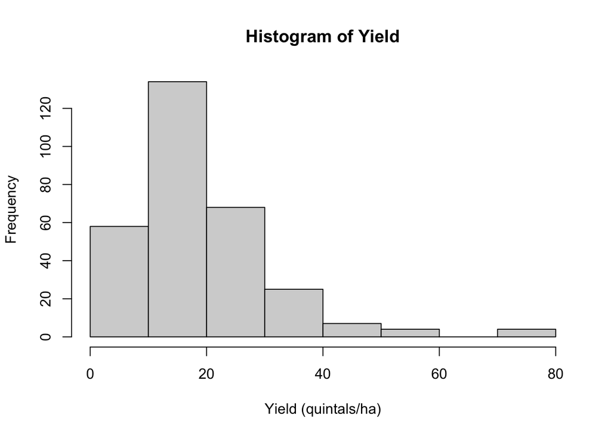

```r
hist(fossilfuel_2017.omit$nox_val, main="Histogram of Yield", xlab="Yield (quintals/ha)")
```

```r
#qqnorm(fossilfuel_2017.omit$nox_val, main="QQplot of NOx")
```

Data is non-parametric and gamma distributed.

```r
library(e1071)
skewness(fossilfuel_2017.omit$nox_val)
```

```
## [1] 2.102793
```

Based on the results of VIF correction we call the following model:

```r
summary(model_NOx_gamma.vif2 <- glm(data = fossilfuel_2017.omit, nox_val ~ X.people.per.sq.km + personal.buses.A.roads + personal.motorcycles.Motorways + personal.motorcycles.A.roads + personal.motorcycles.Minor.roads + freight.HGV.Motorways + freight.HGV.A.roads, family  = Gamma(link = "log")))
```

```
##
## Call:
## glm(formula = nox_val ~ X.people.per.sq.km + personal.buses.A.roads +
##     personal.motorcycles.Motorways + personal.motorcycles.A.roads +
##     personal.motorcycles.Minor.roads + freight.HGV.Motorways +
##     freight.HGV.A.roads, family = Gamma(link = "log"), data = fossilfuel_2017.omit)
##
## Deviance Residuals:
##      Min        1Q    Median        3Q       Max
## -1.59280  -0.26674  -0.01698   0.18419   1.98180
##
## Coefficients:
##                                    Estimate Std. Error t value Pr(>|t|)
## (Intercept)                       2.602e+00  5.001e-02  52.027  < 2e-16 ***
## X.people.per.sq.km                1.348e-04  1.385e-05   9.728  < 2e-16 ***
## personal.buses.A.roads            9.069e-05  3.532e-05   2.567  0.01074 *
## personal.motorcycles.Motorways    9.346e-04  4.574e-04   2.043  0.04194 *
## personal.motorcycles.A.roads     -5.913e-04  2.170e-04  -2.724  0.00684 **
## personal.motorcycles.Minor.roads  1.694e-04  2.384e-04   0.711  0.47788
## freight.HGV.Motorways             1.741e-06  2.679e-06   0.650  0.51623
## freight.HGV.A.roads              -7.974e-06  3.942e-06  -2.023  0.04400 *
## ---
## Signif. codes:  0 '***' 0.001 '**' 0.01 '*' 0.05 '.' 0.1 ' ' 1
##
## (Dispersion parameter for Gamma family taken to be 0.1591281)
##
##     Null deviance: 94.264  on 299  degrees of freedom
## Residual deviance: 43.137  on 292  degrees of freedom
## AIC: 1977
##
## Number of Fisher Scoring iterations: 7
```

```r
vif(model_NOx_gamma.vif2)
```

```
##               X.people.per.sq.km           personal.buses.A.roads
##                         2.601107                         4.589445
##   personal.motorcycles.Motorways     personal.motorcycles.A.roads
##                         2.483397                         3.520010
## personal.motorcycles.Minor.roads            freight.HGV.Motorways
##                         2.200378                         2.546692
##              freight.HGV.A.roads
##                         1.654252
```

Stepwise regression:

```r
### Define full and null models and do step procedure
model_NOx.0_glm.gamma <- glm(nox_val ~ 1, data = fossilfuel_2017.omit, family = Gamma(link = "log"))
step(model_NOx.0_glm.gamma, direction = "both", scope = formula(model_NOx_gamma.vif2, test = "Chisq"))
```

```
## Start:  AIC=2205.96
## nox_val ~ 1
##
##                                    Df Deviance    AIC
## + X.people.per.sq.km                1   49.659 2092.1
## + personal.buses.A.roads            1   64.744 2131.3
## + personal.motorcycles.A.roads      1   77.444 2164.3
## + personal.motorcycles.Minor.roads  1   83.395 2179.7
## + freight.HGV.A.roads               1   87.282 2189.8
## <none>                                  94.264 2206.0
## + freight.HGV.Motorways             1   93.943 2207.1
## + personal.motorcycles.Motorways    1   94.257 2207.9
##
## Step:  AIC=2008.29
## nox_val ~ X.people.per.sq.km
##
##                                    Df Deviance    AIC
## + personal.motorcycles.Motorways    1   46.721 1992.1
## + freight.HGV.Motorways             1   47.248 1995.3
## + freight.HGV.A.roads               1   48.659 2004.1
## + personal.buses.A.roads            1   48.876 2005.4
## + personal.motorcycles.Minor.roads  1   48.898 2005.6
## + personal.motorcycles.A.roads      1   49.267 2007.8
## <none>                                  49.659 2008.3
## - X.people.per.sq.km                1   94.264 2283.0
##
## Step:  AIC=1991.5
## nox_val ~ X.people.per.sq.km + personal.motorcycles.Motorways
##
##                                    Df Deviance    AIC
## + freight.HGV.A.roads               1   45.813 1987.7
## + personal.motorcycles.A.roads      1   46.006 1988.9
## + personal.buses.A.roads            1   46.322 1990.9
## <none>                                  46.721 1991.5
## + personal.motorcycles.Minor.roads  1   46.461 1991.8
## + freight.HGV.Motorways             1   46.531 1992.3
## - personal.motorcycles.Motorways    1   49.659 2008.4
## - X.people.per.sq.km                1   94.257 2295.9
##
## Step:  AIC=1987.47
```

[output cut: 25 more lines]

```
## - X.people.per.sq.km                1   56.042 2056.2
##
## Step:  AIC=1973.98
## nox_val ~ X.people.per.sq.km + personal.motorcycles.Motorways +
##     freight.HGV.A.roads + personal.buses.A.roads + personal.motorcycles.A.roads
##
##                                    Df Deviance    AIC
## <none>                                  43.280 1974.0
## - freight.HGV.A.roads               1   43.814 1975.3
## + personal.motorcycles.Minor.roads  1   43.205 1975.5
## + freight.HGV.Motorways             1   43.217 1975.6
## - personal.motorcycles.A.roads      1   44.729 1981.1
## - personal.buses.A.roads            1   45.622 1986.8
## - personal.motorcycles.Motorways    1   45.761 1987.7
## - X.people.per.sq.km                1   56.041 2052.6
```

```
##
## Call:  glm(formula = nox_val ~ X.people.per.sq.km + personal.motorcycles.Motorways +
##     freight.HGV.A.roads + personal.buses.A.roads + personal.motorcycles.A.roads,
##     family = Gamma(link = "log"), data = fossilfuel_2017.omit)
##
## Coefficients:
##                    (Intercept)              X.people.per.sq.km
##                      2.620e+00                       1.321e-04
## personal.motorcycles.Motorways             freight.HGV.A.roads
##                      1.191e-03                      -6.888e-06
##         personal.buses.A.roads    personal.motorcycles.A.roads
##                      1.098e-04                      -6.268e-04
##
## Degrees of Freedom: 299 Total (i.e. Null);  294 Residual
## Null Deviance:       94.26
## Residual Deviance: 43.28     AIC: 1974
```

Based on the results of the stepwise regression, we proceed to build our final model:

```r
### Define final model based on stepwise regression results
summary(model_NOx_gamma_final <- glm(formula = nox_val ~ X.people.per.sq.km + personal.motorcycles.Motorways +
    freight.HGV.A.roads + personal.buses.A.roads + personal.motorcycles.A.roads,
    family = Gamma(link = "log"), data = fossilfuel_2017.omit))
```

```
##
## Call:
## glm(formula = nox_val ~ X.people.per.sq.km + personal.motorcycles.Motorways +
##     freight.HGV.A.roads + personal.buses.A.roads + personal.motorcycles.A.roads,
##     family = Gamma(link = "log"), data = fossilfuel_2017.omit)
##
## Deviance Residuals:
##      Min        1Q    Median        3Q       Max
## -1.58647  -0.25701  -0.02948   0.18730   1.95719
##
## Coefficients:
##                                  Estimate Std. Error t value Pr(>|t|)
## (Intercept)                     2.620e+00  4.486e-02  58.409  < 2e-16 ***
## X.people.per.sq.km              1.321e-04  1.363e-05   9.687  < 2e-16 ***
## personal.motorcycles.Motorways  1.191e-03  2.993e-04   3.979 8.71e-05 ***
## freight.HGV.A.roads            -6.888e-06  3.741e-06  -1.841 0.066593 .
## personal.buses.A.roads          1.098e-04  2.938e-05   3.737 0.000224 ***
## personal.motorcycles.A.roads   -6.268e-04  2.128e-04  -2.946 0.003480 **
## ---
## Signif. codes:  0 '***' 0.001 '**' 0.01 '*' 0.05 '.' 0.1 ' ' 1
##
## (Dispersion parameter for Gamma family taken to be 0.1583252)
##
##     Null deviance: 94.264  on 299  degrees of freedom
## Residual deviance: 43.280  on 294  degrees of freedom
## AIC: 1974
##
## Number of Fisher Scoring iterations: 7
```

```r
# Drop freight.HGV.A.roads because not significant
summary(model_NOx_gamma_final <-glm(formula = nox_val ~ X.people.per.sq.km + personal.motorcycles.Motorways + personal.buses.A.roads + personal.motorcycles.A.roads,
    family = Gamma(link = "log"), data = fossilfuel_2017.omit))
```

```
##
## Call:
## glm(formula = nox_val ~ X.people.per.sq.km + personal.motorcycles.Motorways +
##     personal.buses.A.roads + personal.motorcycles.A.roads, family = Gamma(link = "log"),
##     data = fossilfuel_2017.omit)
##
## Deviance Residuals:
##      Min        1Q    Median        3Q       Max
## -1.60711  -0.26532  -0.02905   0.20043   2.07780
##
## Coefficients:
##                                  Estimate Std. Error t value Pr(>|t|)
## (Intercept)                     2.571e+00  3.820e-02  67.309  < 2e-16 ***
## X.people.per.sq.km              1.456e-04  1.203e-05  12.109  < 2e-16 ***
## personal.motorcycles.Motorways  1.244e-03  3.030e-04   4.106 5.22e-05 ***
## personal.buses.A.roads          1.062e-04  2.989e-05   3.552 0.000445 ***
## personal.motorcycles.A.roads   -7.651e-04  1.962e-04  -3.900 0.000119 ***
## ---
## Signif. codes:  0 '***' 0.001 '**' 0.01 '*' 0.05 '.' 0.1 ' ' 1
##
## (Dispersion parameter for Gamma family taken to be 0.1639815)
##
##     Null deviance: 94.264  on 299  degrees of freedom
## Residual deviance: 43.814  on 295  degrees of freedom
## AIC: 1975.7
##
## Number of Fisher Scoring iterations: 7
```

Our final NOx model indicates significant effects of same on-road vehicles reported for NO2. Let’s have a look at fossil fuel data from manufacturing and construction site using VIF-corrected predictors:

```r
summary(model_NOx_gamma.rsd.vif <- glm(data = fossilfuel_2017.omit, nox_val ~ X.people.per.sq.km + petroleum.Industrial + petroleum.Rail + petroleum.Public.Administration + petroleum.Commercial + petroleum.Agriculture + Manufactured.Solid.Fuels.Domestic + bioenergy, family  = Gamma(link = "log")))
```

```
##
## Call:
## glm(formula = nox_val ~ X.people.per.sq.km + petroleum.Industrial +
##     petroleum.Rail + petroleum.Public.Administration + petroleum.Commercial +
##     petroleum.Agriculture + Manufactured.Solid.Fuels.Domestic +
##     bioenergy, family = Gamma(link = "log"), data = fossilfuel_2017.omit)
##
## Deviance Residuals:
##      Min        1Q    Median        3Q       Max
## -1.54504  -0.24882  -0.04069   0.16589   1.46284
##
## Coefficients:
##                                     Estimate Std. Error t value Pr(>|t|)
## (Intercept)                        2.659e+00  3.725e-02  71.366  < 2e-16 ***
## X.people.per.sq.km                 1.091e-04  7.912e-06  13.788  < 2e-16 ***
## petroleum.Industrial              -2.831e-04  2.573e-04  -1.100 0.272067
## petroleum.Rail                     2.389e-02  1.103e-02   2.166 0.031148 *
## petroleum.Public.Administration   -1.453e-01  7.293e-02  -1.992 0.047269 *
## petroleum.Commercial               2.735e-01  9.362e-02   2.921 0.003757 **
## petroleum.Agriculture             -9.208e-02  8.062e-03 -11.422  < 2e-16 ***
## Manufactured.Solid.Fuels.Domestic  2.135e-01  5.971e-02   3.576 0.000408 ***
## bioenergy                         -1.185e-03  1.204e-03  -0.984 0.326053
## ---
## Signif. codes:  0 '***' 0.001 '**' 0.01 '*' 0.05 '.' 0.1 ' ' 1
##
## (Dispersion parameter for Gamma family taken to be 0.1115973)
##
##     Null deviance: 94.264  on 299  degrees of freedom
## Residual deviance: 32.422  on 291  degrees of freedom
## AIC: 1891.5
##
## Number of Fisher Scoring iterations: 8
```

```r
vif(model_NOx_gamma.rsd.vif) # no collinearity
```

```
##                X.people.per.sq.km              petroleum.Industrial
##                          1.209843                          1.040351
##                    petroleum.Rail   petroleum.Public.Administration
##                          1.580011                          1.104873
##              petroleum.Commercial             petroleum.Agriculture
##                          1.962510                          2.787182
## Manufactured.Solid.Fuels.Domestic                         bioenergy
##                          2.650664                          1.096700
```

Stepwise regression:

```r
### Define full and null models and do step procedure
model_NOx.0_glm.gamma <- glm(nox_val ~ 1, data = fossilfuel_2017.omit, family = Gamma(link = "log"))
step(model_NOx.0_glm.gamma, direction = "both", scope = formula(model_NOx_gamma.rsd.vif, test = "Chisq"))
```

```
## Start:  AIC=2205.96
## nox_val ~ 1
```

```
##                                     Df Deviance    AIC
## + X.people.per.sq.km                 1   49.659 2092.1
## + petroleum.Agriculture              1   64.933 2131.8
## + Manufactured.Solid.Fuels.Domestic  1   85.988 2186.5
## + petroleum.Rail                     1   90.872 2199.1
## + bioenergy                          1   91.400 2200.5
## + petroleum.Industrial               1   92.957 2204.6
## <none>                                   94.264 2206.0
## + petroleum.Public.Administration    1   93.824 2206.8
## + petroleum.Commercial               1   94.154 2207.7
##
## Step:  AIC=2008.29
## nox_val ~ X.people.per.sq.km
##
##                                     Df Deviance    AIC
## + petroleum.Agriculture              1   37.616 1935.6
## + Manufactured.Solid.Fuels.Domestic  1   48.458 2002.8
## + petroleum.Commercial               1   48.478 2003.0
## + bioenergy                          1   49.012 2006.3
## + petroleum.Public.Administration    1   49.169 2007.2
## <none>                                   49.659 2008.3
## + petroleum.Industrial               1   49.460 2009.0
## + petroleum.Rail                     1   49.572 2009.8
## - X.people.per.sq.km                 1   94.264 2283.0
##
## Step:  AIC=1924.96
## nox_val ~ X.people.per.sq.km + petroleum.Agriculture
```

```
##                                     Df Deviance    AIC
## + Manufactured.Solid.Fuels.Domestic  1   34.462 1902.7
## + petroleum.Commercial               1   35.569 1911.2
## + petroleum.Rail                     1   35.895 1913.7
## <none>                                   37.616 1925.0
## + petroleum.Public.Administration    1   37.588 1926.8
## + petroleum.Industrial               1   37.603 1926.9
## + bioenergy                          1   37.613 1926.9
## - petroleum.Agriculture              1   49.659 2015.7
## - X.people.per.sq.km                 1   64.933 2133.4
##
## Step:  AIC=1900.16
## nox_val ~ X.people.per.sq.km + petroleum.Agriculture + Manufactured.Solid.Fuels.Domestic
##
##                                     Df Deviance    AIC
## + petroleum.Commercial               1   33.458 1894.1
## + petroleum.Rail                     1   33.964 1898.2
## <none>                                   34.462 1900.2
## + bioenergy                          1   34.290 1900.8
## + petroleum.Public.Administration    1   34.321 1901.0
## + petroleum.Industrial               1   34.389 1901.6
## - Manufactured.Solid.Fuels.Domestic  1   37.616 1923.4
## - petroleum.Agriculture              1   48.458 2010.1
## - X.people.per.sq.km                 1   62.350 2121.2
##
## Step:  AIC=1893.12
## nox_val ~ X.people.per.sq.km + petroleum.Agriculture + Manufactured.Solid.Fuels.Domestic +
##     petroleum.Commercial
##
##                                     Df Deviance    AIC
## + petroleum.Rail                     1   33.089 1891.9
## + petroleum.Public.Administration    1   33.184 1892.7
## <none>                                   33.458 1893.1
## + bioenergy                          1   33.331 1894.0
## + petroleum.Industrial               1   33.359 1894.3
## - petroleum.Commercial               1   34.462 1899.9
## - Manufactured.Solid.Fuels.Domestic  1   35.569 1909.6
## - petroleum.Agriculture              1   48.031 2018.5
## - X.people.per.sq.km                 1   56.781 2094.9
##
```

[output cut: 14 more lines]

```
##
## Step:  AIC=1889.92
## nox_val ~ X.people.per.sq.km + petroleum.Agriculture + Manufactured.Solid.Fuels.Domestic +
##     petroleum.Commercial + petroleum.Rail + petroleum.Public.Administration
##
##                                     Df Deviance    AIC
## <none>                                   32.677 1889.9
## + petroleum.Industrial               1   32.522 1890.5
## + bioenergy                          1   32.556 1890.8
## - petroleum.Public.Administration    1   33.089 1891.6
## - petroleum.Rail                     1   33.184 1892.4
## - petroleum.Commercial               1   33.692 1897.0
## - Manufactured.Solid.Fuels.Domestic  1   34.022 1899.9
## - petroleum.Agriculture              1   47.597 2020.8
## - X.people.per.sq.km                 1   56.461 2099.8
```

```
##
## Call:  glm(formula = nox_val ~ X.people.per.sq.km + petroleum.Agriculture +
##     Manufactured.Solid.Fuels.Domestic + petroleum.Commercial +
##     petroleum.Rail + petroleum.Public.Administration, family = Gamma(link = "log"),
##     data = fossilfuel_2017.omit)
##
## Coefficients:
##                       (Intercept)                 X.people.per.sq.km
##                         2.6513472                          0.0001099
##             petroleum.Agriculture  Manufactured.Solid.Fuels.Domestic
##                        -0.0922126                          0.2012087
##              petroleum.Commercial                     petroleum.Rail
##                         0.2748911                          0.0229789
##   petroleum.Public.Administration
##                        -0.1416225
##
## Degrees of Freedom: 299 Total (i.e. Null);  293 Residual
## Null Deviance:       94.26
## Residual Deviance: 32.68     AIC: 1890
```

Based on the results of the stepwise regression on the original VIF-corrected model, we build our final model:

```r
### Define final model based on stepwise regression results
summary(model_NOx_gamma.final.rsd <- glm(formula = nox_val ~ X.people.per.sq.km + petroleum.Agriculture +
    Manufactured.Solid.Fuels.Domestic + petroleum.Commercial +
    petroleum.Rail + petroleum.Public.Administration, family = Gamma(link = "log"),
    data = fossilfuel_2017.omit))
```

```
##
## Call:
## glm(formula = nox_val ~ X.people.per.sq.km + petroleum.Agriculture +
##     Manufactured.Solid.Fuels.Domestic + petroleum.Commercial +
##     petroleum.Rail + petroleum.Public.Administration, family = Gamma(link = "log"),
##     data = fossilfuel_2017.omit)
##
## Deviance Residuals:
##     Min       1Q   Median       3Q      Max
## -1.5454  -0.2522  -0.0370   0.1679   1.4670
##
## Coefficients:
##                                     Estimate Std. Error t value Pr(>|t|)
## (Intercept)                        2.651e+00  3.700e-02  71.649  < 2e-16 ***
## X.people.per.sq.km                 1.099e-04  7.921e-06  13.872  < 2e-16 ***
## petroleum.Agriculture             -9.221e-02  8.045e-03 -11.462  < 2e-16 ***
## Manufactured.Solid.Fuels.Domestic  2.012e-01  5.920e-02   3.399 0.000771 ***
## petroleum.Commercial               2.749e-01  9.350e-02   2.940 0.003542 **
## petroleum.Rail                     2.298e-02  1.103e-02   2.084 0.038029 *
## petroleum.Public.Administration   -1.416e-01  7.305e-02  -1.939 0.053496 .
## ---
## Signif. codes:  0 '***' 0.001 '**' 0.01 '*' 0.05 '.' 0.1 ' ' 1
##
## (Dispersion parameter for Gamma family taken to be 0.1122551)
##
##     Null deviance: 94.264  on 299  degrees of freedom
## Residual deviance: 32.677  on 293  degrees of freedom
## AIC: 1889.9
##
## Number of Fisher Scoring iterations: 8
```